# CCS 消融实验：表示性能

Bensz Conan

2026-10-08

本报告比较同一批样本的 Direct-GSClassifier 特征与 CCS 对象中**已经计算好的 d1 概率表示**。可以把 Direct 想成一份保留原始线索的详细笔记：每个基因及基因对特征仍可单独查看；d1 则像让 150 位熟悉不同队列的评委阅读同一份笔记，保存他们各自给出的概率判断。新样本的 cohort 名称不作为这些模型的输入标签，d1 也不是要把样本硬塞回某个已知队列。本次分析没有重新训练 cohort 模型或重新预测原始 d1。

这项消融首先问**重编码改变了什么**，再问改变是否符合跨癌种表示的目的。癌种标签能否找回，是检查重要生物差异有没有被过度模糊的一把尺子，却不是 d1 的总成绩；平台和来源是否仍把邻居拉到一起，是另一把尺子；连续表达状态与跨队列结构则补充检查生物关系。若冻结模型只读取同一份 Direct 特征，d1 不会凭空增加单个样本的信息，但可能把已有线索组织得更适合多队列比较。要证明“更适合”，还需要在预先选定的独立跨癌种任务上看到可迁移的收益。

本次修订统一了 readout 的训练/测试尺度，扩展gene signature 分数评估到全部候选 query，并核验本模块的输入与结果指纹。下文按“数据范围—空间改写—旧癌种标签—队列证据与技术来源—可恢复信息”阅读，每一层只回答它实际测到的问题。

当前证据等级为 descriptive。reference d1 来源为 in_sample，query d1 来源为 external_frozen。由于 reference 表示包含 in-sample 生成路径，而 query 使用冻结外部预测，两侧来源不对称；因此本报告只作描述性外部评价，不把检索库或 readout 结果标为确认性证据。

## 1 数据概览

本次 reference 有 24487 个样本、147 个队列；external candidates 有 14060 个样本、43 个队列。癌种 readout 的可估计子集为 5705 个样本、17 个队列。**gene signature 分数的候选范围不再由癌种支持门槛决定**；最终有效范围还取决于表达覆盖和成对 top-15 分数是否完整。

```r
# Purpose: Expose the exact data and representation contract used by all analyses.
# Input: manifest.rds.
# Parameters: Twelve visible rows; horizontal scrolling retained for audit fields.
# Output: Interactive data overview table.
overview_table <- data.frame(
  item = c(
    "Evidence level",
    "Evidence limitation",
    "Reference samples",
    "External query samples",
    "Reference cohorts",
    "External filtered cohorts",
    "Direct features",
    "Gene signature size",
    "Ordinary gene-pairs",
    "d1 modules",
    "d1 output columns",
    "Direct / d1 distance"
  ),
  value = c(
    manifest$evidence_level,
    paste(manifest$evidence_reasons, collapse = "; "),
    manifest$reference_sample_count,
    manifest$query_sample_count,
    manifest$reference_cohort_count,
    manifest$query_cohort_count,
    manifest$direct_feature_count,
    manifest$gene_signature_count,
    manifest$tsp_feature_count,
    manifest$module_count,
    manifest$d1_feature_count,
    paste(manifest$direct_distance, manifest$d1_distance, sep = " / ")
  ),
  stringsAsFactors = FALSE
)
render_dt(overview_table, pageLength = 12)
```

|  | item | value |
| --- | --- | --- |
| 1 | Evidence level | descriptive |
| 2 | Evidence limitation | reference_d1_provenance_is_not_external_or_out_of_fold |
| 3 | Reference samples | 24487 |
| 4 | External query samples | 5705 |
| 5 | Reference cohorts | 147 |
| 6 | External filtered cohorts | 17 |
| 7 | Direct features | 529 |
| 8 | Gene signature size | 32 |
| 9 | Ordinary gene-pairs | 496 |
| 10 | d1 modules | 150 |

[output cut: 2 more lines]

解读：这张表固定样本身份，只改变每个样本的坐标表示：Direct 有 529 个输入特征，d1 有 583 个模块输出列，列数差不能当作信息量或性能差。reference 包含 24487 个样本、147 个队列；外部候选有 14060 个样本、43 个队列，其中旧癌种任务实际可估计 5705 个样本、17 个队列。这个收缩来自癌种及 reference 支持资格，不表示其他候选样本在连续 gene signature 分数上都不可用。后续若比较两臂差值，必须在同一 query 身份和同一终点资格内配对，不能拿不同总体的汇总值相减。

## 2 关键函数、参数与源代码位置

| 过程 | 函数与关键参数 | 本次约定 | 源代码 |
| --- | --- | --- | --- |
| Direct 与 d1 输入 | `.ablation_prepare_representation_input()` | 由 01.02.00. 表示输入准备.R 准备冻结 Direct 特征和已有 d1；分析只读取缓存 | `R/ablation.R` |
| 癌种检索 | `.ablation_query_reference_retrieval()`；k=30 | 仅使用癌种可估计 query，排除同队列邻居 | `R/ablation.R` |
| 癌种 readout | `.ablation_linear_readout()`；3 折 grouped CV | 两臂均传入原始表示；每个训练折与最终模型各自拟合一次尺度 | `R/ablation.R` |
| 来源一致性 | `.ae_validate_stage_receipt()` | 渲染前验证表示分析及其准备阶段的源代码与产物指纹，变化时停止 | 02.01.00. 表示分析_functions.R |

## 3 指标导读

| 指标 | 输入与计算 | 数值怎样读 | 本报告的用途与边界 |
| --- | --- | --- | --- |
| Linear CKA | 同一批 reference 样本在两种表示中的中心化样本关系矩阵；下节推导公式 | 0–1；越高表示整体关系图越相似；区间量化队列组成敏感性 | 检查整体几何是否重排，不是保留生物信息的百分比 |
| 距离 Spearman | 对抽到的同一组样本对分别计算两臂距离，再比较距离名次 | −1 至 1；1 表示排序完全一致；区间量化队列组成敏感性 | 检查远近排序；不比较绝对距离大小 |
| kNN Jaccard | 每个样本的两份近邻名单取交集人数／并集人数，再对样本平均 | 0–1；越高表示具体邻居越重合；区间只量化固定完整 atlas 下的 query cohort 组成 | 补充局部变化；数值不是邻居重合的直接百分比 |
| Top-k label rate、MRR@k | 前 $k$ 名同癌种邻居比例；首次同癌种命中的倒数排名，$k$ 名外记零 | 0–1；越高越容易从邻居找回旧癌种；两臂差以零为参照 | 保护性旧标签任务，不等于新亚型发现能力 |
| Cohort accuracy、pooled balanced accuracy | 分别对外部队列准确率等权平均、对合并样本中各癌种召回率等权平均 | 0–1；越高表示旧癌种越可读；两种权重不相同 | 查旧癌种信息是否受损，不能用一项替换另一项 |
| Technical excess | 同技术标签近邻比例减同癌种、其它队列 reference 的背景比例 | 零表示与背景相同，正值表示更易按技术标签聚集 | 两臂差中的共同背景会抵消，不能单独证明技术噪声被选择性移除 |
| 模块原始方差份额 | 模块内各列样本方差取平均，再除以全 bank 同类统计量之和 | 0–1；越高表示原始输出波动较大；等份参照为 $1/M$ | 诊断原始 d1 尺度；没有模块份额的 CI，不是最终距离或任务贡献 |
| Figure S3 cohort Gain | 辅助 XGBoost 用 d1 重建一个 d3 坐标，按 cohort 汇总归一化分裂 Gain；merge 对两坐标等权平均 | 0–1；越高表示该辅助模型归给该 cohort 的相对分裂增益较多 | 历史结果用于解释指标差异；没有本次重采样区间，不是解释方差、临床获益或因果贡献 |
| d1−Direct | 在相同 query／设计上先配对相减，再按各终点的单位汇总 | 零表示该指标两臂相同；正负仅表示指标数值方向 | 先看终点定义再判断得失，不能把不同指标差值相加 |
| 95% CI 与校正 P 值 | 主终点按完整 cohort 重采样；检验在各自预设指标族内校正 | 区间跨零意味着当前数据兼容两种效应方向 | 几何单次估计及唯一训练设计没有可解释的 CI／P；跨零不证明等价 |

癌种 readout、retrieval、technical excess 的主要效应均以外部 query cohort 为单位，先算每队列的 d1−Direct 差，再对队列等权平均。区间采用 2000 次 cohort bootstrap 的百分位区间。双侧 sign-flip 检验在队列数不超过 18 时枚举全部符号组合，P 值直接取尾部比例；更多队列时使用 Monte Carlo，并按“尾部次数加一／模拟次数加一”校正。该检验依赖零假设下差值符号可交换的假设，不能替代随机实验。癌种指标和技术字段在各自检验族内使用 Holm 校正，具体采用的方法见表中 `p_method`。

学习曲线和 bank scaling 的重复单位是训练或模块设计，固定了当前 query 人群；它们的区间描述设计敏感性。gene signature 评估与状态关系一致性结果分别见同目录的 02.02.00. 生物锚点分析、02.03.00. 生物状态关系的跨队列一致性 报告。

## 4 d1 与癌种标签的判读边界

对同一个新样本，Direct 直接呈现输入特征；d1 汇集冻结队列模型对这些特征的判断。若把“能否立即认出原来的癌种”当成唯一考试，擅长保留原始细节的 Direct 本来就有优势。d1 的研究问题更具体：重新组织多队列证据后，是否减弱与技术来源捆绑的捷径，同时保留可跨队列重现的生物关系，并让有用的癌种内与跨癌种状态都能表达出来。

因此，旧癌种标签恢复率下降有两种尚待区分的解释：d1 可能淡化了妨碍泛癌比较的来源或旧标签边界，也可能丢掉了重要的癌种生物信息。二者会在同一张检索图上表现为负差。癌种分类在这里是**保护性参照**：提醒我们检查损失，却不能单独证明 d1 成功或失败；真正的下游价值需要独立 pathway、微环境、治疗反应或结局任务，以及未见队列上的稳定性来判断。

把“批次效应”拆开看会更清楚：

| 可能让样本抱团的标签 | 本轮怎样检查 | 当前能回答的问题 |
| --- | --- | --- |
| 原 cohort | 检索时排除同 cohort 的 reference 样本 | 避免同队列自我匹配，却不能据此声称 d1 已消除同 cohort 效应 |
| 癌种 | 比较跨 cohort 同癌种检索和线性 readout | 看旧癌种差异保留多少；下降既可能是去掉旧边界，也可能是生物信息损失 |
| 检测方式、平台、数据来源 | 比较跨 cohort 邻居中同技术标签的比例 | 负差表示这类标签的邻居聚集较少；仍需在相同癌种和候选池内复核，才能更明确地区分技术因素与癌种组成 |

## 5 d1 对原生空间的改写

这里的“改写”指同一批样本从 Direct 特征转成 d1 模块概率后，**样本彼此的相似关系**改变了多少；它不要求逐列恢复原始特征。本节只比较冻结 reference 中的 5000 个样本，不是对未见队列的外部验证。为让不同特征有可比较的距离，Direct 各列先按 reference 均值和标准差标准化；d1 各列也按 reference 标准化，再对每个模块整体加权，避免列数较多的模块仅凭维度占据更大距离权重。因此“原生空间”是两种表示各自的**分析坐标**，不是未经处理的原始数值，也没有经过 PCA 或 UMAP 压缩。

### 5.1 从样本关系矩阵推到 Linear CKA

设 $n$ 个相同样本组成 Direct 矩阵 $X\in\mathbb R^{n\times p}$ 和 d1 矩阵 $Y\in\mathbb R^{n\times q}$：行顺序对应同一个样本，$p$ 与 $q$ 可以不同。先将每列减去该列在这 $n$ 个样本中的均值，得到 $X_c$、$Y_c$。两张样本关系矩阵为 $K=X_cX_c^\top$、$L=Y_cY_c^\top$；例如 $K_{ij}$ 是样本 $i$、$j$ 在 Direct 中的中心化内积。无论特征数是 $p$ 还是 $q$，$K$ 与 $L$ 都是 $n\times n$，因此可以比较同一对样本在两种表示下的关系。

把矩阵的所有对应元素相乘后求和记为 Frobenius 内积 $\langle K,L\rangle_F$，把所有元素平方和的平方根记为 Frobenius 范数 $\|K\|_F$。Linear CKA 先比较两张关系矩阵的方向，再用各自范数消除整体数值尺度：

$$\operatorname{CKA}(X,Y)=\frac{\langle K,L\rangle_F}{\|K\|_F\,\|L\|_F}.$$

报告和代码中的交叉乘积形式来自矩阵迹的循环性质，而不是另加一种评分：

$$\begin{aligned}
\langle K,L\rangle_F
&=\operatorname{tr}(KL)
=\operatorname{tr}(X_cX_c^\top Y_cY_c^\top)\\
&=\operatorname{tr}(X_c^\top Y_cY_c^\top X_c)
=\|X_c^\top Y_c\|_F^2,\\
\|K\|_F&=\|X_c^\top X_c\|_F,\qquad
\|L\|_F=\|Y_c^\top Y_c\|_F.
\end{aligned}$$

所以 $\operatorname{CKA}(X,Y)=\|X_c^\top Y_c\|_F^2/(\|X_c^\top X_c\|_F\,\|Y_c^\top Y_c\|_F)$。值越接近 1，整张样本关系图越相似；它不是“保留了多少百分比的生物信息”，也不要求两套坐标轴名称或数量相同。

### 5.2 距离顺序与近邻名单

CKA 看整体内积关系，但整体相似仍可能伴随个别样本换邻居。因此再抽取 100,000 个不同样本组成的样本对，分别在 Direct 和 d1 分析坐标中算欧氏距离，然后对两组**距离名次**求 Spearman 相关。值接近 1 表示“哪些样本对较近、哪些较远”的排序相近；例如相关为 0.67，不能读成保留 67% 的绝对距离。抽样按固定种子进行，样本对有放回抽取，可能重复。

最后，对每个样本 $i$ 分别找两种表示下的前 30 个最近邻（$k$ 取这个值），记作 $N_X(i)$、$N_Y(i)$，计算

$$J_i=\frac{|N_X(i)\cap N_Y(i)|}{|N_X(i)\cup N_Y(i)|},\qquad
\overline J=\frac{1}{n}\sum_{i=1}^{n}J_i.$$

例如两份各有 5 人的名单重合 3 人，则并集有 7 人，Jaccard 是 $3/7$，不是 $3/5$。报告给出的是样本平均 $\overline J$；它不能直接读成“有 $\overline J\times100\%$ 的邻居相同”。这三个指标依次回答整体关系、远近排序和具体近邻，观察尺度不同，数值也不能当成同一种百分比横向比较。

```r
# ==== Figure 1: Native geometry agreement (user-adjustable parameters) ====
fig1 <- list(
  # Canvas size in inches. Wider canvases leave room for metric labels.
  width_in = 6.2,
  height_in = 3.8,
  # Base font in pt. Values below 8 are avoided for print readability.
  base_size = 12,
  # Bar width and legend position; no in-panel title is used.
  bar_width = 0.68,
  legend_position = "none"
)

p1 <- ggplot2::ggplot(
  geometry_metrics,
  ggplot2::aes(x = .data$metric_label, y = .data$metric_value)
) +
  ggplot2::geom_col(
    width = fig1$bar_width,
    fill = nature_colors[["blue"]]
  ) +
  ggplot2::geom_text(
    ggplot2::aes(label = sprintf("%.3f", .data$metric_value)),
    vjust = -0.45,
    size = 3.6
  ) +
  ggplot2::scale_y_continuous(
    limits = c(0, 1.05),
    breaks = seq(0, 1, 0.2),
    expand = ggplot2::expansion(mult = c(0, 0.02))
  ) +
  ggplot2::labs(
    x = NULL,
    y = "Agreement"
  ) +
  theme_nature_readable(
    base_size = fig1$base_size,
    x_text_angle = 0,
    legend_position = fig1$legend_position
  )

# Readability check: three short labels fit without rotation; values are printed
# above bars. Inference details remain in the report text and table.
fig1_jpg <- .ae_save_plot(
  p1, "02.01.00. native-geometry", figure_dir, preview_dir, fig1,
  params$plot_preview_dpi
)
```

```
## Converting page 1 to D:/cache/ccs/_ablation-03/logs/report-previews/02.01.00-representation-20261008205707/02.01.00. native-geometry.jpg... done!
```

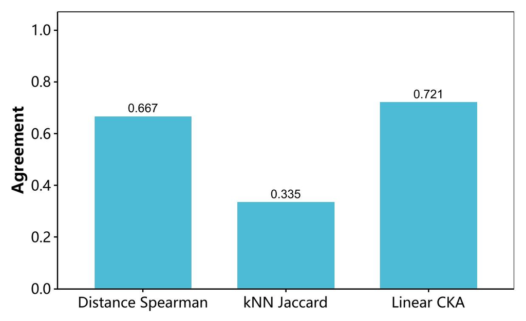

```r
knitr::include_graphics(fig1_jpg)
```

解读：在同一批 5000 个 reference 样本上，CKA 为 0.721，说明整体样本关系矩阵仍有相似结构；距离 Spearman 为 0.667，说明抽样样本对的远近顺序也有一定一致性。前 30 名近邻的平均 Jaccard 为 0.335，表示局部名单并未完全沿用 Direct。三个数的定义不同，不能比较柱高并把它们说成三种“保留率”；联合起来只能描述大尺度关系尚有延续、局部邻居出现重排。新邻居是否更符合生物状态，仍需用后面的外部癌种检索、技术标签和预设 gene signature 逐项核对；这些 gene signature 与模型输入同源，几何变化本身也不标记好坏。

```r
geometry_inference_table <- geometry_inference[, c(
  "endpoint", "estimate", "ci_low", "ci_high", "p_value", "n_cohort",
  "n_sample", "resamples", "valid_resamples", "seed", "unit", "method",
  "condition",
  "status", "reason"
)]
render_dt(geometry_inference_table, pageLength = 3L)
```

|  | endpoint | estimate | ci_low | ci_high | p_value | n_cohort | n_sample | resamples | valid_resamples | seed | unit | method | condition | status | reason |
| --- | --- | --- | --- | --- | --- | --- | --- | --- | --- | --- | --- | --- | --- | --- | --- |
| 1 | linear_cka | 0.7211347227060824 | 0.7012175386824775 | 0.7468915629629354 |  | 147 | 5000 | 200 | 200 | 20260925 | reference_cohort | cohort_percentile_bootstrap | frozen_model_and_reference_atlas_fixed_pairs | estimable |  |
| 2 | distance_spearman | 0.6669794284963206 | 0.6415462875476533 | 0.6996552983723605 |  | 147 | 5000 | 200 | 200 | 20260925 | reference_cohort | cohort_percentile_bootstrap | frozen_model_and_reference_atlas_fixed_pairs | estimable |  |
| 3 | knn_jaccard | 0.334874872482664 | 0.3132237287401661 | 0.3547403581112647 |  | 147 | 5000 | 200 | 200 | 20260925 | reference_cohort | query_cohort_percentile_bootstrap | frozen_model_and_complete_reference_neighbor_graph | estimable |  |

解读：表中有 3 行，分别对应 CKA、距离排序和近邻重合。点估计来自同一批 5000 个 reference 样本及一次冻结表示。CKA 与距离 Spearman 的 95% 区间按 147 个 reference cohort 整组有放回重采样；距离 Spearman 固定样本对，再按两端队列抽中次数加权。这两项量化现有 atlas 的队列组成敏感性。kNN Jaccard 的区间固定完整 reference 近邻图，只对每个患者的近邻名单重合度按 query cohort 整组重采样；它量化当前 atlas 下 query 队列组成变化，不能解释为更换近邻候选库后的性能区间。三项区间都以冻结模型为条件，不是未见队列或重新训练模型的验证；没有预设的自然零假设，故 P 值保持 NA。

## 6 已有癌种标签的外部评估

这一节围绕同一个问题展开：**将 Direct 换成 d1 后，已有癌种标签对应的局部关系和预测能力保留得怎样？** 下面依次检查外部 query 的同癌种近邻、线性分类器能否读出标签，以及减少训练队列后读出表现怎样变化，最后汇总各项效应量与不确定性。

检索、线性 readout 和训练队列学习曲线都使用本次可估计的外部 query，以已有癌种标签检查 d1 相对 Direct 保留了什么。它们共享标签和样本，因此是同一问题的三个观察角度，不能算作三次独立的生物学验证。三项分别检查局部邻居关系、监督可读性和训练队列资源依赖。

| 分析 | 独有的问题 | 为什么需要它 |
| --- | --- | --- |
| 外部癌种标签检索 | 不拟合癌种分类器，在固定 reference atlas 中按距离找邻居；同癌种样本是否仍靠近外部 query？ | 直接检查旧标签对应的**局部邻居关系**。即使监督分类器能认对癌种，也可能掩盖同癌种近邻已被重排；readout 分数不能替代这一检查。 |
| 外部癌种线性 readout | 用 reference 的旧癌种标签训练受限线性读出层，再预测未参与拟合的外部 query；分布在表示各列中的信息能否被读出？ | 检查**可读出性**。近邻检索较弱时，旧标签仍可能以需要汇总多个特征的形式存在；只看邻居不能判断这一点。 |
| 训练队列学习曲线 | 固定外部 query 和 readout 方法，逐步改变用于训练的 **reference cohort 数量**；较少训练队列时，两种表示各能读出多少旧癌种信息？ | 检查**训练资源敏感性**。完整 reference readout 只给出训练资源充足时的一个终点，无法说明结果在训练队列较少时怎样变化。这里的资源单位是 cohort，不是患者人数。 |

前两项的主要差值按外部 query cohort 等权汇总，学习曲线则在固定 query 人群上比较不同训练 cohort 设计；三者的分数、区间和 P 值不能直接相加或互借。若它们方向一致，只能更具体地描述旧癌种标签如何变化；若方向不同，先检查局部距离、监督读出和训练队列组成的差别。无论哪种情况，都还需要独立的癌种内或跨癌种生物终点，才能判断这种变化是否有益于新的个性化分型。

### 6.1 外部癌种标签检索：局部邻居关系

这项检索可以理解为：拿一个来自外部队列的样本，在冻结的 reference atlas 中找输入线索最相近的样本，再看邻居是否属于同一旧癌种。它检查**跨队列能否找回已有癌种标签**，不训练新的癌种分类器，也不把 query 的癌种名称交给近邻搜索。癌种标签只在找到邻居后用于计分；因此分数较高表示当前空间更容易按旧癌种聚在一起，并不等于新亚型更好。

#### 6.1.1 哪些样本参加，怎样找邻居

外部候选先经过癌种支持门槛：一个 query cohort 的癌种必须出现在至少 2 个**不同 reference cohort** 中，才进入本节检索。门槛按队列数计算，不是同癌种 reference 样本数；未达门槛的外部候选仍可参加不要求癌种标签的分析。本节实际使用 5705 个 query、17 个外部队列，reference atlas 有 24487 个样本。每位 query 都排除与自己同 cohort 的 reference 样本，防止同队列来源让检索显得过于容易；这也意味着同癌种但**其它队列**的样本仍可成为正确邻居。

同一个 query 分别用 Direct 和 d1 搜索**同一批有资格的 reference 样本**，两边都取前 30 名。Direct 每列按 reference 的均值和标准差标准化；d1 也按 reference 标准化，再给每个冻结 cohort 模块相同的总距离权重。query 沿用各自的 reference 变换，不单独重新定标。近邻按变换后空间的欧氏距离排序；本次搜索方法为 annoy。这是近似搜索：在抽取的 30 个 query 上，与精确搜索相比，前 30 位邻居名单的平均召回率为 Direct 0.973、d1 0.992；它衡量搜索近似程度，不是癌种检索分数。距离只决定各自空间中的排名，不把 Direct 和 d1 的距离数值直接相减。两臂的 query 身份、癌种标签和可选 reference 池一致，因此后续差值比较的是**换表示后邻居名单及排序的变化**。

#### 6.1.2 两项分数怎样读

对一位 query $q$，记前 $k$ 位邻居为 $\mathcal N_k(q)$，癌种标签为 $c$。Top-k 同癌种比例为 $\mathrm{TopKRate}_q=k^{-1}\sum_{j\in\mathcal N_k(q)}\mathbf 1(c_j=c_q)$，取值 0–1；例如前 5 位有 3 位同癌种，分数就是 $3/5=0.6$。它只数**命中多少位**，不区分这 3 位排在前面还是后面。本次主要展示前 30 位；例子用 5 位只是为了便于手算。

`MRR@k` 则看**第一次**同癌种命中。若首位命中排在 $r_q\leq k$，该 query 得 $1/r_q$；前 $k$ 位均未命中则得 0。例如前 5 位依次为“异、异、同、同、同”，Top-k 仍是 $3/5$，`MRR@5` 是 $1/3$；若第一位就是“同”，`MRR@5` 变成 1。两项分数都越高越容易找回旧癌种，但 MRR 差不能直接换算成“平均名次晚了几名”。结果表还列出 top-1 命中率，即只看第一位是否同癌种；它与 MRR、Top-k 同属本次检索指标族。

两臂先在**同一个 query** 上相减：$\Delta_q=\mathrm{score}_{q,\mathrm{d1}}-\mathrm{score}_{q,\mathrm{Direct}}$。再对每个外部 cohort 内的 $\Delta_q$ 求均值，最后对 cohort 均值等权平均；这样一个有数百位 query 的队列不会仅因人数多就决定总体方向。Top-k 差为 $-0.03$ 表示平均少约 3 **个百分点**的同癌种邻居比例，不是下降 3%，也不意味着每位患者都少一个邻居。推断区间通过整队列重采样得到，描述当前队列间的变动；不能把同一队列内几千位 query 当作几千个独立外部验证。

```r
retrieval_inference_table <- retrieval_inference[, c(
  "endpoint", "estimate", "ci_low", "ci_high", "p_value", "p_value_adj",
  "n_cohort", "n_sample", "resamples", "p_resamples", "p_method", "unit",
  "multiplicity_method", "status"
)]
render_dt(retrieval_inference_table, pageLength = 3L)
```

|  | endpoint | estimate | ci_low | ci_high | p_value | p_value_adj | n_cohort | n_sample | resamples | p_resamples | p_method | unit | multiplicity_method | status |
| --- | --- | --- | --- | --- | --- | --- | --- | --- | --- | --- | --- | --- | --- | --- |
| 1 | top_k_label_rate | -0.032429066130854 | -0.07748450305963483 | 0.005362798171394316 | 0.161651611328125 | 0.161651611328125 | 17 | 5705 | 2000 | 131072 | exact_paired_sign_flip | cohort | holm | complete |
| 2 | mrr | -0.05332221316220616 | -0.09400670274341093 | -0.009488473629295143 | 0.0281219482421875 | 0.056243896484375 | 17 | 5705 | 2000 | 131072 | exact_paired_sign_flip | cohort | holm | complete |
| 3 | top1_label_match | -0.06797409146728929 | -0.1129306144491402 | -0.0277849569055661 | 0.004638671875 | 0.013916015625 | 17 | 5705 | 2000 | 131072 | exact_paired_sign_flip | cohort | holm | complete |

解读：在 17 个外部队列中，Top-30 同癌种比例的 cohort 等权差为 -0.032，即 d1 比 Direct 平均低约 3.243 个百分点；其 95% cohort bootstrap 区间为 [-0.077, 0.005]。MRR@30 的等权差为 -0.053，区间为 [-0.094, -0.009]。本次两个负向点估计分别指向“前 30 位同癌种邻居比例较低”和“首次同癌种命中倾向排得更后或根本未命中”。Top-k 的区间 跨过零，不能据此排除两种方向；MRR 的区间 未跨过零。表中的 `p_value_adj` 是对 Top-k、MRR 和 top-1 **三个检索终点一起做 Holm 校正**后的值；当前 Top-k 为 0.162，MRR 为 0.056。这两项校正 P 值 均未低于 0.05；MRR 的未校正区间虽未跨零，也不应称为通过了三终点校正后的显著结果。这里的下降仍不能区分被弱化的是平台捆绑的旧癌种边界，还是可迁移的癌种生物关系；需与后面的技术标签、gene signature 和独立下游任务合看。

```r
# ==== Figure 2: External retrieval cohort deltas (user-adjustable parameters) ====
fig2 <- list(
  # Larger height protects cohort labels from overlap; adjust with cohort count.
  width_in = 8.0,
  height_in = 8.5,
  base_size = 11,
  point_size = 2.2,
  zero_line_width = 0.55,
  legend_position = "bottom"
)
plot_retrieval <- retrieval_cohort_delta[
  retrieval_cohort_delta$sample_count >= params$min_cohort_n &
    retrieval_cohort_delta$metric %in%
      c("delta_top_k_label_rate", "delta_mrr"),
  ,
  drop = FALSE
]
plot_retrieval$metric <- factor(
  plot_retrieval$metric,
  levels = c("delta_top_k_label_rate", "delta_mrr"),
  labels = c("Top-k label rate", "Mean reciprocal rank")
)
retrieval_overall_plot <- data.frame(
  cohort = "Overall",
  metric = factor(
    c("Top-k label rate", "Mean reciprocal rank"),
    levels = levels(plot_retrieval$metric)
  ),
  estimate = c(retrieval_cohort_mean_delta, retrieval_cohort_mrr_delta),
  ci_low = c(
    retrieval_inference$ci_low[retrieval_inference$endpoint == "top_k_label_rate"],
    retrieval_inference$ci_low[retrieval_inference$endpoint == "mrr"]
  ),
  ci_high = c(
    retrieval_inference$ci_high[retrieval_inference$endpoint == "top_k_label_rate"],
    retrieval_inference$ci_high[retrieval_inference$endpoint == "mrr"]
  ),
  sample_count = NA_integer_,
  stringsAsFactors = FALSE
)
plot_retrieval$ci_low <- NA_real_
plot_retrieval$ci_high <- NA_real_
retrieval_overall_plot <- retrieval_overall_plot[, names(plot_retrieval), drop = FALSE]
plot_retrieval <- rbind(plot_retrieval, retrieval_overall_plot)
retrieval_reference <- data.frame(
  metric = factor(
    c("Top-k label rate", "Mean reciprocal rank"),
    levels = levels(plot_retrieval$metric)
  ),
  estimate = c(retrieval_cohort_mean_delta, retrieval_cohort_mrr_delta),
  ci_low = c(
    retrieval_inference$ci_low[retrieval_inference$endpoint == "top_k_label_rate"],
    retrieval_inference$ci_low[retrieval_inference$endpoint == "mrr"]
  ),
  ci_high = c(
    retrieval_inference$ci_high[retrieval_inference$endpoint == "top_k_label_rate"],
    retrieval_inference$ci_high[retrieval_inference$endpoint == "mrr"]
  )
)
cohort_order <- retrieval_delta_main$cohort[
  order(retrieval_delta_main$estimate)
]
plot_retrieval$cohort <- factor(plot_retrieval$cohort, levels = c(cohort_order, "Overall"))

p2 <- ggplot2::ggplot(
  plot_retrieval,
  ggplot2::aes(x = .data$estimate, y = .data$cohort, color = .data$metric)
) +
  ggplot2::geom_vline(
    xintercept = 0,
    linewidth = fig2$zero_line_width,
    color = "grey55"
  ) +
  ggplot2::geom_vline(
    data = retrieval_reference,
    ggplot2::aes(xintercept = .data$estimate, color = .data$metric),
    inherit.aes = FALSE,
    linetype = "dashed",
    linewidth = fig2$zero_line_width,
    show.legend = FALSE
  ) +
  ggplot2::geom_errorbar(
    data = plot_retrieval[plot_retrieval$cohort == "Overall", , drop = FALSE],
    ggplot2::aes(xmin = .data$ci_low, xmax = .data$ci_high),
    orientation = "y",
    width = 0.22,
    linewidth = fig2$zero_line_width,
    position = ggplot2::position_dodge(width = 0.45),
    show.legend = FALSE,
    na.rm = TRUE
  ) +
  ggplot2::geom_point(size = fig2$point_size) +
  ggplot2::scale_color_manual(
    values = c(
      "Top-k label rate" = nature_colors[["red"]],
      "Mean reciprocal rank" = nature_colors[["blue"]]
    )
  ) +
  ggplot2::labs(
    x = "Cohort-d1 minus Direct-GSClassifier",
    y = "External query cohort",
    color = "Metric"
  ) +
  theme_nature_readable(
    base_size = fig2$base_size,
    x_text_angle = 0,
    legend_position = fig2$legend_position
  )

# Readability check: cohort labels use a tall canvas, the zero line makes gain/loss
# direction explicit, and the bottom legend does not cover data.
fig2_jpg <- .ae_save_plot(
  p2, "02.01.00. external-retrieval-cohort-delta", figure_dir,
  preview_dir, fig2, params$plot_preview_dpi
)
```

```
## Converting page 1 to D:/cache/ccs/_ablation-03/logs/report-previews/02.01.00-representation-20261008205707/02.01.00. external-retrieval-cohort-delta.jpg... done!
```

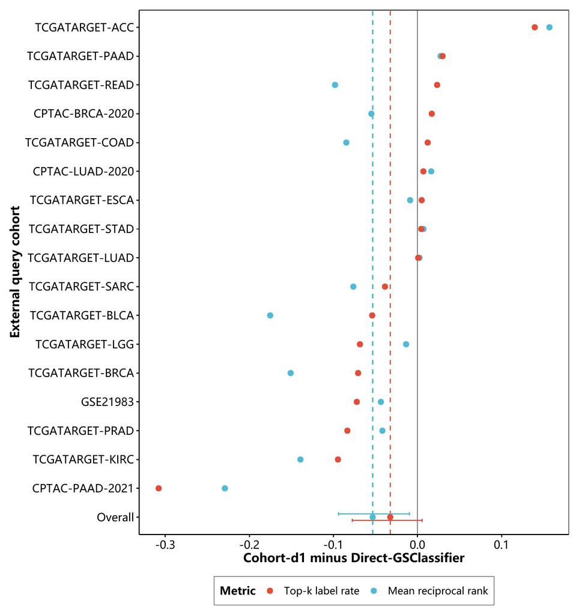

```r
knitr::include_graphics(fig2_jpg)
```

解读：纵轴每一行是一个外部 query cohort，红点为该队列的 Top-30 同癌种比例差，蓝点为 MRR 差；横轴零线左侧表示 d1 较低，右侧表示 d1 较高。普通队列点没有误差线，不能当成逐队列显著性结论。只有至少 20 位 query 的队列画在图中；底部 Overall 行却使用**所有可估计队列**等权计算，误差线为其 cohort bootstrap 区间。两条彩色虚线分别标出两项总体均值，不是某个队列的阈值。当前 Top-k 总体差为 -0.032；图中最正向的 TCGATARGET-ACC 为 0.139（77 位 query），最负向的 CPTAC-PAAD-2021 为 -0.308（140 位 query）。方向相反说明总体均值掩盖了队列差异；还应检查各队列的 reference 癌种支持量、平台与来源组成，以及预设 gene signature 是否同向变化，不能仅凭极端点推断癌种生物学。

```r
# Purpose: Expose the strongest external retrieval gains and losses with sample counts.
# Input: Cohort-level paired top-k cancer-type agreement deltas.
# Parameters: Top/bottom count from params$interpret_top_n.
# Output: Interactive table of concrete cohorts and effect directions.
retrieval_extremes <- rbind(
  transform(utils::head(retrieval_top, params$interpret_top_n), direction = "gain"),
  transform(utils::head(retrieval_bottom, params$interpret_top_n), direction = "loss")
)
render_dt(
  retrieval_extremes[, c("direction", "cohort", "estimate", "sample_count")],
  pageLength = 2L * params$interpret_top_n
)
```

|  | direction | cohort | estimate | sample_count |
| --- | --- | --- | --- | --- |
| 1 | gain | TCGATARGET-ACC | 0.1393939393939394 | 77 |
| 2 | gain | TCGATARGET-PAAD | 0.0297951582867784 | 179 |
| 3 | gain | TCGATARGET-READ | 0.02329749103942652 | 93 |
| 4 | loss | CPTAC-PAAD-2021 | -0.3078571428571429 | 140 |
| 5 | loss | TCGATARGET-KIRC | -0.09462659380692168 | 732 |
| 6 | loss | TCGATARGET-PRAD | -0.08346774193548387 | 496 |

解读：此表列出差值两端各最多 3 个队列，并在每行给出 query 数。它用于追踪上图的 TCGATARGET-ACC 与 CPTAC-PAAD-2021 等极端点：先核对样本数，再核对同癌种 reference 是否足够、平台和来源是否集中。排名是从当前数据事后挑出的，因此这些行没有额外提供一轮独立验证；若根据它们调参，应另用未参与挑选的队列检验方向是否仍成立。

### 6.2 外部癌种线性 readout：监督可读性

#### 6.2.1 这个实验在问什么

上节检索只看近邻里有多少同癌种样本；本节多问一步：如果让一个受限的监督分类器学习 reference 样本的旧癌种标签，它能否在**未参与拟合的外部队列**上认出这些标签？这里的 readout 是“从冻结表示中读出标签”的诊断实验，不是重新训练 CCS 或评估最终个性化分型。分别把 Direct 的原始特征、d1 的既有概率列作为输入，拟合两个癌种分类器；两臂使用相同的 reference 样本、同一批外部 query 和同一套真实癌种标签。模型拟合时能看到 reference 的标签，外部 query 的标签只在预测完成后计分。

本节仅纳入其癌种在至少 2 个不同 reference cohort 中有支持的外部 query cohort。本次共有 5705 个 query、17 个队列进入 readout；其他外部候选不因未通过这个**旧癌种任务**的门槛，就自动失去参加无癌种标签分析的资格。每个外部 query cohort 只对应一个癌种，因此逐队列的正确率也可理解为“该癌种在该外部队列中被认对的比例”。它衡量旧标签在新队列上的可读性，不衡量新亚型、预后或治疗获益。

#### 6.2.2 分类器怎样训练，为什么叫线性

分类器是 xgboost 的 `gblinear`：它为各输入列学习线性权重，并经 logistic／softmax 输出各癌种概率，预测为概率最高的癌种。训练时按 reference 中的癌种频数给样本反比权重，减少常见癌种主导拟合。这里的“线性”限定**从已经算好的表示到旧癌种标签的读出层**；d1 本身由冻结 cohort 模型生成，不能把整条 Direct→d1→标签路径称作线性。

每一臂先仅在 reference 内按 cohort 分组做 3 折交叉验证：同一个 reference cohort 不会同时出现在某折训练集和验证集。每折只用训练部分拟合尺度，再把这把尺子用于该折验证部分；用折内 balanced accuracy 选择该臂的正则化参数 $\lambda$。选定后，才用全部 reference 重新拟合尺度和分类器，并一次性预测外部 query。Direct 按各特征的 reference 均值与标准差变换；d1 在 reference 定标后平衡冻结模块的总权重。query 沿用对应的 reference 变换，**不再提前标准化，也不参与选 $\lambda$**。可把它想成先用参考题选评分规则，再用同一规则批改外部考卷；两臂可以各自选出不同的 $\lambda$，但外部考卷和正确答案相同。

#### 6.2.3 分数和差值怎样计算

对队列 $c$，$\mathrm{accuracy}_c=\text{该队列预测正确的 query 数}/\text{该队列 query 总数}$；先算 $\Delta_c=\mathrm{accuracy}_{c,\mathrm{d1}}-\mathrm{accuracy}_{c,\mathrm{Direct}}$，再算 $\overline\Delta=C^{-1}\sum_{c=1}^{C}\Delta_c$。正值表示 d1 在外部队列平均更易读出旧癌种，负值表示 Direct 更易读出；例如 $-0.10$ 是**低 10 个百分点**，不是“低 10%”，也不代表每个队列都下降。假设两个队列各有 100 与 10 人，第一队列 Direct／d1 分别认对 80／70 人，第二队列认对 6／8 人：两队列差值分别为 $-0.10$ 和 $+0.20$，队列等权平均为 $+0.05$。这是计算示例，不是本次结果；它说明总体方向不能由人数最多的队列单独决定。

报告另列 **pooled balanced accuracy**：把所有外部 query 合并后，先算每个癌种的召回率（该癌种认对人数／该癌种总人数），再对 $K$ 个癌种等权平均，$\mathrm{BA}=K^{-1}\sum_{g=1}^{K}\mathrm{recall}_g$。若同一癌种横跨多个外部队列，其大队列会在该癌种召回率中占更多权重；它与先让每个队列投一票的主效应不是同一口径。下表的估计、95% 区间和 P 值**只针对 cohort accuracy 的 d1−Direct 差**：以完整外部队列为重采样单位计算 bootstrap 区间，并对队列差做双侧 sign-flip 检验。pooled balanced accuracy 差仅作描述，不借用下表的区间或 P 值。

```r
readout_inference_table <- readout_inference[, c(
  "endpoint", "estimate", "ci_low", "ci_high", "p_value", "p_value_adj",
  "n_cohort", "n_sample", "resamples", "p_resamples", "p_method", "unit",
  "multiplicity_method", "status"
)]
render_dt(readout_inference_table, pageLength = 1L)
```

|  | endpoint | estimate | ci_low | ci_high | p_value | p_value_adj | n_cohort | n_sample | resamples | p_resamples | p_method | unit | multiplicity_method | status |
| --- | --- | --- | --- | --- | --- | --- | --- | --- | --- | --- | --- | --- | --- | --- |
| 1 | cohort_accuracy | -0.07566435128596981 | -0.2167110727521216 | 0.04716070758600568 | 0.32061767578125 | 0.32061767578125 | 17 | 5705 | 2000 | 131072 | exact_paired_sign_flip | query_cohort | holm | complete |

#### 6.2.4 本次结果怎样读

| 看什么 | 本次结果 | 含义 |
| --- | --- | --- |
| **主结果：队列等权 accuracy 差** | d1−Direct：-7.57 个百分点 | 每个外部队列先各算一次正确率差，再让每个队列各占一票。负值表示 d1 在这项旧癌种任务中的线性读出分数较低。 |
| 主结果的不确定性 | 95% CI：-21.67 至 4.72 个百分点；双侧 P = 0.321 | 区间和 P 值只对应上一行的**队列等权差**。 |
| 辅助描述：合并 query 后的癌种等权 balanced accuracy | Direct：24.78%；d1：16.42%；差：-8.36 个百分点 | 先把全部 query 合并，再让每个癌种各占一票；它与主结果的权重对象不同。 |

主结果涉及 17 个独立外部队列、合计 5705 个 query。点估计显示 d1 比 Direct 低约 7.57 个百分点；但 95% 区间跨过零，当前数据尚不能确定总体差异的方向。区间跨零也不等于证明两种表示一样好：本分析没有预设可接受损失界值，不能做等价或非劣效结论。表中的 `p_value` 是对队列差做 sign-flip 检验；本节只有一个推断终点，故 Holm 校正后的 `p_value_adj` 与原值相同，不构成第二份证据。

逐队列看，7 个队列 d1 较高、8 个较低、2 个相同。合并 query 的 balanced accuracy 也指向 d1 较低，但它没有本节的队列 bootstrap 区间，不能借用主结果的 P 值。两种口径只说明旧癌种标签在当前冻结表示中有多容易被这个线性读出层识别；分数下降不能单独判定 d1 去除了技术噪声、丢失了有用生物信息，或新的个性化分型会变差。

```r
# ==== Figure 3: External linear readout cohort deltas (user-adjustable parameters) ====
fig3 <- list(
  width_in = 7.2,
  height_in = 7.5,
  base_size = 11,
  point_size = 2.4,
  zero_line_width = 0.55,
  legend_position = "none"
)
readout_plot <- readout_cohort[
  order(readout_cohort$delta_accuracy),
  c("cohort", "delta_accuracy"),
  drop = FALSE
]
readout_plot$ci_low <- NA_real_
readout_plot$ci_high <- NA_real_
readout_overall_plot <- data.frame(
  cohort = "Overall",
  delta_accuracy = readout_inference$estimate[
    readout_inference$endpoint == "cohort_accuracy"
  ],
  ci_low = readout_inference$ci_low[
    readout_inference$endpoint == "cohort_accuracy"
  ],
  ci_high = readout_inference$ci_high[
    readout_inference$endpoint == "cohort_accuracy"
  ],
  stringsAsFactors = FALSE
)
readout_plot <- rbind(readout_plot, readout_overall_plot)
readout_plot$cohort <- factor(
  readout_plot$cohort,
  levels = c(as.character(readout_plot$cohort[-nrow(readout_plot)]), "Overall")
)
p3 <- ggplot2::ggplot(
  readout_plot,
  ggplot2::aes(x = .data$delta_accuracy, y = .data$cohort)
) +
  ggplot2::geom_vline(
    xintercept = 0,
    linewidth = fig3$zero_line_width,
    color = "grey55"
  ) +
  ggplot2::geom_errorbar(
    data = readout_plot[readout_plot$cohort == "Overall", , drop = FALSE],
    ggplot2::aes(xmin = .data$ci_low, xmax = .data$ci_high),
    orientation = "y",
    width = 0.22,
    linewidth = fig3$zero_line_width,
    color = nature_colors[["purple"]],
    show.legend = FALSE,
    na.rm = TRUE
  ) +
  ggplot2::geom_point(
    size = fig3$point_size,
    color = nature_colors[["purple"]]
  ) +
  ggplot2::labs(
    x = "Cohort accuracy: Cohort-d1 minus Direct-GSClassifier",
    y = "External query cohort"
  ) +
  theme_nature_readable(
    base_size = fig3$base_size,
    x_text_angle = 0,
    legend_position = fig3$legend_position
  )

# Readability check: one metric avoids a redundant legend; a tall canvas keeps
# cohort names readable and the zero line exposes the sign of every paired effect.
fig3_jpg <- .ae_save_plot(
  p3, "02.01.00. external-readout-cohort-delta", figure_dir,
  preview_dir, fig3, params$plot_preview_dpi
)
```

```
## Converting page 1 to D:/cache/ccs/_ablation-03/logs/report-previews/02.01.00-representation-20261008205707/02.01.00. external-readout-cohort-delta.jpg... done!
```

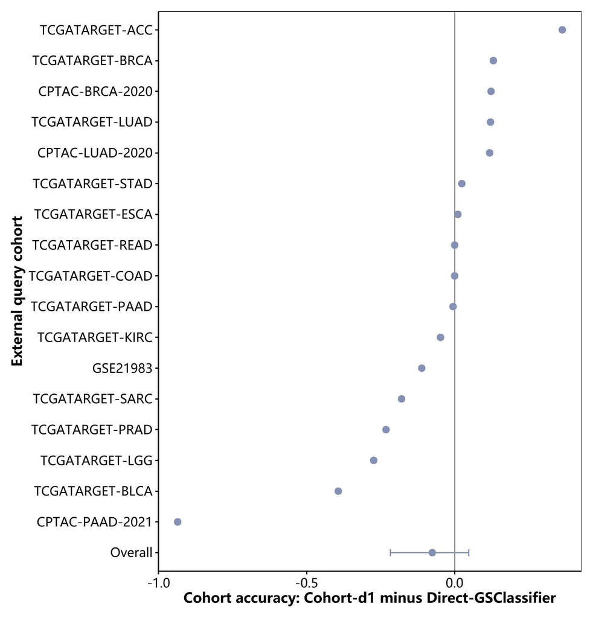

```r
knitr::include_graphics(fig3_jpg)
```

解读：横轴是每个外部队列的 $\Delta_c$，竖向零线左侧表示 d1 比 Direct 少认对该队列的 query，右侧表示多认对。每个普通点只代表**一个队列的点估计**，没有逐队列区间，不能据其离零远近宣布该队列显著。图中只展示至少 20 个 query 的队列；底部 Overall 则对**全部可估计队列**等权平均，横向误差线是队列 bootstrap 95% 区间，而不是单个患者或单个队列的误差线。显示队列中最高的 TCGATARGET-ACC 为 0.364（77 个 query），最低的 CPTAC-PAAD-2021 为 -0.936（140 个 query）；它们是看过数据后挑出的两端，不是独立确认。若同一癌种在不同平台队列中方向不一致，应先核对 reference 中该癌种的队列支持、query 样本数和技术来源，再用预设的生物任务追查机制；这张图本身无法解释为何变化。

### 6.3 训练队列学习曲线：readout 的资源敏感性

#### 6.3.1 为什么做，和前两项看法有何不同

通常说“样本效率”，是问模型能否用**更少训练数据达到某个相近的测试表现**。本节把训练资源具体定义为可用于拟合线性 readout 的**独立 reference cohort 数**，每个 cohort 内有多位患者；它并没有单独控制患者样本数。更准确地说，这是一条训练队列学习曲线：看减少训练队列后，Direct 与 d1 对同一批外部 query 的旧癌种标签还能读出多少。报告没有预设“达到多少分才算够好”的门槛，因此不能从曲线直接宣布某臂“只需多少个患者或队列”。

做这项分析，是因为上一节的完整 readout 只回答“**全部 reference 都可用于训练时**，旧癌种标签能否被线性分类器认出”；一个终点看不出两臂的差距是否依赖训练队列数量或具体组成。本节保持分类器类型、外部 query 和旧癌种任务不变，逐步改变训练 cohort，检查哪一臂在训练资源较少时更容易被读出。它也与前面的癌种检索不同：检索**不训练癌种分类器**，看局部同癌种邻居；这里重新训练读出层，看汇总多个表示特征后的监督分类表现。后文的二维 scaling 改变的是冻结 bank 的模块组合，测空间容量、冗余和近邻稳定性；本节不改变 bank，而改变读出层可使用的训练队列。

#### 6.3.2 横轴究竟减少了什么

每个请求比例都按癌种从 reference 中抽取 cohort：某癌种有至少 2 个候选 cohort 时，抽样规则至少保留 2 个；不足 2 个时保留全部。因此图上的 10%、25%、50%、100% 是**请求比例**，实际纳入的队列比例可以更高；它们不是患者样本的抽样比例。两臂在每次重复中使用**同一组训练 cohort**，并在该组内分别重新拟合尺度、选择正则化参数和训练 readout；既有 Direct 与 d1 表示保持冻结，外部 query 始终是同一批 5705 个样本。这样，曲线比较的是改变 readout 训练资源后的旧癌种可读性，而不是重新训练 CCS 或创造了新的外部验证队列。

纵轴的 balanced accuracy（BA）是先算每个癌种在固定外部 query 中被认对的比例，再对癌种等权平均；越高表示旧标签越容易从该臂读出。每个比例先对同一训练 cohort 组合计算 $\Delta_f=\mathrm{BA}_{d1,f}-\mathrm{BA}_{Direct,f}$：负值表示在**该训练资源水平**下 Direct 较高。它与上一节按外部 cohort 等权的 accuracy 主结果不同，不能把两个差值或各自的区间混为一谈。

```r
learning_resource <- learning_curve$paired[
  !duplicated(learning_curve$paired$requested_fraction),
  c("requested_fraction", "train_cohort_count_direct",
    "realized_cohort_fraction_direct"),
  drop = FALSE
]
learning_resource <- learning_resource[
  match(learning_inference$requested_fraction,
    learning_resource$requested_fraction),
  , drop = FALSE
]
direct_learning <- learning_summary[
  learning_summary$representation == "Direct-GSClassifier", , drop = FALSE
]
d1_learning <- learning_summary[
  learning_summary$representation == "Cohort-d1", , drop = FALSE
]
learning_readable <- data.frame(
  requested = scales::percent(learning_inference$requested_fraction,
    accuracy = 1),
  actual = paste0(learning_resource$train_cohort_count_direct, "/",
    manifest$reference_cohort_count, " (",
    scales::percent(learning_resource$realized_cohort_fraction_direct,
      accuracy = 0.1), ")"),
  direct = fmt_pct(direct_learning$estimate[match(
    learning_inference$requested_fraction,
    direct_learning$requested_fraction)], 2L),
  d1 = fmt_pct(d1_learning$estimate[match(
    learning_inference$requested_fraction,
    d1_learning$requested_fraction)], 2L),
  delta = paste0(fmt(100 * learning_inference$estimate, 2L), " 个百分点"),
  designs = learning_inference$n_unique_design,
  stringsAsFactors = FALSE
)
knitr::kable(
  learning_readable,
  col.names = c("请求的 cohort 比例", "实际训练 cohort", "Direct BA",
    "d1 BA", "d1−Direct", "不同训练组合数"),
  align = c("c", "c", "r", "r", "r", "c")
)
```

| 请求的 cohort 比例 | 实际训练 cohort | Direct BA | d1 BA | d1−Direct | 不同训练组合数 |
| --- | --- | --- | --- | --- | --- |
| 10% | 36/147 (24.5%) | 19.14% | 16.95% | -2.19 个百分点 | 10 |
| 25% | 53/147 (36.1%) | 21.61% | 16.55% | -5.06 个百分点 | 10 |
| 50% | 84/147 (57.1%) | 25.75% | 15.73% | -10.02 个百分点 | 10 |
| 100% | 147/147 (100.0%) | 24.78% | 16.38% | -8.40 个百分点 | 1 |

例如，请求 10% 时实际使用 36 个、占全部 reference cohort 的 24.5%，因为逐癌种最低支持数会抬高总比例。表中 BA 是该档各次拟合的平均表现；最后一列是**不同的 cohort 组合数**，不是 query 数或独立外部验证次数。100% 行仍对同一组训练 cohort 重复拟合 10 次，故其平均 BA 可以与上一节单次全量 readout 略有不同，但不代表多了 10 种独立训练设计。

```r
learning_inference_table <- learning_inference[, c(
  "requested_fraction", "estimate", "ci_low", "ci_high", "p_value", "p_value_adj",
  "n_run", "n_unique_design", "resamples", "p_resamples", "p_method", "unit",
  "multiplicity_method", "status", "reason"
)]
render_dt(learning_inference_table, pageLength = nrow(learning_inference_table))
```

|  | requested_fraction | estimate | ci_low | ci_high | p_value | p_value_adj | n_run | n_unique_design | resamples | p_resamples | p_method | unit | multiplicity_method | status | reason |
| --- | --- | --- | --- | --- | --- | --- | --- | --- | --- | --- | --- | --- | --- | --- | --- |
| 1 | 0.1 | -0.02191665866704831 | -0.04291804202395288 | -0.0029204878898213 | 0.06640625 | 0.06640625 | 10 | 10 | 2000 | 1024 | exact_paired_sign_flip | unique_training_cohort_design | holm | complete |  |
| 2 | 0.25 | -0.05059668536102602 | -0.06608048947919469 | -0.03534274806588962 | 0.001953125 | 0.005859375 | 10 | 10 | 2000 | 1024 | exact_paired_sign_flip | unique_training_cohort_design | holm | complete |  |
| 3 | 0.5 | -0.1002441642128673 | -0.1148925510292798 | -0.08513427530562127 | 0.001953125 | 0.005859375 | 10 | 10 | 2000 | 1024 | exact_paired_sign_flip | unique_training_cohort_design | holm | complete |  |
| 4 | 1 | -0.08401077939621644 |  |  |  |  | 10 | 1 | 2000 | 0 | not_estimable | unique_training_cohort_design | holm | not_estimable | fewer_than_10_independent_clusters |

技术表中的 `requested_fraction` 对应上方第一列；`estimate` 是同一训练组合内 d1−Direct 的 BA 差，再按**不同训练组合**汇总。较小比例的区间和检验只描述：在当前固定外部 query 上，换一组训练 cohort 后差值有多大变化。100% 时只剩 1 种独立训练组合；重复拟合同一批 cohort 不会创造新设计，所以设计层 CI 与 P 值不可估计。该结论不否定补充分析中固定训练设计后按**外部 query cohort**重采样得到的条件区间；两种区间回答不同问题。

```r
# ==== Figure 4: Paired learning curves (user-adjustable parameters) ====
fig4 <- list(
  width_in = 6.8,
  height_in = 4.4,
  base_size = 12,
  line_size = 0.9,
  point_size = 2.5,
  point_alpha = 0.9,
  legend_position = "bottom"
)
p4 <- ggplot2::ggplot(
  learning_summary,
  ggplot2::aes(
    x = .data$requested_fraction,
    y = .data$estimate,
    color = .data$representation,
    group = .data$representation
  )
) +
  ggplot2::geom_ribbon(
    ggplot2::aes(
      ymin = .data$ci_low_rep,
      ymax = .data$ci_high_rep,
      fill = .data$representation
    ),
    alpha = 0.14,
    color = NA
  ) +
  ggplot2::geom_line(linewidth = fig4$line_size) +
  ggplot2::geom_point(size = fig4$point_size, alpha = fig4$point_alpha) +
  ggplot2::scale_x_continuous(
    breaks = manifest$config$validation$learning_fractions,
    labels = scales::label_percent(accuracy = 1)
  ) +
  ggplot2::scale_color_manual(
    values = c(
      "Direct-GSClassifier" = nature_colors[["blue"]],
      "Cohort-d1" = nature_colors[["red"]]
    )
  ) +
  ggplot2::scale_fill_manual(
    values = c(
      "Direct-GSClassifier" = nature_colors[["blue"]],
      "Cohort-d1" = nature_colors[["red"]]
    )
  ) +
  ggplot2::labs(
    x = "Fraction of reference cohorts",
    y = "External balanced accuracy",
    color = "Representation",
    fill = "Representation"
  ) +
  theme_nature_readable(
    base_size = fig4$base_size,
    x_text_angle = 0,
    legend_position = fig4$legend_position
  )

# Readability check: four x ticks remain sparse, ribbons carry cohort/design-repeat
# bootstrap uncertainty, and the external legend avoids covering either curve.
fig4_jpg <- .ae_save_plot(
  p4, "02.01.00. paired-learning-curve", figure_dir,
  preview_dir, fig4, params$plot_preview_dpi
)
```

```
## Converting page 1 to D:/cache/ccs/_ablation-03/logs/report-previews/02.01.00-representation-20261008205707/02.01.00. paired-learning-curve.jpg... done!
```

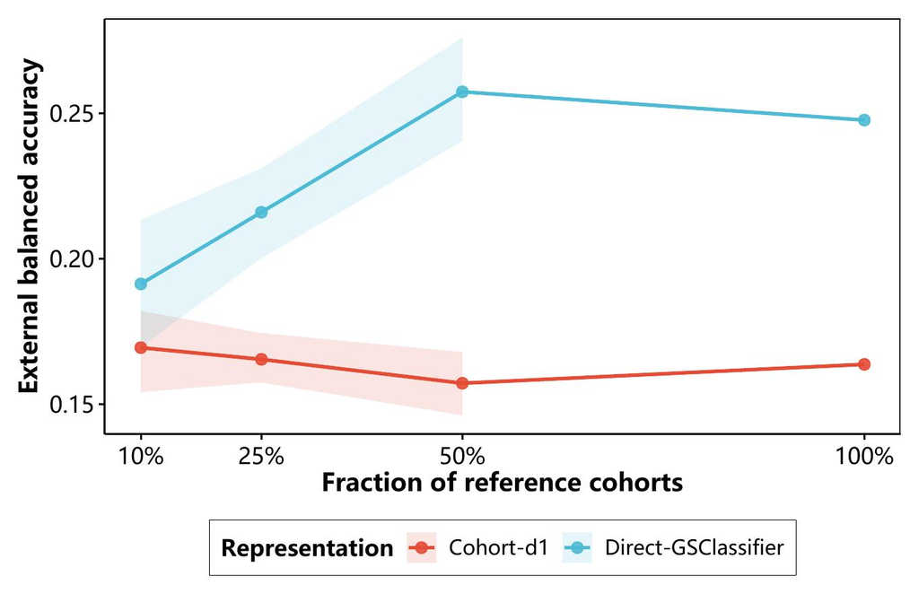

```r
knitr::include_graphics(fig4_jpg)
```

解读：横轴是**请求的**训练 cohort 比例，实际队列数见上表；纵轴是两臂在同一批外部 query 上的旧癌种 BA。最小请求比例 10% 时，d1−Direct 差为 -2.19 个百分点；请求 50% 时为 -10.02 个百分点；全部 reference 都用于训练时为 -8.40 个百分点。在本次固定 query 集上，Direct 从较少训练 cohort 到更多训练 cohort 获得了更明显的 BA 增益，d1 没有出现相同幅度的上升；但两臂差值并非严格随比例单调变化，训练 cohort 的身份、癌种覆盖和患者数也随之改变。曲线提示**当前训练资源设计下的敏感性**，不能据此断言表示本身具有普遍的样本效率优势或劣势。带状区间只反映较小比例下不同训练组合的变化；100% 只有一种独立组合，不应把重复拟合当成新的外部证据。

### 6.4 综合结果：效应量与不确定性

前三个子节分别检查同癌种近邻、旧癌种可读出性及训练队列资源依赖；这里将它们合在一起，回答一个汇总问题：把 Direct 换成 Cohort-d1 后，**旧癌种任务的表现改变了多少，观察到的得失有多稳定**？只看某一张图，容易漏掉另一项任务的代价。这里把检索、线性 readout 和学习曲线全量训练点的预设终点 d1−Direct 差值及可估计的区间并列，便于同时检查差异的方向、实际幅度和对队列或训练设计变化的敏感性，再决定哪些变化值得追查。这是对前述结果的汇总，不是新增的独立验证，也不能据此判定个性化亚型或生物学效用更好。

森林图把不同终点的方向与 CI 放在同一处；检索 Top-k 和 MRR 衡量近邻标签，readout accuracy 衡量线性分类，100% 学习曲线衡量固定外部 query 下的全量训练设计。它们回答不同问题，统计单位也不相同。

每行的圆点是预设终点的 $\Delta=\text{d1 指标}-\text{Direct 指标}$，线段是该终点适用的 95% 区间。零线表示当前指标下两臂数值相同，区间跨零表示这些数据仍容许两种方向；它既不是“已无差异”的证明，也不是预先设界的等价性检验。把几门考试成绩画在同一页便于寻找代价集中在哪一门，但各门试卷的分数尺度和重复单位不同，不能直接用线段长短给生物价值排序。

```r
# ==== Figure 10: Inference summary forest plot (user-adjustable parameters) ====
fig10 <- list(
  width_in = 10.2,
  height_in = 3.8,
  base_size = 10.5,
  point_size = 3.2,
  line_size = 0.9,
  zero_line_width = 0.5,
  value_margin_pt = 190
)
forest_plot_data <- forest_data
forest_plot_data$row <- rev(seq_len(nrow(forest_plot_data)))
forest_plot_data$label <- c(
  "Label retrieval  ·  Top-k rate",
  "Label retrieval  ·  MRR",
  "Linear readout  ·  accuracy",
  "Learning curve  ·  100%"
)
forest_plot_data$has_ci <- is.finite(forest_plot_data$ci_low) &
  is.finite(forest_plot_data$ci_high)
forest_plot_data$value_label <- ifelse(
  forest_plot_data$has_ci,
  sprintf("%+.3f\n[%+.3f, %+.3f]", forest_plot_data$estimate,
          forest_plot_data$ci_low, forest_plot_data$ci_high),
  sprintf("%+.3f\nCI unavailable", forest_plot_data$estimate)
)
p10 <- ggplot2::ggplot(
  forest_plot_data,
  ggplot2::aes(y = .data$row, x = .data$estimate)
) +
  ggplot2::geom_hline(
    yintercept = c(1.5, 2.5), color = "#E8EDF1", linewidth = 0.45
  ) +
  ggplot2::geom_vline(
    xintercept = 0,
    linewidth = fig10$zero_line_width,
    linetype = "dashed",
    color = "#9CA7B1"
  ) +
  ggplot2::geom_segment(
    data = forest_plot_data[forest_plot_data$has_ci, ],
    ggplot2::aes(x = .data$ci_low, xend = .data$ci_high,
                 y = .data$row, yend = .data$row),
    linewidth = fig10$line_size,
    lineend = "round",
    color = nature_colors[["navy"]]
  ) +
  ggplot2::geom_point(
    data = forest_plot_data[forest_plot_data$has_ci, ],
    size = fig10$point_size,
    shape = 21,
    fill = nature_colors[["navy"]],
    color = "white",
    stroke = 0.7
  ) +
  ggplot2::geom_point(
    data = forest_plot_data[!forest_plot_data$has_ci, ],
    size = fig10$point_size,
    shape = 21,
    fill = "white",
    color = nature_colors[["navy"]],
    stroke = 1.1
  ) +
  ggplot2::geom_text(
    ggplot2::aes(label = .data$value_label),
    x = Inf,
    hjust = -0.12,
    lineheight = 1.15,
    size = 3.2,
    color = "#263746"
  ) +
  ggplot2::annotate(
    "text", x = Inf, y = 4.55, label = "Estimate / 95% CI",
    hjust = -0.12, size = 3.1, fontface = "bold", color = "#687784"
  ) +
  ggplot2::scale_y_continuous(
    breaks = forest_plot_data$row,
    labels = forest_plot_data$label,
    limits = c(0.55, 4.75),
    expand = ggplot2::expansion(mult = 0)
  ) +
  ggplot2::labs(
    x = "Endpoint score difference (d1 - Direct)",
    y = NULL
  ) +
  ggplot2::coord_cartesian(clip = "off") +
  theme_nature_readable(
    base_size = fig10$base_size,
    x_text_angle = 0,
    legend_position = "none"
  ) +
  ggplot2::theme(
    panel.border = ggplot2::element_blank(),
    axis.line = ggplot2::element_line(color = "#B8C3CC", linewidth = 0.45),
    axis.ticks.y = ggplot2::element_blank(),
    axis.text.y = ggplot2::element_text(
      size = 10, color = "#263746", margin = ggplot2::margin(r = 11)
    ),
    axis.title.x = ggplot2::element_text(size = 10, face = "plain"),
    plot.margin = ggplot2::margin(12, fig10$value_margin_pt, 10, 12)
  )

# Values and interval availability appear beside each row; the open point marks
# the 100% design, where a design-level interval cannot be estimated.
fig10_jpg <- .ae_save_plot(
  p10, "02.01.00. inference-summary", figure_dir, preview_dir, fig10,
  params$plot_preview_dpi
)
```

```
## Converting page 1 to D:/cache/ccs/_ablation-03/logs/report-previews/02.01.00-representation-20261008205707/02.01.00. inference-summary.jpg... done!
```

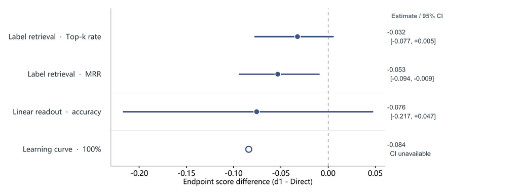

```r
knitr::include_graphics(fig10_jpg)
```

解读：四行均画 d1−Direct，虚线为零，但每行的分析单位不同。外部 query cohort 等权的检索 top-k 差为 -0.032（95% 区间 [-0.077, 0.005]），线性 readout 的 cohort accuracy 差为 -0.076（区间 [-0.217, 0.047]）；负值分别表示同癌种邻居更少、旧癌种分类更难。MRR 行另看首次同癌种命中的名次，100% learning-curve 行则固定 query、只剩 1 种训练设计，因而没有设计层区间。图把方向集中展示，不能把不同行的差值大小或线段长度相加、排序为一个生物价值分数。

## 7 cohort evidence 的二维 scaling

### 7.1 为什么要比较两种扩充方式

CCS 用多个已训练的 cohort module 为同一批样本提供证据。前面的学习曲线改变的是读出层可用的训练 cohort；这里保持评分样本和已训练 module 不变，只从同一套冻结 bank 中选取不同的 module 组合。要回答的是：增加 cohort evidence 后，d1 是否获得更多不重复、较稳定的表示方向，以及这些变化主要来自新的组织背景，还是已有组织中的更多独立队列。

只按 module 总数画一条曲线无法区分这两种来源：增加一个 module 时，可能首次纳入一种 tissue，也可能只是在已有 tissue 内多纳入一个 cohort。两种加入方式都让 d1 多出输出，却可能产生不同的冗余和近邻结构。因此，本次 bank design 使用审计恢复后的真实 tissue 字段，保留冻结 module ID，分别构造两条扩充路线：breadth 固定每种 tissue 的 cohort 数，逐步增加 tissue 种类；depth 固定 tissue 集合，逐步增加每种 tissue 内的 cohort 数。再在相同 module 总数下比较偏向 breadth 与偏向 depth 的组合。比如同样选 6 个 module，比较“3 种 tissue、每种 2 个 cohort”与“2 种 tissue、每种 3 个 cohort”；这只是设计逻辑示例，实际组合受冻结 bank 的可用模块约束。

这样才能检验在相同模块预算下，证据分散到更多组织背景与集中到已有组织各自带来什么表示变化。结果只描述当前冻结 bank 的性质；哪种扩充方式更能改善生物或临床任务，仍需独立终点验证。

### 7.2 数学对象与 bank 构造

令 $\mathcal M$ 为已训练并冻结的 module 集合，$\mathcal R$ 和 $\mathcal Q$ 分别为固定的评分 reference 与 query 样本集合，$n_R=|\mathcal R|$、$n_Q=|\mathcal Q|$。每个 module $m$ 对样本 $s$ 输出概率块 $f_m(s)\in\mathbb R^{q_m}$，其中 $q_m$ 是该块的列数。任一子 bank $B\subseteq\mathcal M$ 的表示是这些概率块的拼接：

$$d_{1,B}(s)=\bigoplus_{m\in B} f_m(s),\qquad
M(B)=|B|,\qquad T(B)=|\{t(m):m\in B\}|.$$

$t(m)$ 是 module 的真实 tissue，$M(B)$ 是 module 总数，$T(B)$ 是覆盖的 tissue 数；对已覆盖 tissue $t$，深度 $D_t(B)=|\{m\in B:t(m)=t\}|$，全 bank 中该 tissue 的可用模块集合记为 $\mathcal M_t=\{m\in\mathcal M:t(m)=t\}$。因此“二维”指 $T(B)$ 与各 tissue 的 $D_t(B)$ 两种扩充方向，不是把 d1 投影到二维。每个随机设计重复 $r$ 都先打乱 tissue 顺序及各 tissue 内的 module 顺序。Breadth 序列 $B^{\mathrm{br}}_{r,b}$ 取前 $b$ 个 tissue 各自的第一个 module，故 $T(B^{\mathrm{br}}_{r,b})=M(B^{\mathrm{br}}_{r,b})=b$、每个入选 tissue 的深度均为 1。Depth 序列固定 $\mathcal T=\{\mathrm{ACC},\mathrm{BRCA},\mathrm{CRC},\mathrm{KIRC},\mathrm{PAAD},\mathrm{PRAD},\mathrm{STAD}\}$，这七种 tissue 均至少有八个不同的冻结 module；每次重复在各 tissue 内随机排序，再逐层取前 $d=1,\ldots,8$ 个 module，故 $T(B^{\mathrm{de}}_{r,d})=7$、$D_t(B^{\mathrm{de}}_{r,d})=d$、$M(B^{\mathrm{de}}_{r,d})=7d$。序列逐层嵌套。Matched-size 配对仍沿用原设计，从同一重复中构造 $B^+_{r,M}$ 与 $B^-_{r,M}$，满足 $|B^+_{r,M}|=|B^-_{r,M}|=M$ 且 $T(B^+_{r,M})>T(B^-_{r,M})$；前者轮流从不同 tissue 取 module，后者优先填充 module 较多的 tissue。无法形成 tissue 数差异的模块数不进入配对。

几何指标先按固定 reference 估计每列的均值 $\mu_{mj}$ 和标准差 $\sigma_{mj}$，再把同一变换用于 reference 和 query；若标准差为 0 或非有限值，计算中将其置为 1。为避免输出列较多的 module 自动占更大的欧氏距离权重，bank 内每列还乘以 $1/\sqrt{M(B)q_m}$：

$$z_{B,mj}(s)=\frac{f_{mj}(s)-\mu_{mj}}{\sigma_{mj}\sqrt{M(B)q_m}},
\qquad m\in B,\;j=1,\ldots,q_m.$$

以下有效秩和近邻都基于拼接后的 $z_B$；模块冗余则按实现使用**未做上述列标准化的 reference 概率块**。三项指标的输入边界不同，不能把它们当成同一种“信息量”。

### 7.3 三项指标的定义

对 $z_B$ 的 $n_Q\times\sum_{m\in B}q_m$ query 矩阵按列再次中心化，记非零奇异值为 $\lambda_j$，令 $\pi_j=\lambda_j^2/\sum_\ell\lambda_\ell^2$。归一化有效秩为

$$R(B)=\frac{\exp\!\left(-\sum_{j:\pi_j>0}\pi_j\log\pi_j\right)}
{\min\!\left(n_Q-1,\sum_{m\in B}q_m\right)}.$$

分母是该矩阵允许的最大秩，$R(B)$ 在可计算时处于 $(0,1]$。它描述能量占用了多少**可用方向的份额**；bank 扩大时分母也会变化，因此 $R(B)$ 下降不等于原有方向或生物信息消失。

对每个 module 的 reference 概率块 $F_m^{\mathcal R}$ 按列中心化后做奇异值分解，取第一左奇异向量乘第一奇异值作为一维分数 $a_m=\lambda_{m1}u_{m1}$。模块冗余为所有可计算 module 对的绝对 Pearson 相关均值：

$$C(B)=\operatorname{mean}_{m<m',\;m,m'\in B}
\left|\operatorname{cor}_{\mathcal R}(a_m,a_{m'})\right|.$$

只含一个 module 或相关无法计算时，该项不作为有效观测。绝对值使同向和反向的高度对应都计为冗余；一维分数只概括各概率块的第一方向，并不声称完整刻画模块间依赖。

近邻稳定性比较**同一设计格、不同随机 bank 组成**。令 $N_k(s;B)$ 为 query 样本 $s$ 在同一批 query 中、按 $z_B$ 的欧氏距离找到的 $k$ 个其他 query；$\mathcal P(B)$ 是与 $B$ 具有相同设计类型、角色、层级和 module 数的其他重复所得 bank。令 $J(A,A')=|A\cap A'|/|A\cup A'|$，则

$$S(B)=\frac{1}{|\mathcal P(B)|}\sum_{B'\in\mathcal P(B)}
\frac{1}{n_Q}\sum_{s\in\mathcal Q}
J\!\left(N_k(s;B),N_k(s;B')\right).$$

令 $K$ 为预设的近邻数集合，这里 $k=\min(\max K,n_Q-1)$；不足两个可比较 bank 的设计格不估计 $S(B)$。$S(B)$ 越高，表示换一种同规格的 module 组合后，query 近邻名单越相似。计算中另有 $J(N_k(s;B),N_k(s;\mathcal M))$ 形式的**对子 bank 与完整 bank 的近邻诊断**，但它不是本图和下表使用的 `neighbor_stability`，完整 bank 也不是生物真值。

### 7.4 曲线、对比与不确定性

对任一指标 $y(B)\in\{R(B),C(B),S(B)\}$，Figure 8 在每个 breadth 或 depth 层级展示随机设计重复的均值。表中的斜率先在每个重复 $r$ 内，沿相应嵌套序列拟合

$$y(B_{r,\ell})=\alpha_r+\beta_r\log_2 M(B_{r,\ell})+\varepsilon_{r,\ell},
\qquad \widehat\beta=\frac{1}{R_0}\sum_{r=1}^{R_0}\widehat\beta_r.$$

因此 $\widehat\beta$ 的单位是 **module 数每翻倍时的指标变化**，不是每增加一个 tissue 或 cohort 的变化；相邻嵌套 bank 的边际变化另定义为 $y(B_{r,\ell})-y(B_{r,\ell-1})$。对 Figure 9，同预算的配对差是

$$\delta_{r,M}=y(B^+_{r,M})-y(B^-_{r,M}),\qquad
\overline\delta_M=\operatorname{mean}_r\delta_{r,M}.$$

Figure 9 按 $M$ 展示 $\overline\delta_M$；推断表的 matched-size 总体行则先在每个重复内对可配对的 $M$ 求均值，再跨重复汇总。表中的 breadth–depth interaction 另在每个重复的 matched banks 上拟合 $y=\alpha+\gamma_T T+\gamma_D\bar D+\gamma_{TD}T\bar D+\varepsilon$，其中 $\bar D=M/T$；$\gamma_{TD}$ 是这个线性模型的交互系数，不是因果交互。

令 $v_1,\ldots,v_{R_0}$ 为某个图格或对比在各随机设计重复上的估计值，则展示值是 $\bar v=R_0^{-1}\sum_r v_r$。每次 bootstrap 有放回地抽取 $R_0$ 个**完整重复**，得到 $\bar v^{*(b)}$；95% 区间取这些 bootstrap 均值的 2.5% 与 97.5% 分位数。推断表检验零效应时，对重复级估计作双侧 sign-flip：不超过 18 个重复时遍历 $\epsilon_r\in\{-1,1\}$，比较 $|R_0^{-1}\sum_r\epsilon_r v_r|$ 与 $|\bar v|$；更多重复时改用随机符号抽样，并对多个检验作 Holm 校正。该检验的有效性依赖零假设下重复级效应可交换地改变符号。固定的 query 样本、同一重复内的网格点和 module 均不充当独立重复。这些区间与 $P$ 值只描述当前冻结 bank 的组成敏感性，不是未来新 cohort 的人群推断。

### 7.5 Figure 8 的三行怎么读

把每个 module 看作给同一批样本画像的一位“观察员”。图中三行分别回答不同问题：

| 图中行 | 它在问什么 | 曲线升高时表示什么 |
| --- | --- | --- |
| 有效秩（Effective rank） | 多位观察员拼出的画像，利用了可用变化方向中的多大比例？ | 利用的方向占比更大；下降也可能是可用方向增加得更快，不能直接说原有信息消失。 |
| 模块冗余（Module redundancy） | 不同观察员在 reference 样本上的主要变化趋势有多相像？ | 这些主要趋势更相似；这里只比较每个模块的第一方向，不能当作全部信息的重复率。 |
| 近邻稳定性（Neighbor stability） | 按相同规则换一组 module 后，同一 query 样本找到的近邻名单还像不像？ | 不同 bank 组合给出的名单更一致；一致不等于名单符合生物学真值或临床用途。 |

读图时分别沿每一行向右看变化。三行纵轴独立缩放，不能拿不同指标的曲线高度比较“收益”；左右两列的组织集合和模块总数也不同，不能直接据此选出更优扩充路线。

```r
# ==== Figure 8: Breadth and depth scaling (user-adjustable parameters) ====
fig8 <- list(
  # A wide canvas keeps the 3 x 2 facet labels readable without abbreviation.
  width_in = 8.2,
  height_in = 6.4,
  base_size = 11,
  # Lines carry repeat means; points keep sparse feasible grid cells visible.
  line_size = 0.85,
  point_size = 2.2,
  point_alpha = 0.90,
  ribbon_alpha = 0.14,
  legend_position = "none"
)
p8 <- ggplot2::ggplot(
  scaling_sequence,
  ggplot2::aes(
    x = .data$scaling_axis,
    y = .data$estimate,
    color = .data$design_label,
    fill = .data$design_label,
    group = .data$design_label
  )
) +
  ggplot2::geom_ribbon(
    ggplot2::aes(
      ymin = .data$ci_low_seq,
      ymax = .data$ci_high_seq
    ),
    alpha = fig8$ribbon_alpha,
    color = NA
  ) +
  ggplot2::geom_line(linewidth = fig8$line_size) +
  ggplot2::geom_point(
    size = fig8$point_size,
    alpha = fig8$point_alpha
  ) +
  ggplot2::facet_grid(
    rows = ggplot2::vars(.data$metric_label),
    cols = ggplot2::vars(.data$design_label),
    scales = "free"
  ) +
  ggplot2::scale_x_continuous(breaks = function(limits) {
    ticks <- if (diff(limits) <= 8) {
      seq.int(ceiling(limits[1]), floor(limits[2]))
    } else {
      pretty(limits, n = 5)
    }
    ticks[ticks %% 1 == 0]
  }) +
  ggplot2::scale_color_manual(values = c(
    "Tissue breadth" = nature_colors[["blue"]],
    "Within-tissue depth" = nature_colors[["red"]]
  )) +
  ggplot2::scale_fill_manual(values = c(
    "Tissue breadth" = nature_colors[["blue"]],
    "Within-tissue depth" = nature_colors[["red"]]
  )) +
  ggplot2::labs(
    x = "Added tissues or cohort-depth level",
    y = "Estimate",
    color = "Bank design",
    fill = "Bank design"
  ) +
  theme_nature_readable(
    base_size = fig8$base_size,
    x_text_angle = 0,
    legend_position = fig8$legend_position
  )

# Readability check: each scientific property receives its own y scale while the
# x scale follows each design's levels; panel heights are not interpreted
# as cross-metric effect sizes.
fig8_jpg <- .ae_save_plot(
  p8, "02.01.00. cohort-evidence-sequences", figure_dir,
  preview_dir, fig8, params$plot_preview_dpi
)
```

```
## Converting page 1 to D:/cache/ccs/_ablation-03/logs/report-previews/02.01.00-representation-20261008205707/02.01.00. cohort-evidence-sequences.jpg... done!
```

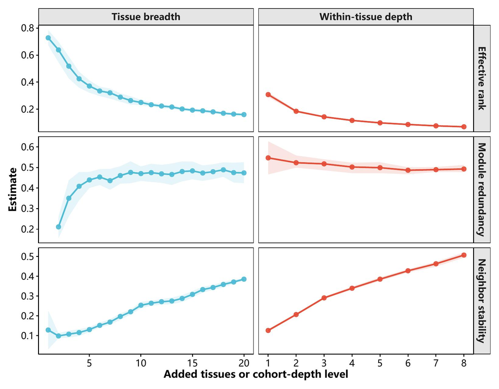

```r
knitr::include_graphics(fig8_jpg)
```

右列固定 ACC、BRCA、CRC、KIRC、PAAD、PRAD 和 STAD 七种 tissue；横轴 1–8 表示每种 tissue 纳入的模块数，总模块数依次为 7、14、21、28、35、42、49、56。左列仍沿用全部可用 tissue 的逐种纳入顺序，两列的 tissue 集合与模块预算不同，不能由此直接判定哪种扩展路线更优。五次 bank 设计重复的区间只描述当前冻结模块组合的探索性敏感性。

**把这张图想成老师观察小朋友。** 每个 cohort module 像一位老师，同一批 query 样本像一群小朋友。左列每向右一步，就多请一位来自不同班的老师；右列固定七个班，每班再多请一位老师。三排图分别在说：

- **上排，有效秩：** 左列从 0.728 降到 0.160，右列从 0.308 降到 0.070。老师越多，能写观察记录的位置越多；但真正不同的说法没有按同样比例增加，所以“新说法占可用位置的比例”下降。这不表示原有的说法消失了。
- **中排，模块冗余：** 左列从 0.211 到 0.474，总体上升后趋平；右列从 0.547 到 0.493，略降后趋平。也就是说，多请不同班的老师时，他们的主要说法越来越相像；固定七个班再加老师时，这种相像程度没有一起升高。这里只比较每位老师的主要说法，不能断定他们的全部记录都重复。
- **下排，近邻稳定性：** 左列从 0.128 升到 0.385，右列从 0.126 升到 0.507。按同样规则换一组老师，大家列出的“谁和谁像”名单越来越接近；名单一致，并不保证他们判断正确。

```r
render_dt(depth_marginal_table, pageLength = nrow(depth_marginal_table))
```

|  | depth_step | module_count | metric | change | ci_low | ci_high | design_repeats | status |
| --- | --- | --- | --- | --- | --- | --- | --- | --- |
| 1 | 1 to 2 | 14 | Module redundancy | -0.02368832986353755 | -0.08989379621262804 | 0.03410098141742812 | 5 | exploratory |
| 2 | 2 to 3 | 21 | Module redundancy | -0.005530432083152337 | -0.03137451841708279 | 0.0202935771958513 | 5 | exploratory |
| 3 | 3 to 4 | 28 | Module redundancy | -0.01527724520522316 | -0.02763189429908763 | -0.005165711754911984 | 5 | exploratory |
| 4 | 4 to 5 | 35 | Module redundancy | -0.00325703652779189 | -0.01614994106029192 | 0.009635868004708137 | 5 | exploratory |
| 5 | 5 to 6 | 42 | Module redundancy | -0.0124235418353768 | -0.03563674930244112 | 0.008276174181040773 | 5 | exploratory |
| 6 | 6 to 7 | 49 | Module redundancy | 0.00287729547720641 | -0.007364652594073928 | 0.01378306412134745 | 5 | exploratory |
| 7 | 7 to 8 | 56 | Module redundancy | 0.003134046341065433 | -0.005146252425570841 | 0.01141434510770171 | 5 | exploratory |
| 8 | 1 to 2 | 14 | Neighbor stability | 0.08058752556534293 | 0.07521689050484567 | 0.0873146555574069 | 5 | exploratory |
| 9 | 2 to 3 | 21 | Neighbor stability | 0.0842919508501666 | 0.07846353017669637 | 0.09142711197677798 | 5 | exploratory |
| 10 | 3 to 4 | 28 | Neighbor stability | 0.04876255230436606 | 0.04254263466564044 | 0.05562750968377902 | 5 | exploratory |

[output cut: 11 more lines]

相邻层变化是同一重复内下一层减上一层的指标值，每一步同时增加七个模块；表中区间以完整 bank 设计重复为抽样单位。它显示曲线在哪一步上升或下降，不把局部波动解释为已证实的饱和点。

解读：两列分别是扩大 tissue 种类的 breadth 和增加同 tissue 模块的 depth；每行只在自己的指标尺度上读，纵轴自由缩放，不能跨行比较柱高。当前模块数每翻倍，归一化有效秩沿 breadth 路线的估计变化为 -0.136，沿 depth 路线为 -0.076；正值表示可用方向中被实际占用的份额上升，负值则相反。斜率来自当前冻结 atlas 的设计序列，而不是未来任一新 cohort 的预期收益。还应同时看模块冗余与**不同 bank 组成之间**的近邻稳定性：新增方向若伴随近邻不稳定，其用途仍需在独立生物任务上核验。

```r
scaling_inference_table <- scaling_inference[, c(
  "contrast_type", "metric_name", "estimate", "ci_low", "ci_high",
  "p_value", "p_value_adj", "n_cohort", "p_resamples", "p_method", "unit",
  "status", "reason"
)]
render_dt(scaling_inference_table, pageLength = nrow(scaling_inference_table))
```

|  | contrast_type | metric_name | estimate | ci_low | ci_high | p_value | p_value_adj | n_cohort | p_resamples | p_method | unit | status | reason |
| --- | --- | --- | --- | --- | --- | --- | --- | --- | --- | --- | --- | --- | --- |
| 1 | breadth_depth_interaction | cka_to_full_d1 | 0.0003021252534499717 | 0.0002367071029803187 | 0.0003629950760447555 | 0.0625 | 1 | 5 | 32 | exact_paired_sign_flip | design_repeat | exploratory | fewer_than_ten_independent_design_repeats |
| 2 | breadth_depth_interaction | distance_spearman_to_full_d1 | 0.0006735542352289552 | 0.0005372574652138471 | 0.0007867704435820771 | 0.0625 | 1 | 5 | 32 | exact_paired_sign_flip | design_repeat | exploratory | fewer_than_ten_independent_design_repeats |
| 3 | breadth_depth_interaction | knn_jaccard_to_full_d1 | 0.003676317071742886 | 0.003644271228327528 | 0.003706447136968422 | 0.0625 | 1 | 5 | 32 | exact_paired_sign_flip | design_repeat | exploratory | fewer_than_ten_independent_design_repeats |
| 4 | breadth_depth_interaction | lineage_balanced_accuracy_d1 | 3.2336741978354e-05 | -0.000116735517441152 | 0.0001723444642922717 | 0.8125 | 1 | 5 | 32 | exact_paired_sign_flip | design_repeat | exploratory | fewer_than_ten_independent_design_repeats |
| 5 | breadth_depth_interaction | lineage_macro_auroc_d1 | 0.0001014158651509632 | 6.62633092063741e-05 | 0.000134101173237025 | 0.0625 | 1 | 5 | 32 | exact_paired_sign_flip | design_repeat | exploratory | fewer_than_ten_independent_design_repeats |
| 6 | breadth_depth_interaction | lineage_mrr@15 | 8.713280806223154e-05 | 5.70934984421547e-05 | 0.0001225280108198039 | 0.0625 | 1 | 5 | 32 | exact_paired_sign_flip | design_repeat | exploratory | fewer_than_ten_independent_design_repeats |
| 7 | breadth_depth_interaction | lineage_mrr@30 | 8.52774342079927e-05 | 5.495385820680824e-05 | 0.0001185410738076029 | 0.0625 | 1 | 5 | 32 | exact_paired_sign_flip | design_repeat | exploratory | fewer_than_ten_independent_design_repeats |
| 8 | breadth_depth_interaction | lineage_mrr@5 | 9.006996150930515e-05 | 6.069994511466425e-05 | 0.0001271459382215526 | 0.0625 | 1 | 5 | 32 | exact_paired_sign_flip | design_repeat | exploratory | fewer_than_ten_independent_design_repeats |
| 9 | breadth_depth_interaction | lineage_top_k@15 | 9.163801839386871e-05 | 6.795608967777913e-05 | 0.0001153199471099583 | 0.0625 | 1 | 5 | 32 | exact_paired_sign_flip | design_repeat | exploratory | fewer_than_ten_independent_design_repeats |
| 10 | breadth_depth_interaction | lineage_top_k@30 | 7.013636653913517e-05 | 4.592684911451903e-05 | 9.43458839637513e-05 | 0.0625 | 1 | 5 | 32 | exact_paired_sign_flip | design_repeat | exploratory | fewer_than_ten_independent_design_repeats |

[output cut: 90 more lines]

解读：这一表的重复单位是**bank 设计序列**，本次仅有 5 条；每行应先看比较的是 breadth、depth 还是同预算差，再看估计方向与 `status`。表内区间和 P 值来自这些固定设计的变化，重复较少的行标为 exploratory，不能解释为未来新 cohort 的人群推断。若某种扩展路线的效果有决策价值，应预先增加独立 bank 设计，并做留一 tissue 或留一 cohort 的敏感性检查：若移除某个容量很大的模块组后方向改变，当前斜率更可能由该组驱动，而非该路线普遍有效。

```r
# ==== Figure 9: Matched-size breadth versus depth (user-adjustable parameters) ====
fig9 <- list(
  width_in = 9.2,
  height_in = 5.2,
  base_size = 11,
  line_size = 0.85,
  point_size = 2.3,
  point_alpha = 0.92,
  ribbon_alpha = 0.15,
  zero_line_width = 0.55,
  legend_position = "none"
)
p9 <- ggplot2::ggplot(
  scaling_matched,
  ggplot2::aes(x = .data$module_count, y = .data$estimate)
) +
  ggplot2::geom_hline(
    yintercept = 0,
    linewidth = fig9$zero_line_width,
    color = "grey55"
  ) +
  ggplot2::geom_ribbon(
    ggplot2::aes(
      ymin = .data$ci_low_matched,
      ymax = .data$ci_high_matched
    ),
    fill = nature_colors[["green"]],
    alpha = fig9$ribbon_alpha
  ) +
  ggplot2::geom_line(
    linewidth = fig9$line_size,
    color = nature_colors[["green"]]
  ) +
  ggplot2::geom_point(
    size = fig9$point_size,
    alpha = fig9$point_alpha,
    color = nature_colors[["green"]]
  ) +
  ggplot2::facet_wrap(ggplot2::vars(.data$metric_label), scales = "free_y") +
  ggplot2::scale_x_continuous(
    breaks = sort(unique(scaling_matched$module_count))
  ) +
  ggplot2::labs(
    x = "Matched frozen cohort modules (linear scale)",
    y = "Breadth-heavy minus depth-heavy"
  ) +
  theme_nature_readable(
    base_size = fig9$base_size,
    x_text_angle = 45,
    legend_position = fig9$legend_position
  )

# Readability check: the zero reference line makes direction explicit, free y
# scales prevent small stability differences being flattened, and 45-degree x
# labels separate the dense 75/100/125-module ticks without hiding grid cells.
fig9_jpg <- .ae_save_plot(
  p9, "02.01.00. cohort-evidence-matched", figure_dir,
  preview_dir, fig9, params$plot_preview_dpi
)
```

```
## Converting page 1 to D:/cache/ccs/_ablation-03/logs/report-previews/02.01.00-representation-20261008205707/02.01.00. cohort-evidence-matched.jpg... done!
```

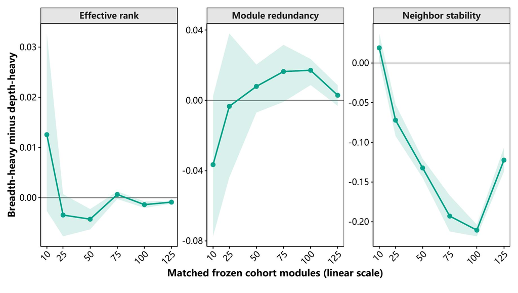

```r
knitr::include_graphics(fig9_jpg)
```

**还是请老师观察同一批小朋友，但这次每组老师的人数一样。** 一种请法是尽量从更多班级请老师，每班少请几位（breadth-heavy）；另一种是从较少班级请老师，每班多请几位（depth-heavy）。横轴是两组各请了多少位老师。每个点都用“更多班级组的指标 − 较少班级组的指标”计算：点在零线上方，表示更多班级组的该项指标较高；在零线下方则是较少班级组较高。Figure 8 看各自增加老师时怎样变化，Figure 9 则在人数相同的条件下比较两种请法，不能把 Figure 8 的两条曲线直接相减。

三列仍是 Figure 8 的三个问题，只是现在读的是**两组之间的差**：

- **左列，有效秩：** 差值大多贴近零线。两种请法对“实际用到的变化方向占可用方向的比例”没有呈现持续同向的差异；不能把接近零解读为已证明两者等价。跨可配对人数汇总的差值为 0.001。
- **中列，模块冗余：** 小人数时差值在零线下方，随后多在零线上方。正值表示来自更多班级的老师，其主要观察趋势反而略像一些；这里没有比较他们全部记录是否重复。跨可配对人数汇总的差值为 0.001。
- **右列，近邻稳定性：** 除最小人数外，点都在零线下方。同样重新挑选一组老师时，来自较少班级、每班人数更多的组合，给小朋友列出的“谁和谁像”名单通常更一致。跨可配对人数汇总的差值为 -0.119；名单更一致不代表它更正确，也不表示它更接近完整 bank 的名单。

浅色带是反复更换同规格模块组合后，这个差值的探索性 95% 区间；跨过零线时，不宜把该人数下的方向说得很确定。这三列回答的问题不同，不能把数值相加来选“赢家”。当前比较只针对冻结 bank；若要决定实际扩充路线，还需在新队列中用相同模块预算比较预先指定的外部生物终点。

### 7.6 Figure 8/9：哪些结论比较稳妥

这里的“稳妥”指**在同一批 query、同一个冻结 module 池和本次 5 次 bank 设计重复内，可以如实报告的观察方向**，不等于已通过统计检验或能推广到新 cohort。

- **Figure 8：两条扩充路线的方向较一致。** module 总数每翻倍，归一化有效秩沿 breadth 和 depth 的斜率分别为 -0.136（探索性 95% CI [-0.153, -0.119]）和 -0.076（[-0.081, -0.071]）；近邻稳定性的斜率分别为 0.073（[0.061, 0.084]）和 0.127（[0.120, 0.133]）。因此可以说：在当前冻结 bank 内，两个序列都呈现**归一化有效秩下降、不同 bank 组合的近邻名单更一致**。有效秩是占可用方向的份额，下降不证明原有信息消失；稳定性上升也不证明邻居更正确。
- **Figure 8：冗余的结论要分路线。** breadth 的模块冗余斜率为 0.058（[0.027, 0.086]），可描述为随 tissue 种类增加而上升；depth 为 -0.020（[-0.043, 0.002]），其区间跨零，不能说同一 tissue 内继续增加模块必然降低冗余。
- **Figure 9：同模块预算下，近邻稳定性偏向 depth-heavy。** breadth-heavy 减 depth-heavy 的跨预算平均差为 -0.119（[-0.130, -0.109]）；除最小预算外，图中各点也都在零线下方。这只说明当前配对设计中的近邻名单一致性较高。有效秩和模块冗余的总体差分别为 0.001（[-0.003, 0.004]）和 0.001（[-0.011, 0.013]），区间均跨零；**没有检出明确差异不等于证明两种分配等价**。

**统计上还不能称为“confirmed”。** 本次仅有 5 次设计重复；上述方向较一致的斜率和等预算近邻差，在推断表中的双侧精确 sign-flip 原始 P 值均为 0.0625，Holm 校正后 P 值为 1。五次重复下双侧精确检验的最小可达 P 值就是 0.0625；bootstrap 95% 区间即使未跨零，也不能据此改写成“P < 0.05”或“已证实”。这些区间描述的是冻结 bank 的设计组合敏感性，不能推断新训练 cohort 的效果。尤其是更大 bank 之间可能共享更多 module，近邻稳定性上升还需控制组合重叠后再检验。

### 7.7 这些结果为何值得进入论文

**纳入论文的核心理由，是这项分析直接检验了 CCS 的一个方法学前提：汇集更多 cohort 的证据，怎样改变同一个患者的表示，以及这种表示对 cohort 选择有多敏感。** 对个性化泛癌分类框架而言，仅报告最终分类分数，仍无法说明多 cohort 证据整合起到了什么作用；本节通过固定评分样本和冻结 module、改变 bank 组成，给出了可以核查的表示性质。它能帮助作者判断“多 cohort 整合”这一设计在论文中应如何解释。

首先，它为多 cohort 整合提供了一个具体的价值解释。当前冻结 bank 中，沿 breadth 扩充时近邻稳定性从 0.128 变为 0.385，沿 depth 扩充时从 0.126 变为 0.507。这表明，在固定 query 样本上，更大的 bank 给出的局部样本关系对**更换同规格模块组合**更一致。若分类所依据的样本关系随 cohort module 的选择大幅改变，后续分型也难以可靠复现；因此，减少这种组成敏感性是一项值得独立报告的积极性质。不过，当前指标只测模块组合扰动下的近邻一致性，尚未测同一患者重复检测、跨中心测量或最终临床决策的一致性。

其次，它约束了“更多 cohort 带来更多信息”的解释。两条扩充路线的归一化有效秩均下降，说明实际使用的方向占可用方向的比例降低；由于分母随 bank 容量变化，不能据此断言原有方向或生物信息消失。结合近邻稳定性上升，可以提出一个值得后续检验的机制假设：**新增 cohort 的作用可能更多地体现为确认已有共同结构，而独特方向没有随表示维度同比增加。** 这使证据互证与方向扩张成为可以分别讨论的问题；当前结果尚未证明这一机制，也不能把归一化有效秩直接当作生物信息总量。

第三，它把 bank 的规模问题推进到组成问题。Figure 9 在相同 module 预算下，breadth-heavy 减 depth-heavy 的近邻稳定性平均差为 -0.119（探索性 95% CI [-0.130, -0.109]），当前方向偏向 depth-heavy。这提示组织覆盖广度与组织内队列深度可能承担不同作用，能够引出“有限模块预算应如何分配”的研究问题。支撑这一比较的是同预算的 Figure 9；Figure 8 两列的组织集合与模块预算不同，不能直接用两列终点或斜率选出更优路线。当前匹配的是 module 数，也没有保证患者数、输出维度或训练成本完全相同。

### 7.8 论文中的定位与后续验证

**当前适合将本节定位为探索性的表示稳健性证据。** 只有 5 次 bank 设计重复；上述等预算稳定性差的精确检验原始 P 值为 0.0625，Holm 校正后为 1。探索性 bootstrap 区间未跨零也不能替代这一检验，更不能将固定 query 和冻结模块池的结果推广为新 cohort 的预期效果。论文中可以如实表述为：“在当前冻结 cohort bank 和固定 query 中，扩大 bank 伴随模块组合扰动下更一致的近邻关系，同时归一化有效秩下降；同模块预算的比较观察到 depth-heavy 组合的近邻稳定性较高。”这一表述不包含生物学正确性、临床分类改善或最优扩充策略已得到证明的结论。

如果论文主线包含“多 cohort 证据如何形成可靠的个体表示”，正文可保留一个精简面板，突出组成敏感性与容量利用的关系，将完整 Figure 8/9、设计参数和推断表放入补充材料。如果论文主要强调分类性能，本节更适合作为补充诊断，帮助读者理解 bank 设计及其局限。最终取舍应由作者根据论文主线和证据强度决定；**它值得进入论文的理由，是解释并约束 CCS 的证据整合逻辑，当前结果还不足以宣布 depth 是更优策略，或 cohort 增加已经改善临床效果。**

还需区分证据互证与抽样重叠：所有设计重复都从同一个冻结模块池抽取，bank 变大时，不同重复之间共享模块的机会也会增加，近邻稳定性可能因此上升。当前五次设计重复及其区间不能分离这部分影响，更不能说明新训练的 cohort module 必然带来同等收益。后续可按以下顺序检验：

- **控制模块重叠：** 在相同 module 数、tissue 组成和固定 query 下，记录每对 bank 的共享模块比例，比较重叠程度相近的 bank；也可建立保留该重叠结构的随机基线。只有控制共享比例后稳定性仍随证据增加而提高，才更支持多 cohort 证据整合本身带来的稳健性。
- **检验新增 cohort 与实际决策：** 在独立队列训练此前未进入冻结 bank 的 module，以相同模块预算比较扩充前后的近邻一致性及预先指定的外部生物终点；再用跨中心或重复检测样本检验最终分型的一致性与任务表现。若这些独立检验同向改善，且生物终点和分类性能没有下降，才可进一步讨论临床场景所需的可重复性。

## 8 技术来源与癌种标签的联合评估

### 8.1 为什么要同时看技术来源与癌种

**我们希望相似样本因为生物状态相近而成为邻居，但检测方式也可能让它们看起来相似。** 例如，某个平台的测量偏差会给不同患者留下共同痕迹。如果模型主要按这些痕迹找邻居，就可能学到一个“技术捷径”：在熟悉的平台上表现不错，换个平台便不稳定。本节分别检查检测类型（`assay_type`）、检测平台（`platform_id`）和数据来源（`source_system`），观察 d1 相对 Direct 是否改变了这种聚集。

可以把任务想成**给宠物照片找相似照片**：猫和狗对应不同癌种，相机对应检测平台，相册对应 cohort。理想情况下，一张猫照片找到其他相册中的猫，是因为动物本身相似；如果总找到同款相机拍摄的照片，就要检查模型是否被相机色调吸引。可是，“同相机照片少了”也可能只是因为猫照片少了、狗照片多了。因此，技术来源与癌种需要一起看：前者检查邻居是否按测量来源聚集，后者作为保护性参照，检查已知的生物标签关系保留多少。癌种只是生物信息的一部分，还需结合后续 gene signature 评估与独立生物学终点判断。

### 8.2 先分清：从哪里找邻居，从哪里算背景

沿用前面的跨队列检索设定，令 $q$ 表示一个待评估的 query 样本，$c_q$ 是它的 cohort，$y_q$ 是它的癌种，$t_q$ 是当前检查的技术标签；$m$ 表示 Direct 或 d1。一次只检查一个技术字段，例如检查平台时，$t_q$ 就是该患者的检测平台。

**实际找邻居时，候选池包含其它 cohort 的所有癌种。** 记这个池为

$$\mathcal R_q=\{r\in\mathrm{reference}:c_r\ne c_q\},
\qquad
\mathcal N_q^{(m)}(k)=\text{表示 }m\text{ 在 }\mathcal R_q\text{
中找到的前 }k\text{ 个邻居}.$$

本图使用 $k=$ 30。两臂面对同一个 query 和同一个 reference 候选池，但各自根据表示距离排序，因此邻居名单可以不同。排除同 cohort 邻居，是为了防止靠本队列的共同痕迹完成检索；它不等于排除了跨队列的平台或来源差异。

**计算技术背景时，才进一步限制为同癌种。** 记背景池为

$$\mathcal P_q=\{r\in\mathcal R_q:y_r=y_q\}.$$

回到照片例子：先从其它相册的猫狗照片中找最相似的照片；另从其它相册的猫照片中，统计 query 所用相机有多常见。**背景池限制了癌种，实际近邻池没有限制癌种。** 这是理解后面公式的关键，否则容易误以为图中已经做了癌种内检索。

### 8.3 同技术比例与 excess：一步一步算

先计算实际近邻的同技术比例，称为 observed rate。技术标签完整时，其公式为

$$O_q^{(m)}=\frac{1}{k}\sum_{r\in\mathcal N_q^{(m)}(k)}
\mathbf 1(t_r=t_q).$$

符号 $\mathbf 1(\cdot)$ 是一个“计数开关”：括号里的条件成立就记 1，否则记 0。把这些 0 和 1 加起来，就是同技术邻居数，再除以邻居总数。例如，10 个邻居中有 7 个与 query 使用同款相机，$O=7/10=0.70$。这里用 10 个邻居方便手算，**以下例子均为教学示例，不是本次分析结果**。

再计算背景同技术比例，称为 expected rate：

$$B_q=\frac{1}{|\mathcal P_q|}\sum_{r\in\mathcal P_q}
\mathbf 1(t_r=t_q).$$

$|\mathcal P_q|$ 表示背景池的样本数。若其它相册的 100 张猫照片中，有 40 张来自 query 所用的相机，则 $B=40/100=0.40$。这里的 expected 是**现有同癌种 reference 的经验背景比例**，并非随机模型推导出的理论概率，也不是经过所有混杂因素校正的期望。

上面两式先按标签完整的情况写出，便于理解分母。实际代码计算 $O$ 时剔除无法比较的 NA 匹配；计算 $B$ 时仅保留 query 与 reference 技术标签均非缺失、非空的比较。因此标签不完整时，应分别除以各自的可比较数，不能一律除以 $k$ 或背景池总人数。没有可用背景时，excess 为 NA，不能当作零。

最后计算单臂的技术近邻超额，称为 technical excess：

$$E_q^{(m)}=O_q^{(m)}-B_q.$$

上例得到 $E=0.70-0.40=0.30$，即近邻的同相机比例比同癌种背景高 **30 个百分点**。$E>0$ 表示高于背景，$E=0$ 表示恰与背景相同，$E<0$ 表示低于背景。它避免把“这种相机本来就很多”直接误判成模型偏爱；但由于 $O$ 可包含其它癌种，这还不是严格的癌种内技术效应。即便 $E=0$，也不能据此宣布表示没有技术偏差。

### 8.4 两臂相减时，背景为什么会抵消

对同一个 query，$B_q$ 只由 reference 元数据决定，与选择 Direct 还是 d1 无关。因此，配对差值为

$$\begin{aligned}
\Delta_q^{\mathrm{tech}}
&=E_q^{(\mathrm{d1})}-E_q^{(\mathrm{Direct})}\\
&=(O_q^{(\mathrm{d1})}-B_q)-(O_q^{(\mathrm{Direct})}-B_q)\\
&=O_q^{(\mathrm{d1})}-O_q^{(\mathrm{Direct})}.
\end{aligned}$$

中间一行的 $-B_q$ 与 $+B_q$ 正好抵消。假设 Direct 的同技术比例是 0.70，d1 是 0.50，共同背景是 0.40；两臂 excess 分别为 0.30 和 0.10，差为 $0.10-0.30=-0.20$，与 $0.50-0.70=-0.20$ 完全一致。

**所以 Figure 5 的纵轴可直接读作“d1 − Direct 的同技术近邻比例差”。** 负值表示 d1 找到的同技术邻居比例较低，正值表示较高；$-0.20$ 是低 20 个百分点。d1 此时仍高于背景 10 个百分点，说明“两臂相比减少”与“已经没有超额聚集”是两个不同判断。共同背景帮助解释单臂水平，却不会在两臂差值中自动完成癌种校正。

### 8.5 为什么技术比例下降，还要检查癌种

前面的同癌种检索比例可以记为

$$A_q^{(m)}=\frac{1}{k}\sum_{r\in\mathcal N_q^{(m)}(k)}
\mathbf 1(y_r=y_q),
\qquad
\Delta_q^{\mathrm{cancer}}=A_q^{(\mathrm{d1})}-A_q^{(\mathrm{Direct})}.$$

它与 $O_q^{(m)}$ 检查的是**同一份邻居名单的两个属性**：一个数同癌种，另一个数同技术。二者都以比例为单位，但科学含义不同，不能把两项差值相加，或相除得到所谓“去噪效率”。

下面给一个能手算的反例。query 是相机 A 拍摄的猫，两种表示各找 10 张邻居照片；同癌种背景中的相机 A 比例固定为 $B=0.40$：

| 教学示例 | 猫照片数 | 其中相机 A 拍摄数 | 狗照片数 | 其中相机 A 拍摄数 | 同相机比例 $O$ | 同癌种比例 $A$ |
| --- | --- | --- | --- | --- | --- | --- |
| Direct | 8 | 6 | 2 | 0 | 0.60 | 0.80 |
| d1 | 4 | 3 | 6 | 0 | 0.30 | 0.40 |

技术 excess 从 $0.60-0.40=0.20$ 变为 $0.30-0.40=-0.10$，于是 $\Delta^{\mathrm{tech}}=-0.30$；同癌种比例也从 0.80 变为 0.40，$\Delta^{\mathrm{cancer}}=-0.40$。但是，**猫邻居中相机 A 的比例一直是 75%**：Direct 为 $6/8$，d1 为 $3/4$；狗邻居中一直是 0%。同相机比例下降，完全可以由猫狗组成改变产生，根本不要求任何一种动物内部的相机偏好减弱。

这个反例背后的数学只是“分组比例的加权平均”。在技术标签完整时，令 $w_q^{(m)}$ 是同癌种邻居的份额，$p_{q,L}^{(m)}$ 是同癌种邻居内的同技术比例，$p_{q,H}^{(m)}$ 是其它癌种邻居内的同技术比例；$L$ 与 $H$ 只是两个组的记号。则

$$O_q^{(m)}=w_q^{(m)}p_{q,L}^{(m)}+
(1-w_q^{(m)})p_{q,H}^{(m)}.$$

意思是：**总体同相机比例 = 猫所占份额 × 猫中同相机比例 + 狗所占份额 × 狗中同相机比例**。技术标签完整时，$w_q^{(m)}=A_q^{(m)}$；有缺失时，$w$ 需在技术可比较的邻居中定义，不能直接套用完整名单的癌种比例。即使两个组内的技术比例完全不变，只要 $w$ 改变且两个组的技术比例不同，总体 $O$ 就会改变。上例中

$$O^{(\mathrm{Direct})}=0.80\times0.75+0.20\times0=0.60,
\qquad
O^{(\mathrm{d1})}=0.40\times0.75+0.60\times0=0.30.$$

这一恒等式解释了**癌种组成变化与癌种内技术聚集变化可能混在同一个差值中**。它用于说明指标的边界；本节没有额外估计两个组内的技术效应，缺少某组邻居时也不能凭空给该组一个比例。

把技术与癌种方向放在一起，可按下表提出后续问题。这里都是解释线索，需要先看区间；接近零或区间跨零不等于证明不变。

| 两侧观察方向 | 当前可以描述什么 | 还要核验什么 |
| --- | --- | --- |
| 技术比例下降，癌种检索未见明显下降 | 技术标签聚集减弱，癌种标签关系相对保留 | 癌种内比较是否仍同向；若要声称“保留”，须预设可接受损失界值并做非劣效或等价性分析 |
| 技术比例与癌种检索都下降 | 两种标签关系一起减弱，存在组成变化或信息损失的解释 | 固定癌种后的技术聚集、gene signature 分数接近度，以及独立生物学终点上的表现 |
| 技术比例上升 | 同技术邻居占比增加 | 是测量来源捷径加强，还是邻居生物组成改变 |

### 8.6 从一个患者到多个队列：均值和区间怎样来

先对同一个患者计算两臂差，再在队列内平均，最后让各队列等权。对某个技术字段，令 $\mathcal Q_c$ 为 cohort $c$ 中具有可估计配对差的 query 集合，$n_c=|\mathcal Q_c|$，$C$ 为具有可用队列均值的 cohort 数：

$$\overline\Delta_c^{\mathrm{tech}}
=\frac{1}{n_c}\sum_{q\in\mathcal Q_c}\Delta_q^{\mathrm{tech}},
\qquad
\widehat\Delta^{\mathrm{tech}}
=\frac{1}{C}\sum_{c=1}^{C}\overline\Delta_c^{\mathrm{tech}}.$$

图中的每个彩色点是 $\overline\Delta_c^{\mathrm{tech}}$，黑色菱形是 $\widehat\Delta^{\mathrm{tech}}$。例如，一个 100 人队列的均值是 $-0.10$，另一个 10 人队列的均值是 $+0.20$，队列等权结果为 $(-0.10+0.20)/2=+0.05$；若直接合并患者，则为 $(100\times(-0.10)+10\times0.20)/110\approx-0.073$。方向甚至可以相反，因为两种汇总回答的问题不同。本图回答的是“每个外部队列给一票时，平均怎样改变”，不会让一个大队列仅凭人数多就决定结论。

95% 区间通过**重抽整个 cohort 的配对均值**得到：每次有放回地抽取 $C$ 个 cohort，再算等权均值，重复 2000 次，取分布的 2.5% 与 97.5% 分位数。这保留了队列作为推断单位的设定；不是把每个近邻位置当作独立验证，也没有在每次重采样时重新训练模型或重找邻居。区间描述固定表示、固定 reference 和当前外部队列下的变动，不能覆盖未来训练新模型的全部不确定性。

表中的 P 值采用双侧配对 sign-flip 检验：在零差且队列差值可作正负对称交换的假设下，反复改变完整队列差值的符号，比较零假设下的平均差与观察到的平均差。**bootstrap 的区间与 sign-flip 的 P 值来自不同构造**，不能互相换算。三个技术字段一起做 Holm 校正；字段间可能相关，三项下降不能算三次独立的去噪证明。若要推断未来队列，还需要队列之间足够独立且能代表目标场景；区间与 P 值本身不消除癌种和平台的混杂。

### 8.7 Figure 5：把公式对应到图上

**这张图沿用前面跨队列癌种检索的同一批患者和邻居名单，追加检查邻居的技术标签。** 它比较的是：同一个患者分别用 Direct-GSClassifier 和冻结的 d1 表示找邻居后，邻居是否更少与患者共享检测类型、平台标签或数据来源。实验可按下面四步理解：

1. **固定比较对象。** reference 是已有的参考样本库，包含 24487 个样本；query 是通过本次癌种检索资格检查的外部评估样本，共 5705 人、来自 17 个 cohort。每位 query 在两臂中都有对应表示，按同一患者身份配对比较。本节消费已计算好的表示与检索结果，不重新训练 cohort 模型。
2. **各自找一份邻居名单。** 两臂按各自预设的 reference 定标和距离规则，在同一个 reference 库中为 query 找前 30 个近邻，并排除与 query 同 cohort 的样本。候选邻居包含其它 cohort 的所有癌种，因此两臂可得到不同的邻居名单；这里没有先把邻居限定为同癌种。
3. **在名单上检查三个字段。** 对每位 query，分别计算邻居中“与自己同检测类型”“与自己同平台标签”和“与自己同数据来源”的比例。再扣除其它 cohort、同癌种 reference 的背景比例，得到单臂 excess。最后算 d1−Direct 的患者配对差；因为共同背景抵消，图中纵轴就是两臂实际同标签近邻比例之差。
4. **从患者汇总到队列，再汇总到总体。** 先在每个外部 cohort 内平均患者差值，得到一个彩色圆点；再对可估计的 cohort 均值等权平均，得到黑边白心菱形。对完整 cohort 均值重采样 2000 次，得到菱形对应的 95% 区间。每组是在同一批外部队列上检查一个技术字段，不是把某个技术类别单独画成一组。

图中三组可以这样对应到实验：

| 横轴组别 | 对每位 query 检查什么 | 彩色圆点代表什么 |
| --- | --- | --- |
| 红色 Assay type | 邻居是否与自己同为 RNA-seq 或 microarray | 一个 cohort 的同检测类型近邻比例平均差 |
| 蓝色 Platform | 邻居的 `platform_id` 是否与自己相同 | 一个 cohort 的同平台标签近邻比例平均差 |
| 绿色 Source system | 邻居是否与自己同属 GEO、UCSC Xena 或 cBioPortal | 一个 cohort 的同数据来源近邻比例平均差 |

可以把每个 cohort 想成一册相册：先给每张照片分别用两种表示找相似照片，比较“同相机照片”的比例，再把一册相册里的差值取平均。**因此，红色组中的一个点不是一个 RNA-seq 类别，而是一整个外部 cohort 的平均结果。** 同一 cohort 在三个字段可估计时各贡献一个点，左右抖动只为避免重叠；图中没有标出各点的 cohort 名称。

**Platform 组还需结合平台记录的完整性阅读。** 本次实际检索 query 的平台标签以 `unknow`（未知）为主，代码会将这个非空字符串当作普通类别匹配；已知标签 `GPL6106` 又不在 reference 中，两臂匹配比例均为零。因此当前 Platform 的差值来自 `unknow` 标签的聚集变化，不能直接解释为具体检测平台影响被削弱。要检验真实平台关联，需要补齐平台记录，或排除未知标签后核对剩余数据是否支持比较。

```r
# ==== Figure 5: Technical-neighbor excess deltas (user-adjustable parameters) ====
fig5 <- list(
  width_in = 6.8,
  height_in = 4.2,
  base_size = 11,
  point_size = 1.8,
  point_alpha = 0.72,
  inference_point_size = 3.0,
  inference_line_width = 0.75,
  jitter_width = 0.12,
  jitter_seed = 20260807L,
  zero_line_width = 0.55,
  legend_position = "none"
)
p5 <- ggplot2::ggplot(
  technical_delta,
  ggplot2::aes(
    x = .data$technical_factor,
    y = .data$estimate,
    color = .data$technical_factor
  )
) +
  ggplot2::geom_hline(
    yintercept = 0,
    linewidth = fig5$zero_line_width,
    color = "grey55"
  ) +
  ggplot2::geom_boxplot(outlier.shape = NA, width = 0.5, alpha = 0.2) +
  ggplot2::geom_jitter(
    position = ggplot2::position_jitter(
      width = fig5$jitter_width,
      height = 0,
      seed = fig5$jitter_seed
    ),
    size = fig5$point_size,
    alpha = fig5$point_alpha
  ) +
  ggplot2::geom_errorbar(
    data = technical_inference,
    ggplot2::aes(
      x = .data$technical_factor,
      ymin = .data$ci_low,
      ymax = .data$ci_high
    ),
    inherit.aes = FALSE,
    width = 0.12,
    linewidth = fig5$inference_line_width,
    color = "black"
  ) +
  ggplot2::geom_point(
    data = technical_inference,
    ggplot2::aes(x = .data$technical_factor, y = .data$estimate),
    inherit.aes = FALSE,
    shape = 23,
    size = fig5$inference_point_size,
    fill = "white",
    color = "black",
    stroke = 0.8
  ) +
  ggplot2::scale_color_manual(
    values = unname(nature_colors[seq_along(technical_columns)])
  ) +
  ggplot2::scale_x_discrete(
    labels = c(
      assay_type = "Assay type",
      platform_id = "Platform",
      source_system = "Source system"
    )
  ) +
  ggplot2::labs(
    x = "Technical factor",
    y = "Delta in same-technology neighbor rate",
    color = "Technical factor"
  ) +
  theme_nature_readable(
    base_size = fig5$base_size,
    x_text_angle = 0,
    legend_position = fig5$legend_position
  )

# Readability check: factor labels are short, jitter exposes cohort heterogeneity,
# and a horizontal zero line separates reduced from increased technical clustering;
# the redundant color legend is removed because the x-axis already names each factor.
fig5_jpg <- .ae_save_plot(
  p5, "02.01.00. technical-neighbor-excess", figure_dir,
  preview_dir, fig5, params$plot_preview_dpi
)
```

```
## Converting page 1 to D:/cache/ccs/_ablation-03/logs/report-previews/02.01.00-representation-20261008205707/02.01.00. technical-neighbor-excess.jpg... done!
```

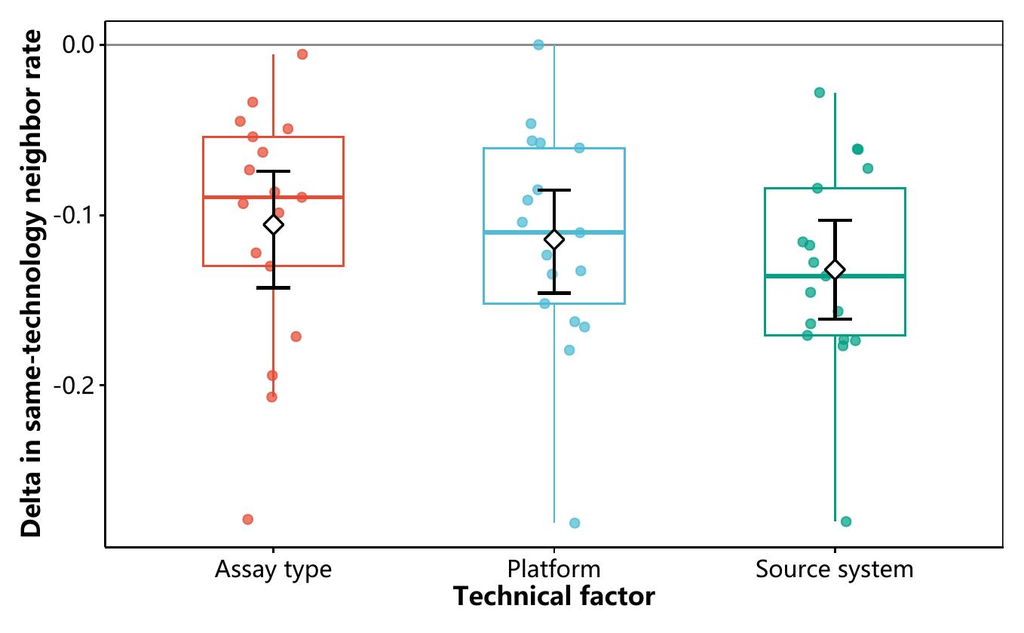

```r
knitr::include_graphics(fig5_jpg)
```

先看零线：彩色点在下方，表示该 cohort 中 d1 的同技术近邻比例平均较低；在上方则较高。再看点的分散程度：箱体和散点描述 cohort 间的差异，**箱体不是总体均值的 95% 区间**。最后看黑色菱形与竖线，它们才是队列等权均值及其 bootstrap 95% 区间。竖线跨零时，该字段的总体方向仍有不确定性；均值为负也不表示每个 cohort 都下降。

本次三个字段的数值为 assay_type: d1−Direct=-0.106, 95% CI [-0.143, -0.074], Holm P=<0.001; platform_id: d1−Direct=-0.114, 95% CI [-0.146, -0.085], Holm P=<0.001; source_system: d1−Direct=-0.132, 95% CI [-0.161, -0.103], Holm P=<0.001。比例差乘以 100 就是百分点，例如 $-0.05$ 是同技术邻居比例低 5 个百分点，不能解释为平台误差或批次效应减少 5%。图测的是邻居名单的标签组成，不直接测量测序误差。

```r
technical_inference_table <- technical_inference[, c(
  "technical_factor", "estimate", "ci_low", "ci_high", "p_value",
  "p_value_adj", "n_cohort", "n_sample", "resamples", "p_resamples",
  "p_method",
  "multiplicity_method", "status"
)]
technical_inference_table$n_query_sample <- technical_query_counts$sample_count[
  match(
    technical_inference_table$technical_factor,
    technical_query_counts$technical_factor
  )
]
technical_inference_table <- technical_inference_table[, c(
  "technical_factor", "estimate", "ci_low", "ci_high", "p_value",
  "p_value_adj", "n_cohort", "n_query_sample", "n_sample", "resamples",
  "p_resamples", "p_method", "multiplicity_method", "status"
)]
render_dt(technical_inference_table, pageLength = 3L)
```

|  | technical_factor | estimate | ci_low | ci_high | p_value | p_value_adj | n_cohort | n_query_sample | n_sample | resamples | p_resamples | p_method | multiplicity_method | status |
| --- | --- | --- | --- | --- | --- | --- | --- | --- | --- | --- | --- | --- | --- | --- |
| 1 | assay_type | -0.1056360729484719 | -0.1428256353785729 | -0.0744053762016621 | 1.52587890625e-05 | 4.57763671875e-05 | 17 | 5705 | 17 | 2000 | 131072 | exact_paired_sign_flip | holm | complete |
| 2 | platform_id | -0.1143431340858778 | -0.1457762296907102 | -0.08547174772575006 | 3.0517578125e-05 | 4.57763671875e-05 | 17 | 5705 | 17 | 2000 | 131072 | exact_paired_sign_flip | holm | complete |
| 3 | source_system | -0.1320639868987742 | -0.1611700576159019 | -0.1029907139634687 | 1.52587890625e-05 | 4.57763671875e-05 | 17 | 5705 | 17 | 2000 | 131072 | exact_paired_sign_flip | holm | complete |

读表时，`n_cohort` 是该字段进入推断的有效外部 cohort 数；当前 helper 的 `n_sample` 也计队列均值这一层的记录，不能当作患者数。`n_query_sample` 汇总的是技术 helper 合并两臂后的 query 记录数；该计数在剔除非有限差值前取得，因此不保证每条记录都贡献了有效技术差。`status` 则帮助识别结果是否可估计，不能把 NA 解读为没有差异。

三个预设字段中，当前绝对点估计最大的是 source_system：d1−Direct 为 -0.132，95% cohort bootstrap 区间为 [-0.161, -0.103]，Holm 校正 P 值为 <0.001，涉及 17 个 cohort。这里的“最大”只描述本次三个点估计的排序，不表示已检验它显著强于另外两个字段，也不意味着其生物影响最大。

### 8.8 与癌种结果合看，当前能得出什么

**本次观察到技术标签聚集与旧癌种恢复同时减弱，需要把两侧的变化一起解释。** 技术侧的三项估计见上图与表；癌种侧，前面的 Top-30 同癌种比例队列等权差为 -0.032，95% 区间为 [-0.077, 0.005]；外部线性 readout 的队列等权 accuracy 差为 -0.076，95% 区间为 [-0.217, 0.047]。这些终点分别使用各自的有效样本和推断口径，并未组成一项新的联合检验；方向还需结合各自区间及校正 P 值阅读。

回到猫狗照片的例子：目前知道“同相机照片少了”，也看到“同类动物更难找回或识别”。可能是来源与癌种捆绑的旧边界被弱化，也可能是有用的癌种信息损失，还可能两种变化同时存在。**本节支持描述邻居与标签关系如何改变，尚不能确定被去掉的恰好是技术噪声，也不能证明发现了更好的跨癌种生物状态。**

下一步最直接的检验，是对每个 query 把**实际近邻候选池也限制为其它 cohort 的同癌种 reference**，在相同候选池与相同 $k$ 下分别给两臂重新排序，再比较同技术比例。这样先固定“都在猫照片中找邻居”，才能减少猫狗比例改变带来的解释歧义；还应检查各平台的样本支持，并做留一平台或留一来源敏感性分析。若同癌种 reference 根本没有多个技术标签，这个对比就缺乏区分技术来源所需的条件，不能靠一个很小的 P 值补足。

即使癌种内负差仍在，也只是更支持技术标签聚集被削弱。要进一步讨论表示的生物价值，还需独立 pathway、微环境或其他预设任务的证据；若要声称有用信息“基本保留”，需先规定科学上可接受的损失界值，再用独立队列验证。**本节的联合评估是把技术诊断与癌种保护性参照并列核对，上述癌种内检索属于后续验证方案，并非本图已经完成的分析。**

### 8.9 为什么值得进入论文

**本节进入论文的核心动机，是回答 CCS 改变样本相似性的依据时，技术来源的影响与已知生物信息分别发生了什么变化。** 对个性化泛癌分类而言，邻居关系能否跨越测量来源、又能否支持有意义的生物比较，直接关系到表示的可信度。仅报告分类分数或几何改变，还不足以回答这个问题。

首先，本节检验跨队列检索中仍可能存在的技术捷径。排除同 cohort 邻居后，样本仍可能因为检测类型、平台或来源系统相同而聚集。上表给出了三个预设技术字段的配对差及区间；其中 source_system 的同技术近邻比例队列等权差为 -13.2 个百分点，95% 区间为 [-16.1, -10.3] 个百分点，Holm 校正 P 值为 <0.001，涉及 17 个有效 cohort。这为“表示变换改变了邻居与技术标签的关系”提供了实证依据；它衡量标签聚集的变化，不能直接换算成测量误差或批次效应消除的程度。

其次，联合报告癌种标签，可以同时审视这种改变的潜在代价。本次 Top-30 同癌种比例的队列等权差为 -3.2 个百分点，95% 区间为 [-7.7, 0.5] 个百分点；外部线性 readout 的 accuracy 差为 -7.6 个百分点，95% 区间为 [-21.7, 4.7] 个百分点。两项癌种终点的点估计均为负，区间均跨零：当前证据不足以确认总体下降，也不足以证明癌种信息已经保留。把这些结果与技术侧一起呈现，才能避免仅凭技术聚集减少就宣布表示更好。

最后，本节明确了后续生物学证据必须解决的歧义。实际检索池包含所有癌种；两臂使用同一 query 的技术标签作为参照，但选中的邻居及其癌种、技术来源组成可能不同，因此同技术比例下降仍可能来自邻居癌种组成改变。对于泛癌分类，跨癌种近邻可以有研究价值，但其价值需要预设生物终点支持。癌种内跨队列检索用于核验技术聚集是否仍减弱，gene signature 评估检查当前表达分数的邻居接近度；这些分数与模型输入同源，且可能携带 batch effect，不能替代独立生物学终点。若要进一步声称有用信息保留，还需预设可接受损失界值并在独立队列中检验。

因此，本节适合作为**表示有效性与信息损失的诊断证据**。与当前结果相符的论文表述是：“d1 降低了跨队列近邻中的技术来源标签聚集；癌种恢复指标的点估计同时下降，提示需要进一步区分技术关联减弱与生物信息损失。”如果论文正文主张 CCS 能形成可迁移的生物表示，可保留一个精简联合面板，把完整队列分布、推断表和指标定义放入补充材料；如果论文主要强调分类性能，本节可作为补充诊断。当前纳入理由是让表示改变的证据与代价可被审查，尚不足以作为“成功去噪且保留生物信息”或“发现更好的跨癌种生物状态”的完成证据。

## 9 原始 d1 模块输出的方差集中度

### 9.1 为什么要检查模块之间的输出波动

**把许多 cohort module 拼成 d1 后，一个自然的问题是：不同患者之间的原始输出变化，是否主要集中在少数模块？** 每个 module 是一个已有的冻结 cohort 模型，对同一个患者输出一组概率；这组输出列称为一个 block。bank 把各模块的 block 拼接起来，形成患者的 d1 表示。模块数量告诉我们接入了多少个模型，却没有说明这些模型在当前样本上是否都产生了变化。

可以把 bank 想成一组评委，每位评委给每位选手打几项分数。有的评委对所有人都打得差不多，有的评委会拉开分数。本节先问“谁的分数更有起伏”，由此检查原始输出的尺度差异。**评委打分起伏大，不代表判断更准确；多位评委都有起伏，也不代表他们提供了不同的意见。** 对应到本分析，输出方差既不能代替外部任务性能，也不能证明模块相互独立。

本节的方差份额有一个明确口径：**模块内平均列方差在全 bank 同类统计量之和中所占的份额**。它衡量原始 d1 输出波动的分布，不是预测准确率、生物信息或最终近邻距离的贡献百分比。标题因此使用“方差集中度”，以免与后文 Figure S3 的目标相关 importance 混淆。

### 9.2 这次实验固定了什么，统计了哪些样本

本节消费已完成的 `native_geometry` 结果，不重新训练模块，也不删减 bank。实验可按以下步骤理解：

1. **固定模型和输出列。** 使用当前冻结 bank 的 150 个 modules，按已登记的 block 边界取出各自的原始 d1 概率列。当前每个 block 包含 3–4 列；列数不同，后面用平均列方差比较。
2. **固定同一批 reference 患者。** reference 库共有 24487 人，本图实际使用其中几何诊断选取的 5000 人。达到几何抽样上限时，代码按 tissue 与 cohort 分组，组内固定种子打乱，再轮流从各组取样。所有模块面对相同患者，不是各自在自己的训练队列里计算方差。
3. **在原始概率上计算。** 先逐列计算这些患者之间的样本方差，再在每个模块内平均，最后换算为全 bank 的份额。这里取的是标准化、block 加权之前的输出。
4. **排序并展示。** 全部模块共同确定份额分母，Figure 6 只显示份额最大的 20 个模块。前十个的合计份额用于描述集中程度；这个展示规则没有筛选显著模块，也没有执行模块删除实验。

这与前一节的外部 query 配对比较不同：**本图的观察单位是固定 reference 患者上的模块输出，图中每根柱子代表一个模块。** 没有 Direct 对照柱，也没有按外部 cohort 等权平均的效应量。抽样有助于覆盖不同 tissue/cohort，但算方差时每个被选中的患者各占一行；结果仍依赖本次 reference 的组成，不能直接推广为所有未来患者上的模块排序。

### 9.3 从一列概率到一个模块：方差怎样算

令 $n$ 为本节实际使用的 reference 患者数，$M$ 为 bank 中模块数，$p_m$ 为模块 $m$ 的输出列数。$x_{imj}$ 表示患者 $i$ 在模块 $m$ 的第 $j$ 列原始概率，先求这列的患者平均值：

$$\bar x_{mj}=\frac{1}{n}\sum_{i=1}^{n}x_{imj}.$$

再看每位患者偏离这个平均值多少，把偏离平方后加起来，除以 $n-1$，得到代码中 `stats::var()` 使用的样本方差：

$$\hat\sigma_{mj}^{2}
=\frac{1}{n-1}\sum_{i=1}^{n}(x_{imj}-\bar x_{mj})^2.$$

平方让正负偏离都算作波动，不会互相抵消；$n-1$ 是样本方差的常规分母。方差越大，表示这一列在这批患者之间变化越大。它不关心这些变化是否与癌种、pathway 或技术来源一致，也没有使用真实标签判断预测对错。

例如，一列概率为 $0.1,0.5,0.9$，均值是 0.5，样本方差为 $(0.4^2+0+0.4^2)/2=0.16$；另一列为 $0.4,0.5,0.6$，均值同样是 0.5，方差只有 $(0.1^2+0+0.1^2)/2=0.01$。均值相同，波动却差了很多。**本节以下手算数字均为教学示例，不是本次分析结果。**

接着，在模块内对各列方差取平均：

$$v_m=\frac{1}{p_m}\sum_{j=1}^{p_m}\hat\sigma_{mj}^{2}.$$

代码把它保存为 `mean_column_variance`。如果一位评委打四项分，另一位打三项分，直接把各项方差相加，会让项目多的一方仅因列数多就占优势；取平均比较的是“每列通常有多大波动”。例如，三个列方差都为 0.04 的模块与四个列方差都为 0.04 的模块，$v_m$ 都是 0.04。

这也解释了一个容易误读的地方：$v_m$ **不是模块所有列方差之和，也不是几列概率相加后再求方差**。后者还会受列间协方差影响。这里逐列计算再平均，既没有统计模块内各列的独立性，也没有统计不同模块之间是否重复。

### 9.4 方差份额与“等份”参照：一步一步换算

模块方差份额（`variance_share`）定义为

$$s_m=\frac{v_m}{\sum_{h=1}^{M}v_h}.$$

分母把所有模块的平均列方差加起来；在总和大于零时，每个 $s_m$ 都在 0 到 1 之间，所有模块的份额合计为 1。图把它乘以 100 显示为百分比。若所有模块都完全没有波动，分母为零，这个份额就不可定义，不能把它解释成每个模块贡献零或自动等份。

下面用三个模块演示换算：

| 教学示例 | 两列的样本方差 | 平均列方差 $v_m$ | 方差份额 $s_m$ |
| --- | --- | --- | --- |
| 模块 A | 0.16、0.04 | 0.10 | $0.10/0.14\approx71.4\%$ |
| 模块 B | 0.01、0.01 | 0.01 | $0.01/0.14\approx7.1\%$ |
| 模块 C | 0.03、0.03 | 0.03 | $0.03/0.14\approx21.4\%$ |

三个 $v_m$ 合计是 0.14，所以 A 占最大份额。这里的 71.4% 只描述平均列方差这个统计量的分配；它不能改写成“A 决定了 71.4% 的分类结果”。份额还是相对量：A 的输出不变，如果 B 和 C 的方差增加，A 的份额也会下降。因此跨不同 bank 或不同样本组成比较份额时，还需核对分母和原始 $v_m$。

若所有模块的平均列方差完全相同，每个模块的份额是 $1/M$。把模块按份额从大到小排列，前 $L$ 个的累计份额为

$$S_L=\sum_{\ell=1}^{L}s_{(\ell)},
\qquad
S_L^{\mathrm{equal}}=\frac{L}{M}.$$

$s_{(\ell)}$ 表示第 $\ell$ 名的份额；本节报告 $L=10$。$L/M$ 是“每个模块恰好等份”的算术参照，**不是随机抽十个模块得到的零假设分布**。因为我们先按大小排序，前十个合计本来就不会低于等份参照；超过它能描述不均匀程度，却不能单凭这一点声称统计显著。也没有一个通用阈值能把“略有不均匀”直接划为“少数模块垄断”。

### 9.5 原始方差较大，为什么不等于最终距离占比大

原始输出尺度不同，会改变未经处理的欧氏距离。正式 d1 检索为此先用**完整 reference** 估计每一列的均值 $\mu_{mj}$ 和标准差 $\sigma_{mj}$，将同一套参数用于 reference 和 query；这套定标不是只在本图的几何子样本上拟合。令

$$z_{imj}=\frac{x_{imj}-\mu_{mj}}{\sigma_{mj}},
\qquad
\tilde z_{imj}=\frac{z_{imj}}{\sqrt{Mp_m}}.$$

第一步把每列换成“偏离 reference 平均水平几个标准差”；第二步给每列乘上 $1/\sqrt{Mp_m}$，平衡模块列数。代码把为零或非有限的标准差设为 1，以保证变换可计算；在 reference 上恒定的列不会因此获得非零波动。

对一个 query $q$ 与一个 reference $r$，最终平方欧氏距离可以拆成

$$D^2(q,r)
=\sum_{m=1}^{M}d_m(q,r),
\qquad
d_m(q,r)=\frac{1}{Mp_m}\sum_{j=1}^{p_m}
(z_{qmj}-z_{rmj})^2.$$

平方后，列权重变成 $1/(Mp_m)$，所以列数多的模块不会仅凭列数多就得到更大的总预算。**模块预算平衡不保证每一对患者的各模块距离贡献都相等。** 具体的 $d_m(q,r)$ 还取决于这两位患者在各模块坐标上差多少；Figure 6 没有计算或展示这个量。

回到前面的三人例子，$0.1,0.5,0.9$ 的标准差是 0.4，$0.4,0.5,0.6$ 的标准差是 0.1。若它们就是拟合定标的 reference，两列标准化后都变成 $-1,0,1$。原始方差分别为 0.16 与 0.01，但标准化后表达相同的患者顺序与相对间隔。这个例子说明，**原始波动差异可以在定标后消失，不能把图上的份额直接搬到最终距离里**。

### 9.6 Figure 6：把公式、柱子和本次结果对应起来

**本次结论是：模块之间的原始输出波动不均匀，但没有集中到一个或前十个模块身上；即使取份额最高的前 20 个模块，它们合计也只有 19.8%，其余 130 个模块仍占 80.2%。** 因此，这张图支持“原始输出的变化分布在许多模块中”，但尚不能据此判断哪些模块对预测或生物学任务最重要。

横轴是 $s_m$，即平均列方差在全部 150 个模块中的份额；纵轴是模块名称，按份额从大到小排列。标签中的 tissue/cohort 标识模块的来源，不表示这根柱子只在该 tissue 的患者上计算。所有柱子都使用前述同一批 reference 患者。柱子越长，表示原始输出在这些患者上的平均列波动越大。

**图上只有前 20 名，分母仍包含整个 bank。** 因此图中柱长不必加起来等于 100%；没有画出的模块仍参与归一化、也仍用于正式 d1 检索。图中没有误差线：当前模块份额只计算了一次，没有针对它们生成 bootstrap 区间或 P 值，不能借用其它几何指标的区间为模块排序背书。

```r
# ==== Figure 6: d1 module variance concentration (user-adjustable parameters) ====
fig6 <- list(
  width_in = 7.2,
  height_in = 5.8,
  base_size = 11,
  bar_width = 0.72,
  legend_position = "none"
)
module_top$module_label <- .ae_resolve_module_labels(
  module_top$module_id,
  data_profile$resolution_audit
)
module_top$module_label <- factor(
  module_top$module_label,
  levels = rev(module_top$module_label)
)
p6 <- ggplot2::ggplot(
  module_top,
  ggplot2::aes(x = .data$variance_share, y = .data$module_label)
) +
  ggplot2::geom_col(
    width = fig6$bar_width,
    fill = nature_colors[["green"]]
  ) +
  ggplot2::scale_x_continuous(labels = scales::label_percent(accuracy = 0.1)) +
  ggplot2::labs(x = "Share of module-level variance", y = "Frozen cohort module") +
  theme_nature_readable(
    base_size = fig6$base_size,
    x_text_angle = 0,
    legend_position = fig6$legend_position
  )

# Readability check: only the top 20 modules are labeled, horizontal bars protect
# tissue|cohort names from clipping, and the vector PDF preserves small text.
fig6_jpg <- .ae_save_plot(
  p6, "02.01.00. module-variance-concentration", figure_dir,
  preview_dir, fig6, params$plot_preview_dpi
)
```

```
## Converting page 1 to D:/cache/ccs/_ablation-03/logs/report-previews/02.01.00-representation-20261008205707/02.01.00. module-variance-concentration.jpg... done!
```

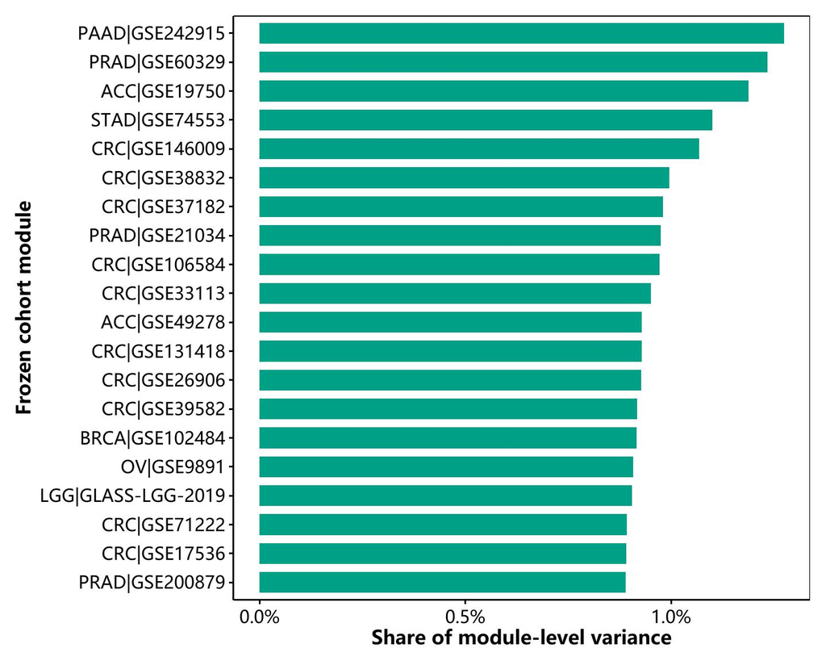

```r
knitr::include_graphics(fig6_jpg)
```

本次份额最高的三个模块如下。平均列方差保留原始概率尺度，份额则是换算后的相对量；两列一起看，能避免只凭百分比猜测原始波动大小。

| 本次模块 | 平均列方差 $v_m$ | 全 bank 方差份额 $s_m$ |
| --- | --- | --- |
| PAAD / GSE242915 | 0.1230 | 1.27% |
| PRAD / GSE60329 | 0.1191 | 1.23% |
| ACC / GSE19750 | 0.1147 | 1.19% |

可以从三个层次判断“集中到什么程度”：

- **单个模块没有占据大部分份额。** 最高的是 PAAD / GSE242915，占 1.27%；如果所有模块的平均列方差相同，每个应占 0.67%。最高模块约为等份参照的 1.91 倍，但它本身仍只占全 bank 的百分之一左右。
- **前十个的份额高于完全均匀分布，但合计仍只占约一成。** 前十个合计为 10.7%，等份参照为 6.7%，约为其 1.61 倍。这说明模块之间确实不均匀；同时，其余 140 个模块仍占 89.3%，所以不能说原始输出波动主要由前十个模块承担。
- **图外模块合计承担了大部分份额。** 图上前 20 个模块合计占 19.8%，其余 130 个未画出的模块合计占 80.2%。也就是说，图中只展示了份额最大的一部分，不能因它们排在前面，就忽略图外模块占据的约八成份额。

这里的“波动”具体指**同一个模块面对不同 reference 患者时，输出概率变化有多大**：对所有患者都给出相近概率的模块，方差较小；患者之间概率差异较大的模块，方差较大。上述百分比是各模块**平均列方差**的份额，不能读成分类准确率的贡献百分比，也不能读成最终近邻距离的贡献百分比。实际检索还使用逐列标准化和 block 权重，高原始方差不会按图中份额直接转化为高距离贡献。

因此，本图可以明确回答的是：**在这批 reference 患者上，原始 d1 输出变化分布在许多模块中，头部模块的份额偏高，但一个或前十个模块并未包揽大部分波动。** 它尚未检验这些变化来自生物差异还是技术差异，也没有检验模块之间是否重复。要判断某个模块是否改善外部任务，需要删除该模块后比较近邻和任务性能；本图没有完成这一实验，也没有给出模块份额的重采样区间，当前结论限于这批样本的描述性结果。

### 9.7 与 Figure S3 的 cohort importance 怎样对应

**此前 Figure S3 中某些 cohort 的 importance 可达 0.1–0.3，而这里同名模块的方差份额约为百分之一；这两项结果可以同时成立。** 关键在于两者问的不是同一个问题：本节问“模块的原始输出波动有多大”，S3 的 cohort 面板问“用 d1 重建 d3 坐标时，辅助模型更多使用哪些 cohort 的输出”。下面只讨论 S3 的 cohort 面板；它的 gene-pair feature 面板还包含另外的权重传播与汇总，不能直接套用 cohort 层的公式。

S3 的计算可沿 `R/importance.R` 中的 `ctImportance()` 与 `mergeImportance()` 核对。先取已保存的 d1 各列作为输入，以一个 d3 坐标的数值作为回归目标，拟合一个辅助 XGBoost 模型；再由 `xgb.importance()` 提取各输入列的归一化 Gain，把同一 cohort 的列相加。这个模型重建的是已有坐标，没有直接用癌种、治疗反应或生存结局作目标。

令 $a$ 表示一个 d3 坐标，$G_{mj}^{(a)}$ 表示辅助树模型中，归给模块 $m$ 第 $j$ 列的未归一化分裂增益之和。Gain 衡量模型沿这列作分裂时获得的目标函数改善；它不是患者人数，也不是这列的样本方差。按 cohort 汇总后的归一化 Gain 可写为

$$I_m^{(a)}=
\frac{\sum_{j=1}^{p_m}G_{mj}^{(a)}}
{\sum_{h=1}^{M}\sum_{j=1}^{p_h}G_{hj}^{(a)}}.$$

这里用一个 cohort 对应一个 module 的记号，与当前核对的 bank 一致。代码实际按 cohort ID 聚合；若其它 bank 中同一 cohort 横跨多个模块，需先统一聚合边界，不能直接比较模块级份额。没有被树模型用于分裂的输入列没有 Gain；本次保存的汇总表将未出现在历史 importance 表中的 cohort 记为零，而不是从图面猜测其数值。

**$I_m^{(a)}=0.30$ 应读作“该坐标重建模型的总分裂 Gain 中，30% 被归给这个 cohort 的输入列”。** 它不能改写成“解释了 d3 方差的 30%”“贡献了 30% 的分类准确率”或“删除这个 cohort 会损失 30% 的性能”。Gain 是特定辅助模型的相对归因，仍取决于拟合设置、输入间相关性和模型如何选择分裂。

S3 的标签还有一个容易混淆的地方：**`allD1`、`allD2` 对应已保存 d3 的第一、第二坐标，原始列名为 `all|D1`、`all|D2`；它们不是未压缩 d1 与中间 d2 两层表示。** `merge` 也不是另一个训练得到的合并表示，而是两个坐标的归一化 Gain 等权平均：

$$I_m^{\mathrm{merge}}=
\frac{I_m^{(\mathrm{allD1})}+I_m^{(\mathrm{allD2})}}{2}.$$

两个坐标各先把全部 Gain 归一化到合计为 1，再各占一半；这既没有按坐标方差加权，也没有按辅助模型的预测精度加权，更没有衡量坐标与临床结局的关系。

| 比较项 | 本节原始方差份额 $s_m$ | S3 cohort Gain $I_m^{(a)}$ |
| --- | --- | --- |
| 输入与目标 | 固定 reference 患者的原始 d1；不使用预测目标 | 历史样本的 d1，目标为一个已保存 d3 坐标 |
| 分子 | 模块内各列样本方差的平均 | 归给该 cohort 各输入列的分裂 Gain 之和 |
| 分母 | 全 bank 模块平均列方差之和 | 该坐标重建模型全部输入列的分裂 Gain |
| 高值说明什么 | 原始输出在这批患者之间变化较大 | 辅助模型把更多相对分裂增益归给该 cohort |
| 不确定性 | 本图没有模块份额区间或 P 值 | 历史结果没有 Gain 重采样区间，不能把排名当作已验证的稳定性 |
| 本次用途 | 诊断原始尺度与波动分布 | 对照说明目标相关归因与输出波动的区别 |

### 9.8 同一 cohort 的两种份额：用实际数值解释

以下历史 Gain 来自论文 `Figures.pptx` 第 15 页 Figure S3 对应的已保存结果，其对象文件为 resCCS_5ff3a2de76e6cf902e765e8224f9cb66.rds。报告消费项目内的 cohort Gain 汇总表 与 来源记录，只导入汇总值，没有复制患者级矩阵，也没有在报告中重新训练模型。来源记录保存原始对象的文件名与内容 MD5，便于核对；本表不是由本次 ablation-03 新生成的 importance 结果。

| 同名 cohort | S3：allD1 Gain | S3：allD2 Gain | S3：merge Gain | 本次原始方差份额 |
| --- | --- | --- | --- | --- |
| GSE19750 | 0.45% | 33.78% | 17.11% | 1.19% |
| GSE49278 | 27.62% | 0.09% | 13.86% | 0.93% |
| GSE60329 | 0.09% | 27.04% | 13.56% | 1.23% |

例如，GSE19750 在第二坐标上的 Gain 为 33.78%，第一坐标只有 0.45%，两者平均后是 17.11%；当前同名模块的原始方差份额为 1.19%。相反，GSE49278 的 Gain 主要来自第一坐标，为 27.62%，第二坐标为 0.09%。GSE60329 则在第二坐标上为 27.04%，第一坐标为 0.09%。这些数值说明历史归因具有坐标特异性；某一轴的 Gain 很小，不等于该模块对整个表示都没有作用。

可以把这个区别继续放回评委例子：大家打分的波动幅度差不多，但最终排名可能更接近其中两位评委的意见。于是，“谁的评分更有起伏”与“谁的评分更能预测最终排名”会得到不同排序。一列概率即使只在 0.49–0.51 之间变化，只要变化与目标坐标高度一致，树模型仍可能使用它；另一列在 0.1–0.9 之间大幅变化，却可能与该坐标无关。这是教学示例，说明**波动幅度与目标相关的预测作用不需要成比例**。

两次 bank 的模块 ID 集合是否一致：是。历史汇总对应 150 个模块、583 个 d1 输出列和 24758 个样本；本次方差诊断使用当前 150 个模块及 5000 个 reference 几何样本。模块 ID 一致仍不保证患者范围、概率数值、定标和目标一致。**本表是不同指标、不同样本范围的解释性对照，不能逐行相减或相除来计算“贡献变化”，也不能把差异归因于单一的模型改动。** 若要研究两种排序的关系，需要先固定同一 bank 和患者范围，再在正式分析设计中同时计算两种指标。

### 9.9 两种诊断怎样共同服务论文

结合本次 Figure 6 与历史 S3，合适的叙述是：“原始 d1 的模块输出方差分布较分散；重建 d3 坐标的辅助模型，其 Gain 则集中于部分 cohort，并具有坐标特异性。”前半句来自原始尺度诊断，后半句来自历史坐标重建模型；它们说明表示的不同侧面，不构成同一个终点的重复验证。最终近邻距离采用标准化与 block 平衡，还需要前面的 $d_m(q,r)$ 拆分；Gain 排名不能直接移作标准化近邻距离的贡献排名。

历史 `merge` Gain 最高的五个 cohort 合计为 66.6%。所以，仅凭 S3 多根柱子非零，还不足以声称“embedding 不受少数 cohort 驱动”；Gain 也不是降维过程本身的载荷或真实因果归因。更准确的图注是：“多个 cohort 的输出参与 d3 坐标重建模型，且不同坐标的相对 Gain 分布不同。”这保留了可观察的结果，也避免把辅助模型归因扩大为降维机制的证明。

两项诊断都不能确定关键 cohort 是否不可替代。若几个模块输出高度相关，辅助树模型可能优先选择其中一个，使它取得高 Gain；删除它后，其它模块可能补上。反过来，原始方差不高的模块也可能提供重要的目标相关信息。**要判断任务价值，仍需固定外部 query、reference 候选池和终点，实施模块删除后的配对评估；要判断归因稳定性，则需对辅助模型做适当的重采样、重拟合并检查坐标重建性能。** 这些验证尚未由本节完成，不能从两个份额百分比推导临床价值、独立生物证据数量或因果贡献。

### 9.10 哪些解释需要后续实验才能区分

模块在混合癌种的 reference 上有较大方差，可能来自癌种之间的均值差异、同癌种内的状态差异，也可能与技术来源或不稳定输出有关。较小方差则可能意味着输出近乎恒定、动态范围较窄，或者当前样本很少触及该模块擅长区分的状态。**接近 0 或 1 的概率本身并不能确定方差高低**：所有人都接近 1 时波动很小，一部分人接近 0、另一部分接近 1 时波动反而可以很大。

| 想进一步回答的问题 | 后续使用什么输入和方法 | 怎样判断得到支持 |
| --- | --- | --- |
| 高份额是否来自样本组成或技术差异？ | 用原始概率及 tissue/cohort/技术元数据，检查逐列分布、近边界比例；在同癌种内复核方差，再比较不同技术分组 | 若高方差主要在癌种间出现，支持组成差异解释；若癌种内仍随技术分组变化，提示技术关联需继续核查，不能直接归因 |
| 份额和排序是否稳定？ | 在固定 bank 上以 reference cohort 为单位重采样，每次重新计算全部 $v_m$、$s_m$ 和前十名名单 | 同时报告前十名累计份额的区间与各模块入选频率；若名单频繁更换，应降低对单个模块排名的强调 |
| 哪些模块实际改变了近邻或外部任务？ | 用同一批合格外部 query，先拆分完整 bank 的 $d_m(q,r)$，再逐个删除冻结模块并按预定距离规则重算；与完整 bank 配对比较近邻名单、癌种检索和预设独立生物终点 | 某模块的距离份额大只说明影响几何；删除后外部终点出现稳定且有科学意义的损失，才支持其在当前 bank 中有任务价值 |
| 模块数多是否意味着证据互补？ | 在同一 reference 上比较标准化模块输出的关联，结合已有同模块预算的 bank scaling；后续删除一组相似模块时，加入同数量随机删除对照 | 高关联且删除组后任务几乎不变，支持冗余解释；超过同数量随机删除的损失更支持该组具有额外任务价值，仍需外部验证 |

这些是后续验证设计，**本图尚未完成上述重采样、距离拆分或删除实验**。逐个删去一个模块所测的是“它在现有其它模块旁边的增量作用”，不等于唯一的贡献分摊：两个模块若提供相似信息，删掉任意一个都可能几乎不降性能，而同时删除会损失信息。后续比较还需保持 query、候选 reference 和预设终点一致，明确删除后的权重规则；若检验许多模块，应预先确定多重比较处理。

### 9.11 这节对论文有什么价值，适合怎样写

本节为“整合多队列模型形成患者表示”的方法主张补上一项可核查的输出诊断：**bank 接入了多少模块，与这些模块在当前患者上怎样变化，是两件需要分别报告的事。** 数学定义说明我们统计的是什么，等份参照说明不均匀的量级，标准化与 block 权重的推导则解释了为什么需要把原始尺度和实际检索几何分开。

与本次证据相符的论文表述可以是：“在固定 reference 几何子样本中，150 个冻结模块的平均列方差份额分布不均，前十个合计占 10.7%，等份参照为 6.7%。由于检索使用 reference 定标与模块宽度平衡，该诊断描述原始输出尺度，模块的外部任务作用需通过独立消融验证。”这样既保留当前发现，也让读者知道指标和方法设计如何对应。

如果正文需要解释 d1 的距离构造，可保留简短定义和集中程度摘要，把完整 Figure 6 及输出分布审计放入补充材料；若论文主张模块重要性或队列证据互补，则应增加外部删除实验与冗余诊断，不能让方差排序承担这些结论。**当前图的论文价值是说明表示由哪些有波动的输出组成、解释尺度平衡的必要性，并为模块审计提供检查顺序；它尚不是关键生物模块、独立证据数量或因果贡献的证明。**

## 10 输入信息压缩与可恢复性

**本次结论是：d1 中仍然保留着一部分原始输入线索，在未参与 decoder 训练的外部样本上也能读回来；但当前结果既不能证明无损压缩，也不能断言读不回来的信息已永久丢失。** 基因对关系的队列等权平衡准确率为 0.786（95% CI [0.774, 0.797]），三类特征的预设重建误差均低于“对所有人只报训练 reference 均值”的基准，说明 d1 中确实存在可利用的输入线索。

恢复不完整的原因尚未分清：可能来自模型重编码，也可能来自只保留 50 个 PCA 坐标、线性读取器能力有限或训练与外部样本的分布差异。因此，本节支持“部分输入信息仍可恢复”；这些信息是否足够支持更好的生物学发现或临床预测，还需由独立任务实验回答。

### 10.1 为什么要从 d1 反过来重建输入

**前面的检索和 readout 问“d1 能完成什么任务”，本节反过来问“d1 还能读回多少原来的输入线索”。** 冻结的 cohort 模型把 Direct 特征变成概率输出，再拼成 d1。即使癌种标签较难读出，也不能直接判定原始特征都已消失；反过来，即使某些输入能重建，也不能保证新的邻居关系或下游任务更好。Decoder 是一个尝试逆向读取的模型，用来把这两件事分开检查。

可以把 Direct 想成一份记录了多项观察的原笔记，d1 是多位评阅者据此写下的评分。现在让另一位读者只看评分，尝试复述原笔记。若他在此前未见的笔记上也能复述部分内容，说明评分里存在可供读取的线索；若复述失败，可能是评分没有保留，也可能是读者采用的规则太简单。**重建成功是可读取性的证据，重建失败需要同时审查表示和 decoder 的能力。**

这里的“压缩”还要区分两个层次。本次 Direct 有 529 列，d1 有 583 列，**d1 的列数反而更多**；从 Direct 到 d1 是任务驱动的重编码，不能称为按列数压缩。Decoder 随后把定标后的 d1 投影到 50 个 PCA 坐标，这一步才明确减少了维数。低维坐标占 d1 列数的 8.6%，只是坐标数量之比，不是“保留了多少信息”的百分比；本实验也没有估计信息熵或互信息。

### 10.2 这次实验怎样训练，怎样在外部样本上验收

本节消费正式 `tradeoffs$decoder` 与 `statistical_inference$decoder` 产物，不在报告中重拟合。实验可以按下面的顺序理解：

1. **固定重建目标。** 目标是冻结 GSClassifier 模型用过的全部 Direct 特征，并非完整转录组。当前包含 496 个 gene-pair、32 个 single-bin 和 1 个 set-pair；三类取值不同，分开评分。
2. **固定训练与验收样本。** 完整 reference/query 分别有 24487／5705 人；decoder 实际使用 10000 个 reference 与 5000 个外部 query。样本超过配置上限时，按 tissue/cohort 分组、固定种子抽样。不是在图中表现较好的患者里挑选验收样本。
3. **只在 reference 学习。** 用训练 reference 的逐列均值和标准差定标 d1，并按 module block 宽度平衡；在这批 reference 上求 PCA 方向，保留 50 维，再用 ridge 回归学习这些坐标到 Direct 的映射。当前惩罚参数为 1，它来自固定配置；本实验未搜索最优 rank 或惩罚强度。
4. **冻结后应用于 query。** query 沿用 reference 的定标参数、PCA 方向、回归系数与 Direct 均值。Query Direct 只作为验收真值，不参与 decoder 拟合；gene-pair 的预测值再截到 $[0,1]$，以 0.5 为二分类阈值，连续目标保留原预测值。
5. **从特征到队列分层汇总。** Figure 7 先在合并 query 上逐特征评分，再对同类特征等权平均；后面的区间和基准检验改为先在每个外部 cohort 内评分，再让 cohort 等权。两种口径分别呈现，不把一个口径的区间套在另一个点估计旁。

这是 **d1 → Direct 的单向重建诊断**，没有 Direct 对照 decoder，也没有重新训练 cohort bank。Reference d1 含 in-sample 生成路径，query d1 来自冻结外部预测；“decoder 没有用 query 拟合”并不消除两侧表示来源的不对称，因此仍保持 descriptive 的证据等级。

### 10.3 数学基础：PCA 留坐标，ridge 学复述规则

令 $X_R\in\mathbb R^{n_R\times p}$、$X_Q\in\mathbb R^{n_Q\times p}$ 为 reference/query 的 Direct 真值，$D_R,D_Q$ 为对应 d1。矩阵每行是一名患者，每列是一项特征或概率输出。先按 reference 定标并平衡模块，得到 $\widetilde D_R,\widetilde D_Q$；属于模块 $m$ 的列 $\ell$ 变为

$$\widetilde D_{i\ell}
=\frac{D_{i\ell}-\mu_{R\ell}}{s_{R\ell}}
\frac{1}{\sqrt{M b_m}}.$$

$\mu_{R\ell}$、$s_{R\ell}$ 是该列的训练 reference 均值和标准差，$M$ 是模块数，$b_m$ 是模块输出列数；标准差为零或不可用时，代码取 $s_{R\ell}=1$。两批患者使用同一套参数。除以标准差调整列的尺度，再乘模块权重，避免列较多的模块仅凭宽度占更大比重。这里不使用 query 的均值或标准差。

PCA（主成分分析）从 $\widetilde D_R$ 找到输出变化较大的正交方向，组成 $V_r$，并计算

$$Z_R=\widetilde D_R V_r,\qquad Z_Q=\widetilde D_Q V_r.$$

$r$ 是保留的坐标数，本次为 50。可以把它理解为从多项评分中抽出少数综合评分；PCA 按 d1 的变化选方向，**并不知道哪些方向最适合恢复 Direct**，也不能保证低方差方向没有重要线索。

再令 $\bar x_R$ 为训练 reference 的逐特征 Direct 均值，$Y_R=X_R-\mathbf1\bar x_R$ 为减去均值的目标。Ridge（岭回归）求系数矩阵 $B$：

$$\widehat B=\arg\min_B
\left\{\|Y_R-Z_RB\|_F^2+\lambda\|B\|_F^2\right\}
=(Z_R^\top Z_R+\lambda I)^{-1}Z_R^\top Y_R,
\qquad
\widehat X_Q=\mathbf1\bar x_R+Z_Q\widehat B.$$

$\|\cdot\|_F^2$ 表示把矩阵里的数逐个平方再相加，$I$ 是单位矩阵，$\lambda$ 控制惩罚强度。第一项让训练重建误差小，第二项限制系数过大，减少依赖偶然波动。预测时先从 query 坐标算出偏离均值的部分，再加回 reference 均值。**这是低秩、带正则化的线性读取器；对 gene-pair 也使用同一回归，随后截断成概率，并非另拟合 logistic 模型。** 实现见 `R/ablation.R` 的 `.ablation_decode_direct_features()`；队列推断见 `targets/statistical_inference.R` 的 `.asi_decoder()`。

### 10.4 三类特征为何需要不同的尺子

| 目标类型 | 当前列数 | 重建时检查什么 | 原尺度指标怎么读 |
| --- | --- | --- | --- |
| Gene-pair | 496 | 冻结输入中的基因对 0/1 关系能否读回 | Balanced accuracy 检查两类召回；Brier 检查概率误差 |
| Single-bin | 32 | 冻结输入中的单项数值编码能否读回 | Spearman 检查患者排序；MAE 检查原特征尺度上的偏差 |
| Set-pair | 1 | 冻结输入中的集合对数值特征能否读回 | Spearman 检查患者排序；RMSE 更强调较大的数值误差 |

特征类型和真值由冻结输入合同确定；这里不把 `single_bin` 的名字当成二分类标签，也不把其误差解释为原始基因表达量误差。下面所有公式先针对**一个特征、同一批验收患者**写出，再按对应口径汇总。

**Gene-pair：方向判对多少，与概率错了多少。** 令真值 $x_i\in\{0,1\}$，截断后的预测概率为 $p_i$，$\widehat x_i=\mathbf1(p_i\ge0.5)$。$n_1,n_0$ 分别为阳性、阴性人数：

$$\mathrm{BA}=\frac12\left[
\frac{\sum_{i:x_i=1}\mathbf1(\widehat x_i=1)}{n_1}
+\frac{\sum_{i:x_i=0}\mathbf1(\widehat x_i=0)}{n_0}
\right],\qquad
\mathrm{Brier}=\frac1n\sum_i(p_i-x_i)^2.$$

Balanced accuracy（BA）让两类各占一半，范围 $[0,1]$，越高越好；两类都存在且预测与真值无关时，其期望为 0.5，不要求两类人数相等。Brier 范围也为 $[0,1]$，但越低越好，同时受概率把握程度影响。**以下均为教学示例，不是本次结果：** 若 10 人中 8 人阳性，全部猜阳性的普通 accuracy 是 0.8，BA 却为 $(1+0)/2=0.5$；对一个阳性样本，概率 0.9 和 0.6 都判对，Brier 分别为 0.01 和 0.16。因此 BA 较高并不等于概率已准确校准。合并 query 的原实现对可用类别召回取平均；cohort 补充推断要求两类都有，缺类时 BA 为 NA，两处边缘处理不能混为一谈。

**连续目标：顺序对了，还要看数值离得多远。** 记预测为 $\widehat x_i$，则

$$\rho_S=\operatorname{cor}\{\operatorname{rank}(x),\operatorname{rank}(\widehat
x)\},
\qquad
\mathrm{MAE}=\frac1n\sum_i|\widehat x_i-x_i|,
\qquad
\mathrm{RMSE}=\sqrt{\frac1n\sum_i(\widehat x_i-x_i)^2}.$$

Spearman 用患者的名次算相关，范围 $[-1,1]$；接近 1 表示顺序相似，接近 0 表示缺少单调排序关系，负值表示排序反向。MAE 是平均绝对误差，RMSE 是均方根误差，均越低越好，单位与各自 Direct 特征相同。教学示例中，真值 $(1,2,3)$、预测 $(11,12,13)$ 的 Spearman 为 1，但 MAE 与 RMSE 都为 10：**完美排序仍可伴随很大的数值偏差。** 先平方再开方使 RMSE 对大误差更敏感；这解释了为什么排序与误差要一起读。常量特征或常量预测不能估计相关，代码保留 NA，汇总只平均有限值。

### 10.5 Figure 7 怎样读

Figure 7 展示合并 query 的重建水平，按三种目标分面。**每个点是同类特征评分的平均，不是一位患者，也不是恢复比例。** 为让向上统一表示重建表现较好，保留 BA 和 Spearman，把三个误差变成

$$1-\mathrm{Brier},\qquad
\frac{1}{1+\mathrm{MAE}},\qquad
\frac{1}{1+\mathrm{RMSE}}.$$

例如教学示例中 MAE 为 1，变换分数便为 0.5；这不意味着恢复了一半输入。连续误差的变换依赖原特征的数值尺度，换单位也会改变分数。**这些变换只统一高低方向，没有统一单位、难度或参考线。** 不跨分面比较哪个点更高，也不把 $1-\mathrm{Brier}$ 读作分类 accuracy。图使用合并 query 的点估计，不附 cohort 等权区间；六项原尺度指标的 cohort 等权区间仍在后表单列。与 reference 均值基准的比较单独呈现在后面的“比只报 reference 平均值多读出了什么”。

```r
# ==== Figure 7: Feature-type reconstruction scores ====
fig7 <- list(
  width_in = 8.2,
  height_in = 4.4,
  base_size = 11,
  point_size = 3.0,
  value_text_size = 3.5,
  legend_position = "none"
)
decoder_plot <- rbind(
  data.frame(
    feature_type = "gene_pair",
    metric = c("Balanced\naccuracy", "1 - Brier\nscore"),
    value = c(
      decoder_summary$balanced_accuracy[decoder_summary$feature_type == "gene_pair"],
      1 - decoder_summary$brier[decoder_summary$feature_type == "gene_pair"]
    )
  ),
  data.frame(
    feature_type = "single_bin",
    metric = c("Spearman", "1 / (1 +\nMAE)"),
    value = c(
      decoder_summary$spearman[decoder_summary$feature_type == "single_bin"],
      1 / (1 + decoder_summary$mae[decoder_summary$feature_type == "single_bin"])
    )
  ),
  data.frame(
    feature_type = "set_pair",
    metric = c("Spearman", "1 / (1 +\nRMSE)"),
    value = c(
      decoder_summary$spearman[decoder_summary$feature_type == "set_pair"],
      1 / (1 + decoder_summary$rmse[decoder_summary$feature_type == "set_pair"])
    )
  )
)
decoder_plot$feature_type <- factor(
  decoder_plot$feature_type,
  levels = c("gene_pair", "single_bin", "set_pair")
)
p7_scores <- ggplot2::ggplot(
  decoder_plot,
  ggplot2::aes(x = .data$metric, y = .data$value, color = .data$metric)
) +
  ggplot2::geom_segment(
    ggplot2::aes(xend = .data$metric, y = 0, yend = .data$value),
    linewidth = 0.7,
    color = "grey75"
  ) +
  ggplot2::geom_point(
    size = fig7$point_size
  ) +
  ggplot2::geom_text(
    ggplot2::aes(label = sprintf("%.3f", .data$value)),
    vjust = -0.8,
    size = fig7$value_text_size,
    color = "black"
  ) +
  ggplot2::facet_wrap(
    ggplot2::vars(.data$feature_type),
    labeller = ggplot2::as_labeller(c(
      gene_pair = "Gene pair",
      single_bin = "Single bin",
      set_pair = "Set pair"
    )),
    scales = "free_x"
  ) +
  ggplot2::scale_color_manual(
    values = unname(nature_colors[seq_len(length(unique(decoder_plot$metric)))]),
    drop = FALSE
  ) +
  ggplot2::scale_y_continuous(limits = c(0, 1.08), breaks = seq(0, 1, 0.2)) +
  ggplot2::labs(
    x = NULL,
    y = "Direction-harmonized score",
    color = "Metric"
  ) +
  theme_nature_readable(
    base_size = fig7$base_size,
    x_text_angle = 0,
    legend_position = fig7$legend_position
  )

fig7_jpg <- .ae_save_plot(
  p7_scores, "02.01.00. feature-type-reconstruction", figure_dir,
  preview_dir, fig7, params$plot_preview_dpi
)
```

```
## Converting page 1 to D:/cache/ccs/_ablation-03/logs/report-previews/02.01.00-representation-20261008205707/02.01.00. feature-type-reconstruction.jpg... done!
```

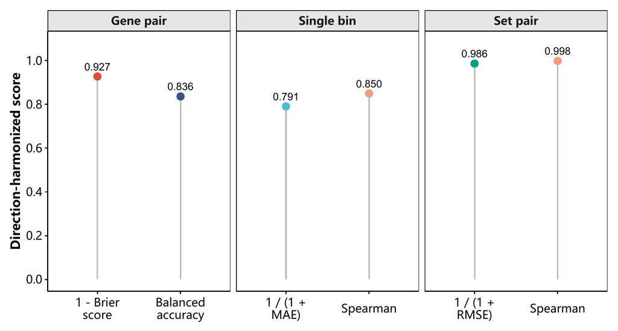

```r
knitr::include_graphics(fig7_jpg)
```

**Gene-pair 的解读：多数二值关系可以通过这条受限路径读回，但没有达到无误恢复。** 合并 query 的平均 BA 为 0.836，Brier 为 0.073，图中后者显示为 0.927。BA 描述逐特征的两类召回平均，不能说“每名患者恢复了 83.6% 的全部输入”。它说明 d1 与原基因对关系仍有可利用的联系；概率误差与 BA 必须分别报告，也不能凭平均值判断哪些具体关系丢失。

**Single-bin 的解读：排序可读回，原数值仍有偏差。** 合并 query 的平均 Spearman 为 0.850，MAE 为 0.265，后者在图上为 0.791。两者共同支持单项编码的患者差异可被部分读取，但 MAE 要在该编码自身尺度上理解。没有预设可接受误差界值，就不能把这一数值直接称为“足够准确”或用于临床阈值判断。

**Set-pair 的解读：当前这一项恢复得很接近，不代表所有集合关系。** Spearman 为 0.998，RMSE 为 0.014，图中误差变换为 0.986。它同时具有接近的排序与较小的本尺度误差，是本次这一特征的积极信号；但当前仅有 1 列，不能把结果推广为广泛通路、微环境或其它集合对特征都已保留。三类特征的数量、尺度和任务难度不同，这里不据点高给它们排“生物信息保留率”。

### 10.6 从合并患者到队列等权：区间围绕哪个结果

令 $s_{cj}$ 是在 cohort $c$ 内对特征 $j$ 算出的 BA、相关或损失，$\mathcal F_{c,t}$ 是类型 $t$ 中该指标可估计的特征集合，$C_t$ 是存在可用均值的 cohort 数。队列等权口径为

$$\bar s_{c,t}=\frac{1}{|\mathcal F_{c,t}|}\sum_{j\in\mathcal
F_{c,t}}s_{cj},
\qquad
\widehat s_t^{\mathrm{cohort}}=\frac{1}{C_t}\sum_{c}\bar s_{c,t}.$$

它先让队列内同类特征等权，再让队列等权。Figure 7 则先合并全部 query，对每个特征评分，再对同类特征平均。大队列在合并评分中提供更多患者，但 BA 与 Spearman 是非线性统计量，合并值不能简化成各队列分数的患者数加权平均。尤其全体患者间的排序可以受到队列间整体水平差异影响；队列内排序是另一种检查。**两种汇总不同，是估计对象不同，不是一个在给另一个纠错。**

下表 `pooled_query_estimate` 对应 Figure 7 的原尺度指标，`cohort_equal_estimate` 是上式。95% 区间按外部 query cohort 整体重采样，使用 2000 次重复，取可用结果的 2.5% 和 97.5% 分位数；BA 缺类、相关无变异时不以零替代，`n_cohort` 与 `valid_resamples` 分别报告可用队列与重复数。区间只围绕队列等权估计，条件是当前 decoder、bank 与 query atlas 冻结；没有重拟合 decoder，因而不包括训练样本、rank、正则化或 bank 变化的不确定性。

```r
render_dt(statistical_inference$decoder$summary, pageLength = 6L)
```

|  | feature_type | metric | pooled_query_estimate | cohort_equal_estimate | ci_low | ci_high | n_cohort | n_sample | resamples | valid_resamples | seed | unit | method | condition | status | reason |
| --- | --- | --- | --- | --- | --- | --- | --- | --- | --- | --- | --- | --- | --- | --- | --- | --- |
| 1 | gene_pair | balanced_accuracy | 0.8362610818946078 | 0.786411280145236 | 0.7742421480635041 | 0.7970256072945787 | 43 | 5000 | 2000 | 2000 | 20260925 | external_query_cohort | cohort_percentile_bootstrap | frozen_decoder_and_query_atlas | estimable |  |
| 2 | gene_pair | brier | 0.07268962867583845 | 0.07267804153507591 | 0.07003500086321196 | 0.07573934487561408 | 43 | 5000 | 2000 | 2000 | 20260925 | external_query_cohort | cohort_percentile_bootstrap | frozen_decoder_and_query_atlas | estimable |  |
| 3 | single_bin | spearman | 0.8497908384213465 | 0.7183636926919499 | 0.6984684206851887 | 0.7369582584048063 | 43 | 5000 | 2000 | 2000 | 20260925 | external_query_cohort | cohort_percentile_bootstrap | frozen_decoder_and_query_atlas | estimable |  |
| 4 | set_pair | spearman | 0.9984071641291569 | 0.9914089931563643 | 0.9877878553337105 | 0.9942105908003372 | 43 | 5000 | 2000 | 2000 | 20260925 | external_query_cohort | cohort_percentile_bootstrap | frozen_decoder_and_query_atlas | estimable |  |
| 5 | single_bin | mae | 0.2647065586078024 | 0.264467990497912 | 0.2562433996668503 | 0.2739166599064479 | 43 | 5000 | 2000 | 2000 | 20260925 | external_query_cohort | cohort_percentile_bootstrap | frozen_decoder_and_query_atlas | estimable |  |
| 6 | set_pair | rmse | 0.01410125792010129 | 0.01298549786542203 | 0.01166670438549801 | 0.01472872977819768 | 43 | 5000 | 2000 | 2000 | 20260925 | external_query_cohort | cohort_percentile_bootstrap | frozen_decoder_and_query_atlas | estimable |  |

队列等权结果中，gene-pair BA 为 0.786（95% CI [0.774, 0.797]），低于合并 query 的 0.836；single-bin Spearman 为 0.718（[0.698, 0.737]），也低于合并值 0.850。这说明只看合并值会漏掉不同队列内的恢复表现；差值本身没有另作显著性检验，不能归因于某一种平台。Set-pair 的队列等权 Spearman 为 0.991（[0.988, 0.994]），当前这一个特征在队列内也保持接近的排序。三项分别基于 43、43、43 个可用 cohort；这些区间尚不是对未来任意队列的保证。

### 10.7 比只报 reference 平均值多读出了什么

Decoder 预测中本来就加回 reference 均值。如果某项特征在大多数患者里几乎相同，即使完全不看 d1、只报这个均值，误差也可能很小。因此，“误差小”需要一个朴素基准才能解释：**同样面对外部 query，不读取患者 d1，只报 decoder 实际训练 reference 子集的逐特征均值；gene-pair 对应 reference 阳性率。** 这不是用 query 均值构造的基准，也不是 Direct 对照模型。

对预先指定的 gene-pair Brier、single-bin MAE、set-pair RMSE，令 $L_{cj}^{(0)}$、$L_{cj}^{(d)}$ 为同一 cohort、同一特征的基准与 decoder 损失，定义

$$\delta_{cj}=L_{cj}^{(0)}-L_{cj}^{(d)},\qquad
\bar\delta_{c,t}=\frac1{|\mathcal F_{c,t}|}\sum_j\delta_{cj},\qquad
\widehat\delta_t=\frac1{C_t}\sum_c\bar\delta_{c,t}.$$

正值表示 decoder 误差较低，零表示两者损失相同，负值表示 decoder 更差。仍先逐特征计算，再在队列内、队列间依次等权；特别是 RMSE，先在**该队列、该特征**的患者平方误差上取平均并开方，再相减，不能称为“每个患者的 RMSE 差”。教学示例中，基准 Brier 为 0.20、decoder 为 0.08，改善就是 0.12 个 Brier 单位，不是 accuracy 提高 12 个百分点。

基准比较图沿用这三项预设损失差，按外部 cohort 等权汇总。虚线零点表示两者误差相同，点在右侧表示 decoder 误差更低，横线是该配对差的 95% cohort bootstrap 区间。三个分面的横轴独立缩放且损失单位不同，应各自对零线判断，不能比较谁的点更靠右就声称谁保留更多信息；图中区间也不能移到 Figure 7 的合并 query 点估计旁解释。

```r
fig7_baseline <- fig7
fig7_baseline$height_in <- 2.4

# Baseline contrasts already come from the formal statistical_inference target.
# Save them independently from Figure 7's pooled-query scores.
decoder_loss_plot <- decoder_baseline
decoder_loss_plot$feature_type <- factor(
  decoder_loss_plot$feature_type,
  levels = c("gene_pair", "single_bin", "set_pair")
)
decoder_loss_plot$estimate <- decoder_loss_plot$estimate_baseline_minus_decoder
decoder_loss_plot$label <- sprintf(
  "%+.3f [%.3f, %.3f]",
  decoder_loss_plot$estimate, decoder_loss_plot$ci_low, decoder_loss_plot$ci_high
)
decoder_loss_span <- pmax(
  abs(decoder_loss_plot$ci_low), abs(decoder_loss_plot$ci_high),
  abs(decoder_loss_plot$estimate)
)
decoder_loss_plot$x_min <- pmin(0, decoder_loss_plot$ci_low) - 0.15 * decoder_loss_span
decoder_loss_plot$x_max <- pmax(0, decoder_loss_plot$ci_high) + 0.15 * decoder_loss_span
decoder_loss_plot$label_x <- (decoder_loss_plot$x_min + decoder_loss_plot$x_max) / 2
p7_baseline <- ggplot2::ggplot(
  decoder_loss_plot,
  ggplot2::aes(x = .data$estimate, y = 1, color = .data$feature_type)
) +
  ggplot2::geom_blank(ggplot2::aes(x = .data$x_min)) +
  ggplot2::geom_blank(ggplot2::aes(x = .data$x_max)) +
  ggplot2::geom_vline(xintercept = 0, linetype = "dashed", color = "grey45") +
  ggplot2::geom_segment(
    ggplot2::aes(x = .data$ci_low, xend = .data$ci_high, yend = 1),
    linewidth = 0.8
  ) +
  ggplot2::geom_segment(
    ggplot2::aes(x = .data$ci_low, xend = .data$ci_low, y = 0.94, yend = 1.06),
    linewidth = 0.6
  ) +
  ggplot2::geom_segment(
    ggplot2::aes(x = .data$ci_high, xend = .data$ci_high, y = 0.94, yend = 1.06),
    linewidth = 0.6
  ) +
  ggplot2::geom_point(size = fig7_baseline$point_size) +
  ggplot2::geom_text(
    ggplot2::aes(x = .data$label_x, y = 1.32, label = .data$label),
    size = fig7_baseline$value_text_size, color = "black"
  ) +
  ggplot2::facet_wrap(
    ggplot2::vars(.data$feature_type), nrow = 1, scales = "free_x",
    labeller = ggplot2::as_labeller(c(
      gene_pair = "Gene pair: Brier", single_bin = "Single bin: MAE",
      set_pair = "Set pair: RMSE"
    ))
  ) +
  ggplot2::scale_color_manual(values = c(
    gene_pair = nature_colors[["red"]], single_bin = nature_colors[["blue"]],
    set_pair = nature_colors[["green"]]
  )) +
  ggplot2::scale_x_continuous(breaks = scales::breaks_pretty(n = 3)) +
  ggplot2::scale_y_continuous(limits = c(0.75, 1.48), breaks = NULL) +
  ggplot2::labs(
    x = "Baseline loss - decoder loss", y = NULL
  ) +
  theme_nature_readable(
    base_size = fig7_baseline$base_size, x_text_angle = 0, legend_position = "none"
  ) +
  ggplot2::theme(
    axis.ticks.y = ggplot2::element_blank()
  )

fig7_baseline_jpg <- .ae_save_plot(
  p7_baseline, "02.01.00. decoder-baseline-comparison", figure_dir,
  preview_dir, fig7_baseline, params$plot_preview_dpi
)
```

```
## Converting page 1 to D:/cache/ccs/_ablation-03/logs/report-previews/02.01.00-representation-20261008205707/02.01.00. decoder-baseline-comparison.jpg... done!
```

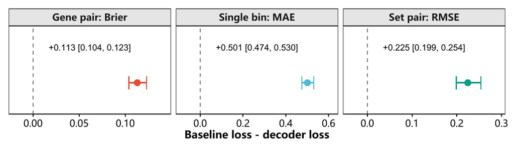

```r
knitr::include_graphics(fig7_baseline_jpg)
```

**基准比较的解读：三个区间都在零线右侧，支持 decoder 比只报训练均值减少误差。** Gene-pair Brier、single-bin MAE、set-pair RMSE 的改善分别为 0.113、0.501、0.225，对应 95% 区间直接标在图中。此图回答相对朴素基准的改善，Figure 7 回答重建水平；两图采用不同汇总口径，不能用此图区间解释 Figure 7 的点。

下表的 95% 区间重采样 cohort 的配对损失差；双侧符号翻转检验检查平均改善相对于零的证据，依赖 cohort 层差值在零假设下可作符号翻转的假定，并非患者级随机对照。当前使用 Monte Carlo 翻转，三项预设损失比较一起做 Holm 校正；BA、Spearman 与图中变换分数不另作事后零值检验。

```r
render_dt(statistical_inference$decoder$baseline_comparisons, pageLength = 3L)
```

|  | feature_type | metric | estimate_baseline_minus_decoder | ci_low | ci_high | p_value | p_method | n_cohort | n_query | resamples | seed | unit | baseline | multiplicity_family | p_value_adj |
| --- | --- | --- | --- | --- | --- | --- | --- | --- | --- | --- | --- | --- | --- | --- | --- |
| 1 | gene_pair | brier | 0.1129772693244202 | 0.1038341886161613 | 0.1230614771632266 | 0.0004997501249375312 | monte_carlo_cohort_sign_flip | 43 | 5000 | 2000 | 20261026 | external_query_cohort | reference_feature_mean_or_prevalence | three_predeclared_decoder_loss_comparisons | 0.001499250374812594 |
| 2 | single_bin | mae | 0.5007520636667369 | 0.4744596243298685 | 0.530391489128336 | 0.0004997501249375312 | monte_carlo_cohort_sign_flip | 43 | 5000 | 2000 | 20261027 | external_query_cohort | reference_feature_mean_or_prevalence | three_predeclared_decoder_loss_comparisons | 0.001499250374812594 |
| 3 | set_pair | rmse | 0.2245157289072417 | 0.1987046137041365 | 0.2537397421331647 | 0.0004997501249375312 | monte_carlo_cohort_sign_flip | 43 | 5000 | 2000 | 20261028 | external_query_cohort | reference_feature_mean_or_prevalence | three_predeclared_decoder_loss_comparisons | 0.001499250374812594 |

结果显示，gene-pair Brier 的基准减 decoder 为 0.113（95% CI [0.104, 0.123]，Holm 校正 P = 0.0015）；single-bin MAE 改善 0.501（[0.474, 0.530]，校正 P = 0.0015）；set-pair RMSE 改善 0.225（[0.199, 0.254]，校正 P = 0.0015）。三项区间均位于零以上，支持当前读取器使用 d1 比仅报训练均值减少了外部重建误差。改善属于三种不同的损失单位，不能据其数值大小决定哪类信息保留最多；对当前均值基准的优势也不能证明胜过所有基准或达到最优恢复。

### 10.8 哪些问题已经回答，哪些还需要专门实验

**当前能回答的是：固定这条读取路径后，d1 中仍有可在外部样本上读回的 Direct 线索，而且恢复优于只报训练均值。** 结果同时包含两个约束：恢复并非全部无误；表现也随合并 query 或队列等权口径而变。误差可能来自模型重编码、PCA 截断、线性函数形式、ridge 惩罚、有限训练量，以及 reference/query 的分布差异。本实验只检验它们叠加后的表现，没有把各部分误差独立拆开。

| 希望进一步判断什么 | 应固定什么、改变什么 | 怎样的结果更支持该判断 |
| --- | --- | --- |
| PCA 或线性读取是否限制了恢复 | 同一冻结 bank、训练 reference 与完全独立验收 query；预先规定 rank/惩罚网格和非线性 decoder，调参只在 reference 内分组验证 | 增加 rank 或换读取器后外部损失下降，说明原误差至少部分来自读取限制；未下降仍不足以证明信息论上的不可逆损失 |
| 恢复的是癌种间差异，还是癌种内患者差异 | 固定癌种，并按完整外部 cohort 留出；同时比较 reference 均值基准和仅用癌种的基准 | 癌种内恢复仍优于这些基准，且跨 cohort 方向稳定，才更支持患者层线索可读取 |
| 能读回的内容是否对科研任务有用 | 在未见 cohort 上预先指定 pathway、微环境或治疗反应终点，并比较 Direct/d1 的实际任务表现 | 重建诊断与独立任务证据共同支持预设目标；若要声称保留，另预设可接受损失界值及非劣效/等价性检验 |

这些是后续实验设计，当前报告没有执行新增 decoder、癌种条件基准或非劣效检验。诊断中的“能恢复”指冻结 Direct 特征可被读取，不能直接扩展成完整转录组、因果机制或临床效用都已保留。

### 10.9 为什么值得写入论文

本节为“多队列重编码”补上一条**从表示回到输入的证据链**。几何指标告诉读者邻居怎样重排，技术来源与癌种联合评估揭示重排的潜在收益和代价；decoder 则说明，任务表现下降并不等于原始线索全都消失。当前 gene-pair 的队列等权 BA 为 0.786，三项预设损失相对均值基准均改善，使“d1 仍可读取部分冻结输入关系”有了外部数值依据。与此同时，本节明确表示列数未减少、读取器受限、set-pair 只有 1 项，避免把它包装成无损压缩或全面生物信息保留。

与本次证据相符的论文表述可以是：“在冻结 bank 条件下，基于 50 维 PCA 与 ridge 的 decoder 可从 d1 重建部分外部 query 的冻结 Direct 特征。Gene-pair 的队列等权 balanced accuracy 为 0.786（95% CI [0.774, 0.797]），三类预设重建损失均低于 reference 均值基准；该诊断描述受限读取器下的可恢复性，未证明无损或不可逆信息损失。”

若论文的主张涉及“输入线索经 cohort 模型重编码后仍可利用”，可在正文保留问题、读取路径、gene-pair 队列结果与基准比较，把完整 Figure 7、三类指标定义和队列推断放入补充材料；若主张集中于分类性能，本节更适合作为补充机制诊断。**它的价值是让重编码保留了什么、读取有什么限制都可被审查；实际生物与分类收益仍由独立任务实验回答。**

## 11 讨论与分析

### 11.1 d1 重排了患者关系，价值取决于保留了什么

这轮消融最清楚的发现，是多队列概率重编码确实改变了患者之间的关系。Direct 用原始 GSClassifier 特征描述患者；d1 则用冻结 cohort modules 的概率输出描述患者，相当于让多个已有队列模型分别给同一个患者作判断，再用这一组判断寻找相似患者。因此 d1 的好坏取决于这些判断是否保留了目标任务需要的差异。

本次 Linear CKA 为 0.721，距离 Spearman 为 0.667，说明两种表示的整体关系仍有相似性；前 30 名邻居的 Jaccard 为 0.335，则说明具体邻居发生重排。这几项衡量的尺度不同：一张地图可以仍把几个城区放在相似位置，却改变每条街上最近的住户。整体相关不能保证局部排序保留，局部重排也不能单独证明新关系更有生物意义。几何区间及留一队列检查只衡量当前冻结表示下的稳定性，不包含重新训练整个 bank 的波动。

### 11.2 旧癌种任务显示了什么代价，尚不能确认什么

在外部检索中，Top-30 同癌种邻居比例的 cohort 等权差为 -3.24 个百分点，95% 区间为 [-7.75, 0.54] 个百分点。外部线性 readout 的 cohort accuracy 差为 -7.57 个百分点，区间为 [-21.67, 4.72] 个百分点，来自 17 个 cohort、5705 个 query。前者问“附近是否仍是同癌种患者”，后者问“统一的线性分类器能否读回旧标签”；它们的负向点估计共同提示旧标签恢复的潜在代价，但当前两项区间均跨零，尚不能确认总体下降。

这里也不能反过来宣布癌种信息无损。区间跨零表示当前精度同时容许若干正向和负向效应；要主张“损失小到可以接受”，必须先规定用途所允许的损失界值，再检查区间。不同队列的正负差还可能互相抵消，所以队列图中的异质性应与总体均值一起读。合并 query 的 balanced accuracy 又按癌种而非队列等权，与主结果回答不同问题，不能挑其中较有利的数值作为最终胜负。

对个性化泛癌分类而言，旧癌种标签是一项重要的保留检查，却还不是新分型的成功判据。若希望 d1 找到跨癌种的共享状态，就必须证明这些新邻居在事先指定的状态或结局上更一致；仅仅让旧标签更难读出，还没有完成这一步。

### 11.3 技术聚集减少，为什么仍需生物侧的证据

本次三个技术字段的同标签近邻差均向下；其中绝对点估计最大的是 source_system，cohort 等权差为 -13.2 个百分点，95% 区间为 [-16.1, -10.3] 个百分点，Holm 校正 P 值为 <0.001。这证明换表示改变了邻居与已记录技术标签的关系，但不能把比例下降换算成“去除了多少批次噪声”。尤其 Platform 字段主要含 `unknow`，其变化实际反映未知标签的聚集变化，不能替代已知平台间的比较。

一个容易误判的情形是：某癌种恰好主要来自某种检测来源。若表示弱化了该癌种的区分，同来源邻居也可能随之减少，即使模型没有把技术噪声与生物信号分开。当前技术侧下降与癌种侧负向点估计因此需要并列报告，它们没有组成新的联合检验，也不能据此确定因果关系。可检验的判断是：固定癌种、补齐技术标签并保持同一候选池后，技术聚集是否仍减少，同时目标生物差异是否仍保留。

gene signature 报告测量的是邻居的连续表达接近度，结构报告测量的是跨队列的高低状态距离排序。两者能检查重排的不同代价：局部表达接近度下降而粗状态地图接近原水平，在逻辑上可以同时发生。但这只与“保留较粗状态、弱化精细排序”的假说相容，目前没有直接分解信息尺度，也没有证明重排后出现了更有用的新亚型。

### 11.4 更多 cohort modules 为什么不等于更多有效信息

Breadth 增加组织背景，depth 在固定的 7 种组织内逐层增加模块；当前 depth 从每组织一个模块增加到 8 个。这类似增加不同专长的观察者与增加同专长的观察者：前者可能补充新的视角，后者可能稳定已有判断，也可能提供相近输出。究竟是哪一种，需看有效秩、冗余和近邻稳定性，而不能只数模块数量。

在同模块预算的 matched-size 比较中，breadth−depth 的归一化有效秩差为 0.001，95% 设计重复区间为 [-0.003, 0.004]；近邻稳定性差为 -0.119，区间为 [-0.130, -0.109]。有效秩描述输出分散在多少相对独立方向上，近邻稳定性则比较子 bank 与完整 bank 的邻居重合。后者较高表示接近完整 bank 的答案，而完整 bank 本身尚未被证明是生物真值。当前只有 5 条冻结设计序列，这些区间不能代表新增患者、新队列或重训模块的全部不确定性。

模块方差集中度回答的又是另一层问题：哪个原始 d1 输出波动较多。它没有直接衡量模块对标准化距离、预测或生物结局的贡献。历史 Figure S3 Gain 与当前方差份额使用不同目标和分母，即使某模块在两张表中都靠前，也不能据此确定应保留或删除它；需在固定模块预算和未见队列任务中实际删除该模块，再观察预设终点怎样变化。

### 11.5 decoder 让“信息丢失”变得更可检验

当前受限 decoder 从 d1 尝试恢复 Direct 特征，gene-pair 的合并 query balanced accuracy 为 0.836；与 reference 均值基准相比，预设 gene-pair 损失的“基准减 decoder”队列等权差为 0.113，95% 区间为 [0.104, 0.123]。这两个量分别回答恢复到了什么水平、是否优于只猜 reference 平均水平，不能互换，也不能把分类分数与其他特征族的相关或误差相加。

恢复出来的信息说明 d1 中仍有可被该 decoder 利用的线索；没有恢复出来的部分则可能来自表示的信息损失，也可能来自 PCA 限制、线性解码能力、训练量或跨队列分布差异。好比摘要能答对部分原文问题，但答错一道题不能证明原文线索完全消失。因此当前结果不足以宣布 d1 无损，也不足以逐项确定哪些原始特征永久丢失。若要区分这些原因，可在 reference 内预先选择解码复杂度和强度，在未见 query 上比较恢复误差及基准差；性能是否随解码能力改善，才是区分“难以读出”与“持续不可恢复”的一条证据。

### 11.6 下一轮怎样判断重编码是否值得

目前较有依据的表述是：多队列概率重编码改变了原始几何和近邻组成，技术标签聚集减少，同时旧癌种恢复存在不确定的负向变化；其独立下游价值仍需验证。reference d1 含 in-sample 生成路径，query d1 来自冻结外部预测，两侧来源不对称，所以本报告维持 descriptive 等级。学习曲线只减少下游 readout 使用的 reference cohorts，没有从零重训 cohort bank，不能据此宣称整个 CCS 框架只需很少训练数据。本次修复了 query 重复标准化、资格范围传递和非配对组成等历史路径，旧 readout、learning curve 与 gene signature 数值不应继续引用。

下一轮应先固定一种与输入测量不同的生物或临床目标，例如独立测量的微环境状态或治疗反应，并将整组未见 cohort 留作验证。在两臂使用同一有效患者、同一调参规则的前提下，预先规定有意义的收益或可接受损失，报告队列等权效应、区间及癌种内结果；跨队列迁移稳定且重要的癌种内差异仍可辨认，才支持这种重编码用于该任务。

另一项验证应专门拆解技术与生物的关联：补齐已知平台标签，在同癌种、同候选池条件下比较技术聚集，并同步检查独立生物目标。若技术侧减少只出现在癌种组成改变时，就应限制“减弱技术影响”的解释；若在这些条件下仍减少且生物目标满足预设判据，才能把技术改善与任务价值联系起来。两条路径都应保留不利结果，最终按具体用途判断取舍。

## 12 数字准确性验证

| 核查 | 当前证据 |
| --- | --- |
| 表示来源 | Direct 采用冻结 GSClassifier 特征；d1 使用 CCS 中已计算的概率矩阵 |
| 预处理 | reference 与 query 以同一种原始表示进入 readout；query 不重复变换 |
| 分析总体 | 癌种可估计 17 队列；全部候选 43 队列；gene signature 有效范围逐项报告 |
| 数字来源 | 正文数值动态来自当前 RDS/CSV；本模块及准备阶段内容指纹在渲染前逐项核验 |
| 统计边界 | 小设计重复、全量训练学习曲线伪重复、临床效用与非劣效判断均单独说明 |

## 13 补充统计推断

作为区间的辅助诊断，这里逐个删除一个 reference cohort，重新计算原标准化尺度上的 CKA、距离 Spearman 与 kNN Jaccard；距离排序使用同一批预先抽取的样本对，删队列时只排除涉及该队列的样本对，以免每行因重新抽样而额外波动。这是**冻结模型和现有 atlas 条件下的留一队列敏感性**。下表每行是一个被删除的 cohort；留一范围本身不是 95% CI。三项指标的 cohort bootstrap 区间见前面的几何推断表，P 值因没有预设零假设仍为 NA。

```r
render_dt(geometry_sensitivity$values, pageLength = 15L)
```

|  | omitted_cohort | n_sample | linear_cka | distance_spearman | knn_jaccard | unit | method | condition |
| --- | --- | --- | --- | --- | --- | --- | --- | --- |
| 1 | ACC/GSE143383 | 4965 | 0.7196170388064835 | 0.665980017939602 | 0.3347883618292864 | reference_cohort_omission | leave_one_cohort_fixed_pairs_sensitivity | frozen_model_and_reference_atlas |
| 2 | ACC/GSE19750 | 4965 | 0.720828297144286 | 0.6660772838094975 | 0.3359365911329963 | reference_cohort_omission | leave_one_cohort_fixed_pairs_sensitivity | frozen_model_and_reference_atlas |
| 3 | ACC/GSE33371 | 4965 | 0.7207561796136646 | 0.6658414686587928 | 0.3361699216610168 | reference_cohort_omission | leave_one_cohort_fixed_pairs_sensitivity | frozen_model_and_reference_atlas |
| 4 | ACC/GSE49278 | 4965 | 0.7215311855487787 | 0.6672028757522566 | 0.3334789331255852 | reference_cohort_omission | leave_one_cohort_fixed_pairs_sensitivity | frozen_model_and_reference_atlas |
| 5 | ACC/GSE75415 | 4977 | 0.7215291740632307 | 0.6676268378712574 | 0.3347518809338146 | reference_cohort_omission | leave_one_cohort_fixed_pairs_sensitivity | frozen_model_and_reference_atlas |
| 6 | ACC/GSE76019 | 4966 | 0.7201778352530206 | 0.6659612674744908 | 0.3352901226898036 | reference_cohort_omission | leave_one_cohort_fixed_pairs_sensitivity | frozen_model_and_reference_atlas |
| 7 | ACC/GSE76021 | 4971 | 0.7215692369163328 | 0.6678875473730683 | 0.3346277546162146 | reference_cohort_omission | leave_one_cohort_fixed_pairs_sensitivity | frozen_model_and_reference_atlas |
| 8 | ACC/GSE90713 | 4966 | 0.7193141204114993 | 0.6666046020727481 | 0.334634581370452 | reference_cohort_omission | leave_one_cohort_fixed_pairs_sensitivity | frozen_model_and_reference_atlas |
| 9 | BLCA/Cornell-NatCom-2019 | 4968 | 0.720445245407604 | 0.6662119137856077 | 0.3356939595956152 | reference_cohort_omission | leave_one_cohort_fixed_pairs_sensitivity | frozen_model_and_reference_atlas |
| 10 | BLCA/MSK-BLCA-2013 | 4966 | 0.7218454304521328 | 0.6678637937644243 | 0.3354964081642915 | reference_cohort_omission | leave_one_cohort_fixed_pairs_sensitivity | frozen_model_and_reference_atlas |

[output cut: 90 more lines]

受限 decoder 的 cohort 等权区间及三项预设基准损失比较已在“输入信息压缩与可恢复性”中与 Figure 7 联合呈现；两张表仍消费同一正式统计产物，此处不重复展示。

下面的区间只描述**同一外部 cohort 内的 query 波动**。检索使用配对 Top-30 同癌种邻居比例差，readout 使用同一 query 的配对 accuracy 差；均在 cohort 内重采样 query，且至少需要 20 个可用 query。它们不估计更换 cohort 时的稳定性，也不对事后挑出的最大或最小格子给 P 值。

```r
render_dt(rbind(statistical_inference$retrieval_local,
  statistical_inference$readout_local), pageLength = 20L)
```

|  | endpoint | cohort | estimate | ci_low | ci_high | n_query | resamples | valid_resamples | seed | unit | method | status | reason |
| --- | --- | --- | --- | --- | --- | --- | --- | --- | --- | --- | --- | --- | --- |
| 1 | retrieval_top30_d1_minus_direct | CPTAC-BRCA-2020 | 0.01693989071038252 | -0.007103825136612023 | 0.04480874316939891 | 122 | 2000 | 2000 | 20260925 | query_within_cohort | within_cohort_query_percentile_bootstrap | estimable |  |
| 2 | retrieval_top30_d1_minus_direct | CPTAC-LUAD-2020 | 0.006969696969696969 | 0.002727272727272727 | 0.01303030303030303 | 110 | 2000 | 2000 | 20260926 | query_within_cohort | within_cohort_query_percentile_bootstrap | estimable |  |
| 3 | retrieval_top30_d1_minus_direct | CPTAC-PAAD-2021 | -0.3078571428571429 | -0.3497619047619048 | -0.2683333333333333 | 140 | 2000 | 2000 | 20260927 | query_within_cohort | within_cohort_query_percentile_bootstrap | estimable |  |
| 4 | retrieval_top30_d1_minus_direct | GSE21983 | -0.07222222222222223 | -0.1157523148148148 | -0.02451388888888902 | 72 | 2000 | 2000 | 20260928 | query_within_cohort | within_cohort_query_percentile_bootstrap | estimable |  |
| 5 | retrieval_top30_d1_minus_direct | TCGATARGET-ACC | 0.1393939393939394 | 0.09740259740259741 | 0.1852813852813853 | 77 | 2000 | 2000 | 20260929 | query_within_cohort | within_cohort_query_percentile_bootstrap | estimable |  |
| 6 | retrieval_top30_d1_minus_direct | TCGATARGET-BLCA | -0.05389025389025389 | -0.0628992628992629 | -0.04496109746109747 | 407 | 2000 | 2000 | 20260930 | query_within_cohort | within_cohort_query_percentile_bootstrap | estimable |  |
| 7 | retrieval_top30_d1_minus_direct | TCGATARGET-BRCA | -0.0706581352833638 | -0.07931215722120658 | -0.06200487507617306 | 1094 | 2000 | 2000 | 20260931 | query_within_cohort | within_cohort_query_percentile_bootstrap | estimable |  |
| 8 | retrieval_top30_d1_minus_direct | TCGATARGET-COAD | 0.01206896551724138 | -0.005632183908045976 | 0.03045977011494253 | 290 | 2000 | 2000 | 20260932 | query_within_cohort | within_cohort_query_percentile_bootstrap | estimable |  |
| 9 | retrieval_top30_d1_minus_direct | TCGATARGET-ESCA | 0.004945054945054945 | 0.001098901098901099 | 0.009157509157509158 | 182 | 2000 | 2000 | 20260933 | query_within_cohort | within_cohort_query_percentile_bootstrap | estimable |  |
| 10 | retrieval_top30_d1_minus_direct | TCGATARGET-KIRC | -0.09462659380692168 | -0.1050113843351548 | -0.08442395264116578 | 732 | 2000 | 2000 | 20260934 | query_within_cohort | within_cohort_query_percentile_bootstrap | estimable |  |

[output cut: 24 more lines]

100% 学习曲线只固定一个独立训练 cohort 组合。下表选用原合同的第 1 次拟合种子，先对照重算两臂的调参选择、accuracy、balanced accuracy 与 macro AUROC，全部一致后才对相同 query 的 accuracy 差按外部 cohort 重采样。新增区间只回答**固定训练设计和拟合种子，变化外部 query cohort**时的条件敏感性；原设计层 CI 与 P 值继续为 NA。其余重复种子不是新的训练 cohort 设计。

```r
render_dt(learning_query_inference$summary, pageLength = 1L)
```

|  | requested_fraction | repeat_id | training_seed | bootstrap_seed | estimate | ci_low | ci_high | n_cohort | n_query | resamples | valid_resamples | unit | method | condition | design_level_ci | design_level_p_value | score_recalculation |
| --- | --- | --- | --- | --- | --- | --- | --- | --- | --- | --- | --- | --- | --- | --- | --- | --- | --- |
| 1 | 1 | 1 | 20294806 | 20260926 | -0.07566435128596981 | -0.2180068135311 | 0.03898342959110316 | 17 | 5705 | 2000 | 2000 | external_query_cohort | cohort_percentile_bootstrap | fixed_100_percent_training_design_and_seed |  |  | matched_archived_100_percent_arm |